# GlcNac time course data analysis

Francesco Tabaro

2024-10-09

Right-click a figure and select “open in new tab” to get a larger view.

```r
library(tidyverse)
library(DESeq2)
library(patchwork)
library(ComplexUpset)
library(clusterProfiler)
library(enrichplot)
library(org.Mm.eg.db)
library(DT)
library(dendextend)
library(distances)
library(pheatmap)
library(mclust)
library(RColorBrewer)
```

```r
get_counts <- function(file_path, normalized) {
  dds <- readRDS(file_path)
  mat <- counts(dds, normalized = normalized)
  as_tibble(mat, rownames = "gene_id")
}

get_results_table <- function(file_path){
  tp <- basename(dirname(file_path))

  read_csv(file_path) %>%
    dplyr::select(-1) %>%
    dplyr::mutate(time_point = tp)
  }

to_matrix <- function(df) {
  rn <- df$gene_id
  mat <- as.matrix(df[,-1])
  rownames(mat) <- rn
  mat
}

get_all_counts <- function(normalized = FALSE) list.files(
  "3t-seq/data/results/analysis/rdata/deseq2",
  pattern = "dds.rds",
  full.names = TRUE,
  recursive = TRUE) %>%
  purrr::map(get_counts, normalized = normalized) %>%
  purrr::reduce(dplyr::full_join, by = "gene_id") %>%
  dplyr::select(-c(grep(".x.x.*", colnames(.)), grep(".y.*", colnames(.)))) %>%
  dplyr::rename_with(sub, pattern = ".x", replacement = "") %>%
  to_matrix

# m is a matrix with one row per gene and one column per sample.
mor <- function (m, threshold = 50,
                 add_one = TRUE,
                 return_coefficients = FALSE,
                 use_median = FALSE,
                 do_rounding = TRUE,
                 digits = 5
                ) {

  if(any(m<0, na.rm = TRUE)) stop("Negative counts detected. Aborting.", call. = FALSE)

  ## shift all cells by 1.
  if(add_one) {
    cat("Adding 1 to all cells. Turn off with add_one=FALSE.\n", file = stderr())
    m <- m + 1
  }

  ## build consensus sample
  if(use_median){
    consensus <- apply(m, 1, median, na.rm = TRUE)
  }else{
    consensus <- exp(rowMeans(log(m), na.rm = TRUE)) # geometric mean
  }

  ## compute median-of-ratios
  keep <- consensus > threshold
  mors <- apply(m, 2, function (sample) { median(sample[keep] / consensus[keep], na.rm = TRUE) })

  ## normalize input
  norm <- sapply(1:ncol(m), function (i) { m[,i] / mors[i] })

  ## round
  if (do_rounding) {
    norm <- round(norm, digits = digits)
    if(return_coefficients) mors <- round(mors, digits = digits)
  }

  ## keep colnames and rownames
  colnames(norm) <- colnames(m)
  rownames(norm) <- rownames(m)

  if(return_coefficients){
    return(list(medians = consensus,
                coeff = mors,
                norm = norm))
  }else{
    return(norm)
  }
}

create_dt <- function(x){
  require(DT)

  page_len <- 10
  if (nrow(x) < 10) {
    page_len <- nrow(x)
    length_menu <- "All"
  } else if (nrow(x) >= 10 & nrow(x) < 25) {
    length_menu <- c(10)
  } else if (nrow(x) >= 25 & nrow(x) < 50) {
    length_menu <- c(10, 25)
  } else if (nrow(x) >= 50) {
    length_menu <- c(10, 25, 50)
  }

  dt_options <- list(pageLength = page_len)

  if (!is.null(length_menu)) {
    dt_options[["lengthMenu"]] <- length_menu
    dt_options[["dom"]] <- "'Blfrtip'"
  } else {
    dt_options[["dom"]] <- "'Bfrtip'"
  }

  dt_options[["pageLength"]] <- page_len

  datatable(as.data.frame(x),
            rownames = FALSE,
            extensions = list(),
            options = dt_options)
}

create_go_dt <- function(x) {
    if (nrow(x) > 0){
      if ("Cluster" %in% colnames(x)) {
        x <- x[,-which(colnames(x) == "Cluster")]
      }

      ret <- x %>%
        as.data.frame %>%
        dplyr::select(-c(ID, pvalue, qvalue)) %>%
        dplyr::arrange(p.adjust) %>%
        dplyr::mutate(p.adjust = format(p.adjust,
                                        scientific = TRUE,
                                        digits = 2)) %>%
        dplyr::rename_with(tolower) %>%
        dplyr::rename(`Adjusted p-value` = p.adjust) %>%
        dplyr::rename_with(Hmisc::capitalize) %>%
        create_dt()
      return(ret)
    } else {
      warning("No GO terms enriched")
    }
}

tpm <- function(dds) {
  counts <- counts(dds, normalize = FALSE)
  lengths <- width(rowRanges(dds))
  rpk <- counts / (lengths / 1000)
  scaling_factor <- colSums(rpk) / 1e6
  tpm <- t(t(rpk) / scaling_factor)
  return(tpm)
}

get_tpm <- function(p) {
  dds <- readRDS(p)
  tpm_matrix <- tpm(dds)
  as_tibble(tpm_matrix, rownames = "gene_id")
}

get_all_tpm <- function() list.files(
  "3t-seq/data/results/analysis/rdata/deseq2",
  pattern = "dds.rds",
  full.names = TRUE,
  recursive = TRUE) %>%
  purrr::map(get_tpm) %>%
  purrr::reduce(dplyr::full_join, by = "gene_id") %>%
  dplyr::select(-c(grep(".x.x.*", colnames(.)), grep(".y.*", colnames(.)))) %>%
  dplyr::rename_with(sub, pattern = ".x", replacement = "") %>%
  to_matrix

overlapGroups <- function (listInput, sort = TRUE) {
  # listInput could look like this:
  # $one
  # [1] "a" "b" "c" "e" "g" "h" "k" "l" "m"
  # $two
  # [1] "a" "b" "d" "e" "j"
  # $three
  # [1] "a" "e" "f" "g" "h" "i" "j" "l" "m"
  listInputmat    <- UpSetR::fromList(listInput) == 1
  #     one   two three
  # a  TRUE  TRUE  TRUE
  # b  TRUE  TRUE FALSE
  #...
  # condensing matrix to unique combinations elements
  listInputunique <- unique(listInputmat)
  grouplist <- list()
  # going through all unique combinations and collect elements for each in a list
  for (i in 1:nrow(listInputunique)) {
    currentRow <- listInputunique[i,]
    myelements <- which(apply(listInputmat,1,function(x) all(x == currentRow)))
    attr(myelements, "groups") <- currentRow
    grouplist[[paste(colnames(listInputunique)[currentRow], collapse = ":")]] <- myelements
    myelements
    # attr(,"groups")
    #   one   two three
    # FALSE FALSE  TRUE
    #  f  i
    # 12 13
  }
  if (sort) {
    grouplist <- grouplist[order(sapply(grouplist, function(x) length(x)), decreasing = TRUE)]
  }
  attr(grouplist, "elements") <- unique(unlist(listInput))
  return(grouplist)
  # save element list to facilitate access using an index in case rownames are not named
}
```

We will begin by importing data and performing median of ratios normalization of the count matrix. The table below shows the initial number of genes and samples.

```r
all_counts <- get_all_counts(normalized = FALSE)
all_counts <- all_counts[apply(all_counts, 1, function(x) all(is.finite(x))),]
all_counts_mor <- mor(all_counts, return_coefficients = FALSE, do_rounding = FALSE)
all_tpm <- get_all_tpm()

data.frame(row.names = c("genes", "samples"), values = dim(all_counts))
```

|  | values |
| --- | --- |
| genes | 19662 |
| samples | 30 |

We will also import all DESeq2 results table as computed from 3t-seq.

```r
all_deseq2_results_tables <- list.files(
  "3t-seq/data/results/analysis/tables/deseq2",
  pattern = "results.shrink.csv",
  full.names = TRUE,
  recursive = TRUE) %>%
  purrr::map(get_results_table) %>%
  purrr::reduce(bind_rows) %>%
  dplyr::mutate(time_point = factor(time_point,
                                    levels = c("0_30", "0_2",
                                               "0_4", "0_8",
                                               "0_24", "0_48",
                                               "0_7D", "0_WT",
                                               "WT_WT7D")),
                log2FoldChange = ifelse(time_point == "0_WT", -log2FoldChange, log2FoldChange))

as.data.frame(all_deseq2_results_tables)
```

| gene_name | gene_id | baseMean | log2FoldChange | lfcSE | pvalue | padj | time_point |
| --- | --- | --- | --- | --- | --- | --- | --- |
| Cfl1 | MGI:101757 | 2.252910e+04 | 2.045278e-01 | 0.03543215 | 2.332681e-09 | 1.065714e-07 | 0_2 |
| Syt4 | MGI:101759 | 7.100507e+00 | -1.438364e-02 | 0.12979344 | 4.605303e-01 | NA | 0_2 |
| Sfswap | MGI:101760 | 2.805185e+03 | 9.607238e-02 | 0.05720592 | 6.136810e-02 | 1.796037e-01 | 0_2 |
| Hmga2 | MGI:101761 | 3.737721e+02 | 3.975459e-02 | 0.09247864 | 5.502113e-01 | 7.333014e-01 | 0_2 |
| Elk3 | MGI:101762 | 2.194463e+02 | -4.262454e-01 | 0.16668922 | 7.110520e-04 | 5.797853e-03 | 0_2 |
| Cfl2 | MGI:101763 | 1.173992e+03 | 6.956143e-02 | 0.06639667 | 2.248247e-01 | 4.287823e-01 | 0_2 |
| Cdk5r1 | MGI:101764 | 3.618187e+01 | 1.268882e-02 | 0.12498977 | 7.335317e-01 | 8.573176e-01 | 0_2 |
| Cdk5 | MGI:101765 | 9.136358e+02 | 5.883111e-02 | 0.07147423 | 3.145466e-01 | 5.263423e-01 | 0_2 |
| Ryk | MGI:101766 | 2.081499e+03 | 1.044774e-03 | 0.05431554 | 9.836869e-01 | 9.916959e-01 | 0_2 |
| Mcl1 | MGI:101769 | 1.277411e+04 | 1.115944e-01 | 0.03660614 | 1.444244e-03 | 1.022703e-02 | 0_2 |

[output cut: 9990 more lines]

# Combine pairwise results

We will produce a compound plot merging all Volcano and MA plots for pairwise analysis performed by 3t-seq.

We begin by setting log2 fold-change and adjusted p-values threshold to call differentially expressed genes (DEG).

|  | values |
| --- | --- |
| log2FoldChange threshold | 0.00 |
| Adjusted p-value threshold | 0.01 |

With these thresholds we proceed to call differentially expressed genes (DEG) in each time point. We produce a heatmap to summarize gene expression changes across all time points.

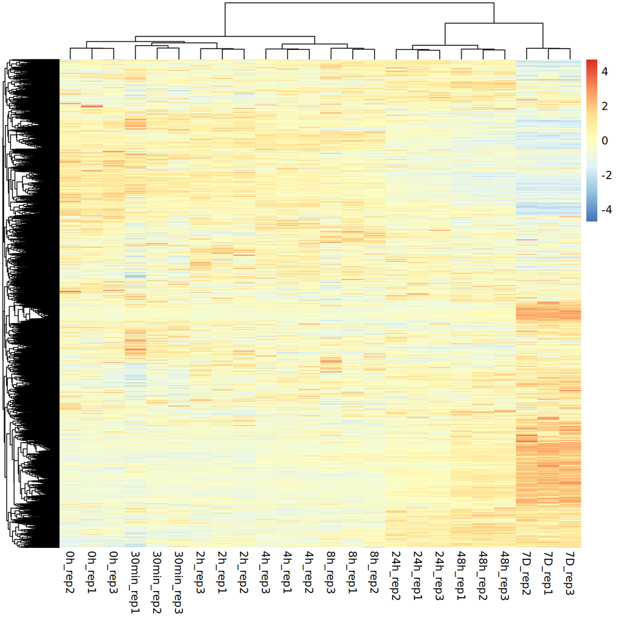

```r
all_deg <- all_deseq2_results_tables %>%
  dplyr::mutate(deg = abs(log2FoldChange) > lfc_thr
                & ifelse(is.na(padj), pvalue < pval_thr, padj < pval_thr),
                direction = sign(log2FoldChange))

deg_mat <- all_counts_mor[rownames(all_counts_mor) %in% (all_deg %>%
                            dplyr::pull(gene_id) %>%
                            unique()),
                          !grepl("WT", colnames(all_counts_mor))]

colorder <- rep(c("0h", "30min", "2h", "4h", "8h", "24h", "48h", "7D"), each = 3)
replicates <- paste0(rep("rep", 3), 1:3)
labs <- expand.grid(colorder, replicates)
labs <- paste(labs$Var1, labs$Var2, sep="_")

hcc <- hclust(
  distances::distance_matrix(
    distances::distances(
      scale(t(deg_mat),
            center = rowMeans(deg_mat),
            scale = rowSds(deg_mat)),
      id_variable = colnames(deg_mat)
    )),
  method = "ward.D")
hcc <- dendextend::rotate(hcc, order = labs)

pheatmap::pheatmap(deg_mat,
                   scale = "row",
                   cluster_cols = hcc,
                   show_rownames = FALSE)
```

## Volcanos and MA plots

We produce a side-by-side visualization of gene expression through Volcano plot and MA plots.

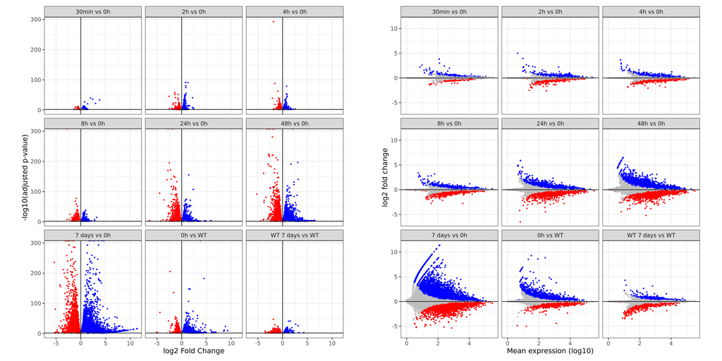

```r
pick_color <- function (deg_status, direction) {
  if (length(deg_status) != length(direction)){
    stop("Input vectors must have the same length.")
  }
  color <- rep("grey", length(deg_status))
  color[deg_status & direction == 1] <- "blue"
  color[deg_status & direction == -1] <- "red"
  return(color)
}

labels <- c(`0_30` = "30min vs 0h",
            `0_2` = "2h vs 0h",
            `0_4` = "4h vs 0h",
            `0_8` = "8h vs 0h",
            `0_24` = "24h vs 0h",
            `0_48` = "48h vs 0h",
            `0_7D` = "7 days vs 0h",
            `0_WT` = "0h vs WT",
            `WT_WT7D` = "WT 7 days vs WT")

volcano <- all_deg %>%
  mutate(color = pick_color(deg, direction)) %>%
  ggplot(aes(
    x = log2FoldChange,
    y = -log10(padj),
    color = color)
    ) +
  geom_point(size = .75) +
  geom_hline(
    yintercept = -log10(pval_thr),
    color = "black") +
  geom_vline(
    xintercept = c(-lfc_thr, lfc_thr),
    color = "black") +
  scale_color_identity() +
  xlab("log2 Fold Change") +
  ylab("-log10(adjusted p-value)") +
  facet_wrap(facets = vars(time_point), ncol = 3,
             labeller = labeller(time_point = labels)) +
  theme_bw(base_size = 14) +
  theme(aspect.ratio = 1)

ma_plot <- all_deg %>%
  mutate(color = pick_color(deg, direction)) %>%
  ggplot(aes(x = log10(baseMean), y = log2FoldChange, color = color)) +
  geom_point(size = .75) +
  geom_hline(
    yintercept = c(-lfc_thr, lfc_thr),
    color = "black") +
  scale_color_identity() +
  xlab("Mean expression (log10)") +
  ylab("log2 fold change") +
  facet_wrap(facets = vars(time_point), ncol = 3,
             labeller = labeller(time_point = labels)) +
  theme_bw(base_size = 14) +
  theme(aspect.ratio = 1)

p <- volcano + ma_plot

ggsave(filename = "figures/seq_merge_volcano_ma_plot.pdf",
       plot = p,
       width = 20,
       height = 10)

p
```

## Plot number of DEG across time points

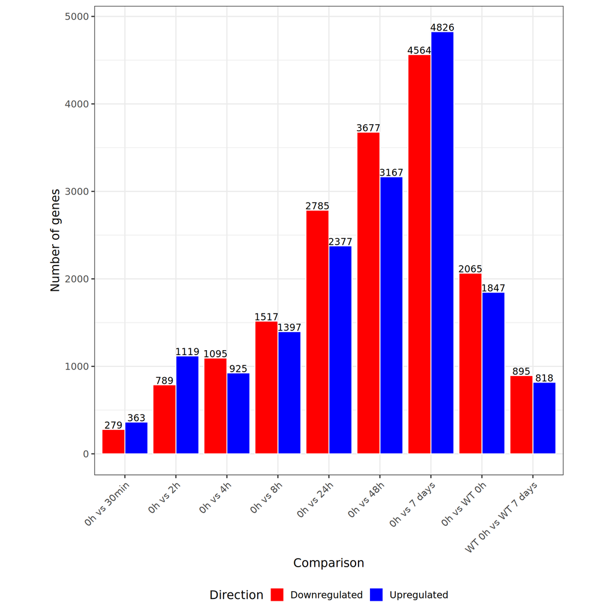

```r
p <- all_deg %>%
  dplyr::group_by(time_point) %>%
  dplyr::summarize(
    upregulated = sum(deg & direction == 1, na.rm=TRUE),
    downregulated = sum(deg & direction == -1, na.rm = TRUE)
  ) %>%
  tidyr::pivot_longer(cols = c(upregulated, downregulated)) %>%
  ggplot2::ggplot(aes(x = time_point,
                      y = value,
                      fill = name,
                      label = value)) +
  ggplot2::geom_bar(stat = "identity",
                    position = "dodge",
                    color = "white") +
  ggplot2::geom_text(mapping = aes(y = value + 50),
                     position = position_dodge(width = 0.9)) +
  ggplot2::scale_x_discrete(labels = c(
    `0_30` = "0h vs 30min",
    `0_2` = "0h vs 2h",
    `0_4` = "0h vs 4h",
    `0_8` = "0h vs 8h",
    `0_24` = "0h vs 24h",
    `0_48` = "0h vs 48h",
    `0_7D` = "0h vs 7 days",
    `0_WT` = "0h vs WT 0h",
    `WT_WT7D` = "WT 0h vs WT 7 days")) +
  ggplot2::scale_fill_manual(name = "Direction",
                             labels = Hmisc::capitalize,
                             values = c(downregulated = "red",
                                        upregulated = "blue")) +
  ggplot2::xlab("Comparison") +
  ggplot2::ylab("Number of genes") +
  ggplot2::theme_bw(base_size = 14) +
  ggplot2::theme(aspect.ratio = 1,
                 axis.text.x = element_text(angle = 45, hjust = 1),
                 legend.position = "bottom")

ggsave(filename = "figures/number_of_deg_per_comparison.pdf",
       plot = p,
       width = 8,
       height = 8)

p
```

## Compute DEG shared across time points

```r
my_theme <- upset_modify_themes(
  list(
    'default' = theme(
      text = element_text(size = 16),
      axis.text.x = element_text(size = 16)),
    'intersections_matrix' = theme(
      text = element_text(size = 16)
    ),
    'Intersection size' = theme(
      text = element_text(size = 16)
    ),
    'overall_sizes' = theme(
      text = element_text(size = 16),
      axis.text.x = element_text(angle = 45, hjust = 1)
    )
  ))

my_intersection_matrix <- intersection_matrix(
            geom = geom_point(shape = 19, size = 2.5),
            segment = geom_segment(
              linetype = 'dotted', size = 0.25, color = "black"),
            outline_color = list(active = 'black', inactive = 'grey90'))
```

To inspect how DEG are shared among time points and controls we will produce a [UpSet plot](https://en.wikipedia.org/wiki/UpSet_plot).

We will produce two separate visualizations, one for upregulated, the other for downregulated genes.

We will remove `0_7D` contrast as it generates a lot of noise and is not relevant.

```r
dat <- all_deg %>%
  dplyr::filter(deg
                & ! time_point == "0_7D") %>%
  dplyr::mutate(direction = sign(log2FoldChange)) %>%
  dplyr::select(gene_id, direction, time_point) %>%
  dplyr::group_by(direction)

keys <- dat %>%
  dplyr::group_data() %>%
  dplyr::pull(direction)

venn.data <- dat %>%
  dplyr::group_by(direction) %>%
  dplyr::group_split() %>%
  purrr::set_names(keys)

vd_complexUpset <- venn.data %>%
  purrr::map(~.x %>%
               dplyr::select(-direction) %>%
               dplyr::mutate(val = TRUE) %>%
               tidyr::pivot_wider(
                 id_cols = gene_id,
                 names_from = time_point,
                 values_from = val,
                 values_fill = FALSE))
```

### Upregulated

We will produce a UpSet plot showing all intersections with at least 5 elements.

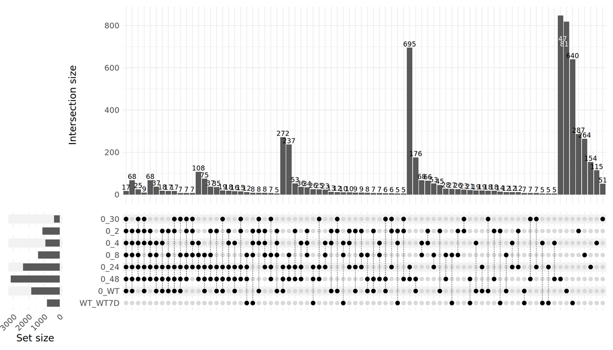

```r
venn.upregulated <- vd_complexUpset[["1"]] %>%
  dplyr::select(-gene_id) %>%
  as.data.frame

time_points <- c("0_30", "0_2", "0_4", "0_8", "0_24", "0_48", "0_WT", "WT_WT7D")

p <- upset(
  venn.upregulated,
  intersect = rev(time_points),
  sort_sets = FALSE,
  name = NULL,
  width_ratio = 0.1,
  sort_intersections_by = c("degree", "cardinality"),
  set_sizes = upset_set_size(),
  wrap = FALSE,
  themes = my_theme,
  min_size = 5,
  matrix = my_intersection_matrix
  )

ggsave(filename = "figures/upset_all_upregulated.pdf",
       plot = p,
       height = 8,
       width = 14)

p
```

We will focus on a subset of more interesting intersections, ie. intersctions of consecutive time points.

```r
grouped_data <- venn.data[["1"]] %>%
  dplyr::group_by(time_point)

keys <- grouped_data %>%
  dplyr::group_keys() %>%
  dplyr::pull("time_point")
keys <- paste0("X", keys)

L <- grouped_data %>%
  dplyr::group_split() %>%
  purrr::set_names(keys) %>%
  purrr::map(dplyr::pull, "gene_id")

p <- UpSetR::upset(
  UpSetR::fromList(L),
  intersections = list(
    list(`0_30` = "X0_30", `0_2` = "X0_2", `0_4` = "X0_4", `0_8` = "X0_8", `0_24` = "X0_24", `0_48` = "X0_48", `0_WT` = "X0_WT"),
    list(`0_30` = "X0_30", `0_2` = "X0_2", `0_4` = "X0_4", `0_8` = "X0_8", `0_24` = "X0_24", `0_48` = "X0_48"),
    list(`0_2` = "X0_2", `0_4` = "X0_4", `0_8` = "X0_8", `0_24` = "X0_24", `0_48` = "X0_48"),
    list(`0_4` = "X0_4", `0_8` = "X0_8", `0_24` = "X0_24", `0_48` = "X0_48"),
    list(`0_8` = "X0_8", `0_24` = "X0_24", `0_48` = "X0_48"),
    list(`0_24` = "X0_24", `0_48` = "X0_48")
  ),
  sets = c("X0_30","X0_2","X0_4","X0_8","X0_24","X0_48", "X0_WT"),
  keep.order = TRUE,
  order.by = "degree",
  decreasing = TRUE,
  text.scale = 1.5
  )

pdf("figures/upset_selected_upregulate.pdf", height = 8, width = 14)
p
dev.off()
```

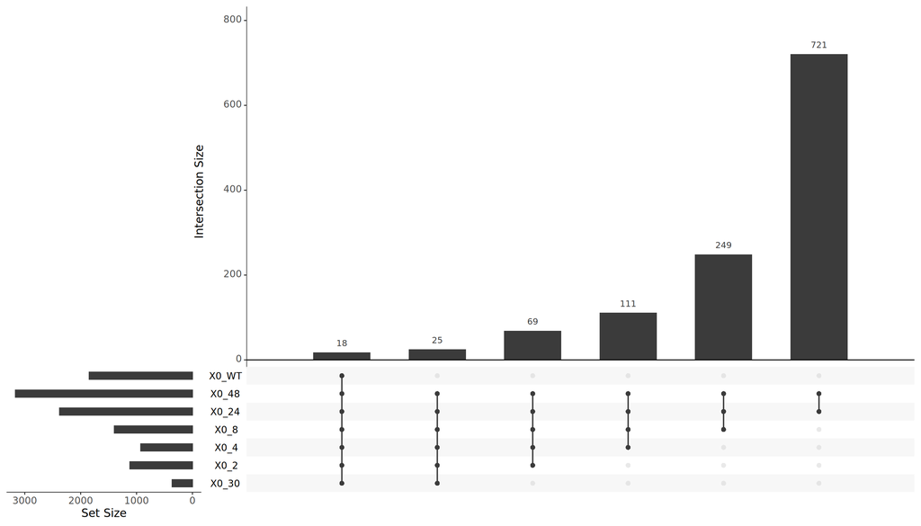

```r
p
```

Next, we will pull out the gene lists corresponding to these intersections and compute GO terms enrichments on those.

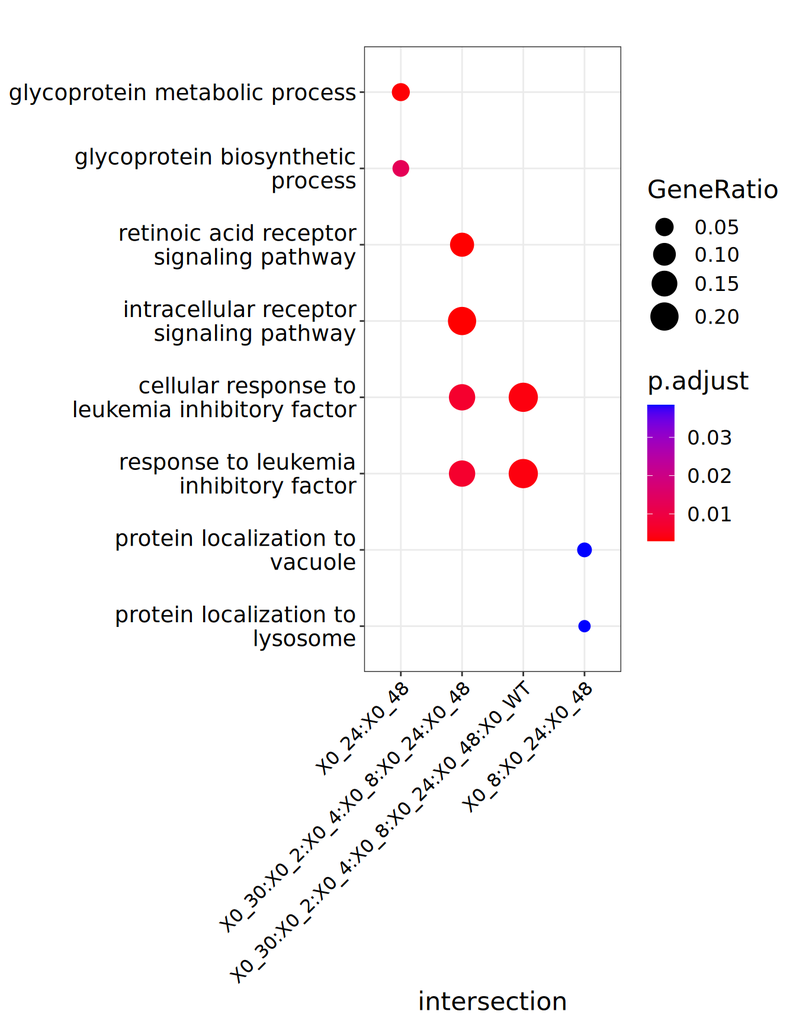

```r
x <- overlapGroups(L %>% purrr::discard_at("XWT_WT7D"))

genes <- list(
  `X0_30:X0_2:X0_4:X0_8:X0_24:X0_48:X0_WT` = attr(x, "elements")[x[["X0_30:X0_2:X0_4:X0_8:X0_24:X0_48:X0_WT"]]],
  `X0_30:X0_2:X0_4:X0_8:X0_24:X0_48` = attr(x, "elements")[x[["X0_30:X0_2:X0_4:X0_8:X0_24:X0_48"]]],
  `X0_2:X0_4:X0_8:X0_24:X0_48` = attr(x, "elements")[x[["X0_2:X0_4:X0_8:X0_24:X0_48"]]],
  `X0_4:X0_8:X0_24:X0_48` = attr(x, "elements")[x[["X0_4:X0_8:X0_24:X0_48"]]],
  `X0_8:X0_24:X0_48` = attr(x, "elements")[x[["X0_8:X0_24:X0_48"]]],
  `X0_24:X0_48` = attr(x, "elements")[x[["X0_24:X0_48"]]]
) %>%
  purrr::map2(.y = names(.), ~tibble(gene_id = .x, intersection = .y)) %>%
  purrr::reduce(bind_rows) %>%
  dplyr::mutate(gene_id = paste0("MGI:", gene_id))

universe <- all_deg %>%
  pull(gene_id) %>%
  unique() %>%
  paste0("MGI:", .)

ck_upset_up <- compareCluster(gene_id ~ intersection,
                     data = genes,
                     fun = enrichGO,
                     OrgDb = 'org.Mm.eg.db',
                     keyType = "MGI",
                     ont = "BP",
                     universe = universe,
                     minGSSize = 15)

ck_upset_up <- setReadable(ck_upset_up, OrgDb = org.Mm.eg.db, keyType = "MGI")

p <- dotplot(ck_upset_up,
        x = "intersection",
        showCategory = 2) +
  theme(axis.text.x = element_text(angle = 45, hjust = 1),
        text = element_text(size=16),
        axis.title = element_text(size=16),
        axis.text.y = element_text(size=14))

ggsave("figures/go_enrichment_upregulated_shared_genes.pdf",
       plot = p,
       height = 8,
       width = 14)

p
```

Tables below show detailed results.

#### 0_30 & 0_2 & 0_4 & 0_8 & 0_24 & 0_48 & 0_WT

| Intersection | Description | Generatio | Bgratio | Adjusted p-value | Geneid | Count |
| --- | --- | --- | --- | --- | --- | --- |
| X0_30:X0_2:X0_4:X0_8:X0_24:X0_48:X0_WT | cellular response to leukemia inhibitory factor | 4/18 | 138/17957 | 3.8e-03 | Gclm/Hk2/Spry2/Mkrn1 | 4 |
| X0_30:X0_2:X0_4:X0_8:X0_24:X0_48:X0_WT | response to leukemia inhibitory factor | 4/18 | 139/17957 | 3.8e-03 | Gclm/Hk2/Spry2/Mkrn1 | 4 |
| X0_30:X0_2:X0_4:X0_8:X0_24:X0_48:X0_WT | cell-cell junction organization | 4/18 | 186/17957 | 6.6e-03 | Wdr1/Actn4/Fermt2/Actb | 4 |
| X0_30:X0_2:X0_4:X0_8:X0_24:X0_48:X0_WT | cell junction assembly | 5/18 | 394/17957 | 6.6e-03 | Wdr1/Ajuba/Actn4/Fermt2/Actb | 5 |
| X0_30:X0_2:X0_4:X0_8:X0_24:X0_48:X0_WT | actin filament organization | 5/18 | 429/17957 | 7.9e-03 | Wdr1/Dpysl3/Actn4/Fermt2/Spta1 | 5 |
| X0_30:X0_2:X0_4:X0_8:X0_24:X0_48:X0_WT | wound healing, spreading of epidermal cells | 2/18 | 18/17957 | 1.8e-02 | Ajuba/Fermt2 | 2 |
| X0_30:X0_2:X0_4:X0_8:X0_24:X0_48:X0_WT | protein localization to cell junction | 3/18 | 118/17957 | 1.8e-02 | Actn4/Fermt2/Actb | 3 |
| X0_30:X0_2:X0_4:X0_8:X0_24:X0_48:X0_WT | chromatin remodeling | 4/18 | 314/17957 | 1.8e-02 | Kdm1a/Dnmt3l/Bicral/Actb | 4 |
| X0_30:X0_2:X0_4:X0_8:X0_24:X0_48:X0_WT | regulation of cell morphogenesis | 4/18 | 317/17957 | 1.8e-02 | Wdr1/Actn4/Fermt2/Spta1 | 4 |
| X0_30:X0_2:X0_4:X0_8:X0_24:X0_48:X0_WT | regulation of protein serine/threonine kinase activity | 4/18 | 324/17957 | 1.8e-02 | Ajuba/Spry2/Fermt2/Actb | 4 |

[output cut: 26 more lines]

#### 0_30 & 0_2 & 0_4 & 0_8 & 0_24 & 0_48

| Intersection | Description | Generatio | Bgratio | Adjusted p-value | Geneid | Count |
| --- | --- | --- | --- | --- | --- | --- |
| X0_30:X0_2:X0_4:X0_8:X0_24:X0_48 | retinoic acid receptor signaling pathway | 3/25 | 28/17957 | 2.9e-03 | Ctbp2/Calr/Rarg | 3 |
| X0_30:X0_2:X0_4:X0_8:X0_24:X0_48 | intracellular receptor signaling pathway | 5/25 | 203/17957 | 2.9e-03 | Ywhah/Ctbp2/Calr/Rarg/Kdm3a | 5 |
| X0_30:X0_2:X0_4:X0_8:X0_24:X0_48 | cellular response to leukemia inhibitory factor | 4/25 | 138/17957 | 6.9e-03 | Ctbp2/Kdm5b/Rarg/Kdm3a | 4 |
| X0_30:X0_2:X0_4:X0_8:X0_24:X0_48 | response to leukemia inhibitory factor | 4/25 | 139/17957 | 6.9e-03 | Ctbp2/Kdm5b/Rarg/Kdm3a | 4 |
| X0_30:X0_2:X0_4:X0_8:X0_24:X0_48 | hormone-mediated signaling pathway | 4/25 | 146/17957 | 6.9e-03 | Ywhah/Calr/Rarg/Kdm3a | 4 |
| X0_30:X0_2:X0_4:X0_8:X0_24:X0_48 | maintenance of protein location in cell | 3/25 | 66/17957 | 1.3e-02 | Topors/Hspa5/Pfn1 | 3 |
| X0_30:X0_2:X0_4:X0_8:X0_24:X0_48 | positive regulation of neuron projection development | 4/25 | 212/17957 | 1.8e-02 | Enc1/Rrn3/Hspa5/Nrg1 | 4 |
| X0_30:X0_2:X0_4:X0_8:X0_24:X0_48 | positive regulation of cell projection organization | 5/25 | 409/17957 | 1.8e-02 | Enc1/Rrn3/Hspa5/Nrg1/Pfn1 | 5 |
| X0_30:X0_2:X0_4:X0_8:X0_24:X0_48 | nucleolus organization | 2/25 | 16/17957 | 1.8e-02 | Nolc1/Rrn3 | 2 |
| X0_30:X0_2:X0_4:X0_8:X0_24:X0_48 | steroid catabolic process | 2/25 | 18/17957 | 2.1e-02 | Ywhah/Hsd17b14 | 2 |

[output cut: 12 more lines]

#### 0_2 & 0_4 & 0_8 & 0_24 & 0_48

**Warning** No enriched terms.

#### 0_4 & 0_8 & 0_24 & 0_48

**Warning** No enriched terms.

#### 0_8 & 0_24 & 0_48

```r
create_go_dt(splitted_upset_up[[4]])
```

| Intersection | Description | Generatio | Bgratio | Adjusted p-value | Geneid | Count |
| --- | --- | --- | --- | --- | --- | --- |
| X0_8:X0_24:X0_48 | protein localization to vacuole | 7/242 | 64/17957 | 3.8e-02 | Atg14/Vps37a/Ap3b1/Glmp/Mfsd1/Pik3r4/Nedd4 | 7 |
| X0_8:X0_24:X0_48 | protein localization to lysosome | 6/242 | 44/17957 | 3.8e-02 | Atg14/Ap3b1/Glmp/Mfsd1/Pik3r4/Nedd4 | 6 |
| X0_8:X0_24:X0_48 | receptor metabolic process | 7/242 | 69/17957 | 3.9e-02 | Kif16b/Psen1/Fut8/Gprasp1/Als2/Pik3r4/Nedd4 | 7 |

#### 0_24 & 0_48

```r
create_go_dt(splitted_upset_up[[1]])
```

| Intersection | Description | Generatio | Bgratio | Adjusted p-value | Geneid | Count |
| --- | --- | --- | --- | --- | --- | --- |
| X0_24:X0_48 | glycoprotein metabolic process | 32/677 | 325/17957 | 3.1e-03 | Pcsk6/Man1a2/Ext2/St6gal1/Itm2b/St3gal4/Hs2st1/Hs6st2/Extl3/…… | 32 |
| X0_24:X0_48 | glycoprotein biosynthetic process | 26/677 | 264/17957 | 1.3e-02 | Ext2/St6gal1/Itm2b/St3gal4/Hs2st1/Hs6st2/Extl3/St3gal6/Galnt10/Galnt6/Krtcap2/Dpy19l1/Galnt16/Gcnt3/Chst11/B3gnt5/Galnt17/Slc35d1/Fut10/B4galt7/Uggt1/Poglut1/Galnt12/Galnt3/Mgat5/Insr | 26 |
| X0_24:X0_48 | glycosylation | 22/677 | 207/17957 | 1.3e-02 | Ext2/St6gal1/St3gal4/Cds2/Extl3/St3gal6/Galnt10/Galnt6/Krtcap2/Dpy19l1/Galnt16/Gcnt3/B3gnt5/Galnt17/Fut10/B4galt7/Uggt1/Poglut1/Galnt12/Galnt3/Mgat5/Gba | 22 |
| X0_24:X0_48 | axonogenesis | 37/677 | 459/17957 | 1.3e-02 | Xk/Ntn1/Efnb2/Skil/Myo5b/Plxna3/Ephb6/Ece1/Sema7a/Slit3/Cdk5…… | 37 |
| X0_24:X0_48 | protein glycosylation | 20/677 | 187/17957 | 1.9e-02 | Ext2/St6gal1/St3gal4/Extl3/St3gal6/Galnt10/Galnt6/Krtcap2/Dpy19l1/Galnt16/Gcnt3/B3gnt5/Galnt17/Fut10/B4galt7/Uggt1/Poglut1/Galnt12/Galnt3/Mgat5 | 20 |
| X0_24:X0_48 | macromolecule glycosylation | 20/677 | 187/17957 | 1.9e-02 | Ext2/St6gal1/St3gal4/Extl3/St3gal6/Galnt10/Galnt6/Krtcap2/Dpy19l1/Galnt16/Gcnt3/B3gnt5/Galnt17/Fut10/B4galt7/Uggt1/Poglut1/Galnt12/Galnt3/Mgat5 | 20 |
| X0_24:X0_48 | negative regulation of Wnt signaling pathway | 18/677 | 159/17957 | 1.9e-02 | Fzd6/Dab2/Axin2/Tpbg/Ruvbl2/Mapk14/Tmem88/Ccdc88c/Prickle1/Ubac2/Shisa2/Apcdd1/Tmem170b/App/Bmp2/Sfrp1/Mcc/Mdk | 18 |
| X0_24:X0_48 | regulation of actin cytoskeleton reorganization | 8/677 | 40/17957 | 4.4e-02 | Cdc42/F11r/Cd2ap/Sema3e/Carmil3/Hck/Mdk/Tek | 8 |
| X0_24:X0_48 | negative regulation of canonical Wnt signaling pathway | 15/677 | 129/17957 | 4.4e-02 | Fzd6/Dab2/Axin2/Tpbg/Ruvbl2/Mapk14/Tmem88/Ccdc88c/Prickle1/Ubac2/Tmem170b/App/Sfrp1/Mcc/Mdk | 15 |
| X0_24:X0_48 | protein autoubiquitination | 11/677 | 75/17957 | 4.4e-02 | Ube2a/Rnf13/Rnf11/Cnot4/Sh3rf1/Wwp2/Rnf187/Ube4b/Mta1/Trim37/Sh3rf2 | 11 |

[output cut: 8 more lines]

### Downregulated

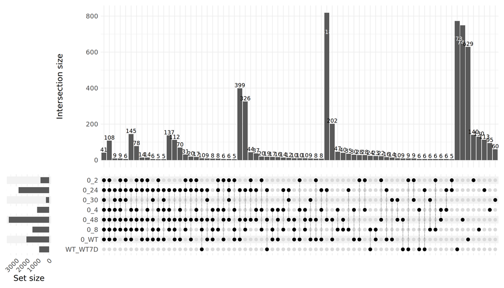

```r
venn.downregulated <- vd_complexUpset[["-1"]] %>%
  dplyr::select(-gene_id)

time_points <- colnames(venn.downregulated)

p <- upset(
  venn.downregulated,
  intersect = rev(time_points),
  sort_sets = FALSE,
  name = NULL,
  width_ratio = 0.1,
  sort_intersections_by = c("degree", "cardinality"),
  set_sizes = upset_set_size(),
  wrap = FALSE,
  themes = my_theme,
  min_size = 5,
  matrix = my_intersection_matrix
  )

ggsave(filename = "figures/upset_all_downregulated.pdf",
       plot = p,
       height = 8,
       width = 14)

p
```

Similarly to upregulated genes, we will produce a UpSet plot showing the number of DEG shared across consecutive time points.

```r
grouped_data <- venn.data[["-1"]] %>%
  dplyr::group_by(time_point)

keys <- grouped_data %>%
  dplyr::group_keys() %>%
  dplyr::pull("time_point")
keys <- paste0("X", keys)

L <- grouped_data %>%
  dplyr::group_split() %>%
  purrr::set_names(keys) %>%
  purrr::map(dplyr::pull, "gene_id")

p <- UpSetR::upset(
  UpSetR::fromList(L),
  intersections = list(
    list(`0_30` = "X0_30", `0_2` = "X0_2", `0_4` = "X0_4",
         `0_8` = "X0_8", `0_24` = "X0_24", `0_48` = "X0_48"),
    list(`0_2` = "X0_2", `0_4` = "X0_4", `0_8` = "X0_8",
         `0_24` = "X0_24", `0_48` = "X0_48"),
    list(`0_4` = "X0_4", `0_8` = "X0_8", `0_24` = "X0_24",
         `0_48` = "X0_48"),
    list(`0_8` = "X0_8", `0_24` = "X0_24", `0_48` = "X0_48"),
    list(`0_24` = "X0_24", `0_48` = "X0_48")
  ),
  sets = c("X0_30","X0_2","X0_4","X0_8","X0_24","X0_48"),
  keep.order = TRUE,
  order.by = "freq",
  decreasing = FALSE,
  text.scale = 1.5
  )

pdf("figures/upset_selected_downregulated.pdf",
    height = 8,
    width = 14)
p
dev.off()
```

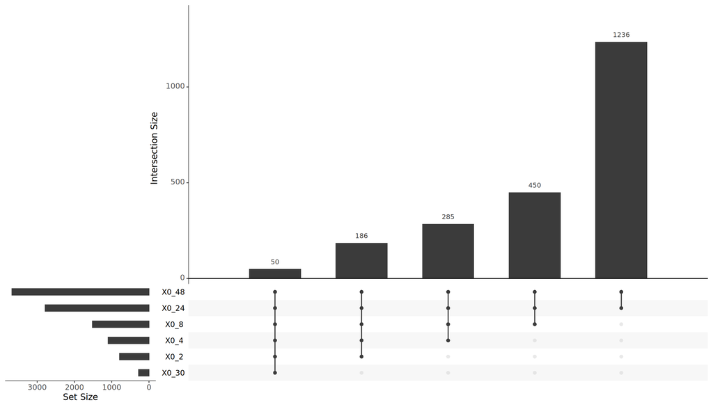

```r
p
```

We will compute GO Enrichment also for the sets of shared downregulated genes.

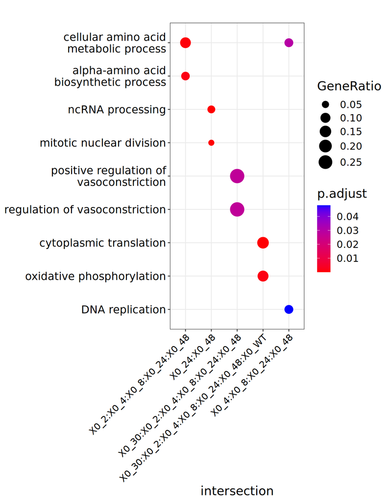

```r
x <- overlapGroups(L %>% purrr::discard_at("XWT_WT7D"))

genes <- list(
  `X0_30:X0_2:X0_4:X0_8:X0_24:X0_48:X0_WT` = attr(x, "elements")[x[["X0_30:X0_2:X0_4:X0_8:X0_24:X0_48:X0_WT"]]],
  `X0_30:X0_2:X0_4:X0_8:X0_24:X0_48` = attr(x, "elements")[x[["X0_30:X0_2:X0_4:X0_8:X0_24:X0_48"]]],
  `X0_2:X0_4:X0_8:X0_24:X0_48` = attr(x, "elements")[x[["X0_2:X0_4:X0_8:X0_24:X0_48"]]],
  `X0_4:X0_8:X0_24:X0_48` = attr(x, "elements")[x[["X0_4:X0_8:X0_24:X0_48"]]],
  `X0_8:X0_24:X0_48` = attr(x, "elements")[x[["X0_8:X0_24:X0_48"]]],
  `X0_24:X0_48` = attr(x, "elements")[x[["X0_24:X0_48"]]]
) %>%
  purrr::map2(.y = names(.), ~tibble(gene_id = .x, intersection = .y)) %>%
  purrr::reduce(bind_rows) %>%
  dplyr::mutate(gene_id = paste0("MGI:", gene_id))

universe <- all_deg %>%
  pull(gene_id) %>%
  unique() %>%
  paste0("MGI:", .)

ck_upset_down <- compareCluster(gene_id ~ intersection,
                     data = genes,
                     fun = enrichGO,
                     OrgDb = 'org.Mm.eg.db',
                     keyType = "MGI",
                     ont = "BP",
                     universe = universe,
                     minGSSize = 15)

ck_upset_down <- setReadable(ck_upset_down, OrgDb = org.Mm.eg.db, keyType = "MGI")

p <- dotplot(ck_upset_down,
        x = "intersection",
        showCategory = 2) +
  theme(axis.text.x = element_text(angle = 45, hjust = 1),
        text = element_text(size=16),
        axis.title = element_text(size = 16),
        axis.text.y = element_text(size = 14))

ggsave(filename = "figures/go_enrichment_downregulated_shared_genes.pdf",
       plot = p,
       height = 8,
       width = 14)

p
```

Tables below show detailed results.

#### 0_30 & 0_2 & 0_4 & 0_8 & 0_24 & 0_48 & 0_WT

| Intersection | Description | Generatio | Bgratio | Adjusted p-value | Geneid | Count |
| --- | --- | --- | --- | --- | --- | --- |
| X0_30:X0_2:X0_4:X0_8:X0_24:X0_48:X0_WT | cytoplasmic translation | 6/39 | 142/17957 | 2.8e-04 | Rpl26/Rpl36a/Rpl39/Rpl22l1/Rpl34/Rps27a | 6 |
| X0_30:X0_2:X0_4:X0_8:X0_24:X0_48:X0_WT | oxidative phosphorylation | 5/39 | 123/17957 | 1.6e-03 | Cox7c/Cox7a2/Ndufc2/Atp5j2/Ndufb1 | 5 |
| X0_30:X0_2:X0_4:X0_8:X0_24:X0_48:X0_WT | aerobic respiration | 5/39 | 166/17957 | 4.6e-03 | Cox7c/Cox7a2/Ndufc2/Atp5j2/Ndufb1 | 5 |
| X0_30:X0_2:X0_4:X0_8:X0_24:X0_48:X0_WT | cellular respiration | 5/39 | 218/17957 | 1.3e-02 | Cox7c/Cox7a2/Ndufc2/Atp5j2/Ndufb1 | 5 |
| X0_30:X0_2:X0_4:X0_8:X0_24:X0_48:X0_WT | proton motive force-driven mitochondrial ATP synthesis | 3/39 | 56/17957 | 2.4e-02 | Ndufc2/Atp5j2/Ndufb1 | 3 |
| X0_30:X0_2:X0_4:X0_8:X0_24:X0_48:X0_WT | proton motive force-driven ATP synthesis | 3/39 | 61/17957 | 2.5e-02 | Ndufc2/Atp5j2/Ndufb1 | 3 |
| X0_30:X0_2:X0_4:X0_8:X0_24:X0_48:X0_WT | energy derivation by oxidation of organic compounds | 5/39 | 302/17957 | 3.0e-02 | Cox7c/Cox7a2/Ndufc2/Atp5j2/Ndufb1 | 5 |
| X0_30:X0_2:X0_4:X0_8:X0_24:X0_48:X0_WT | protein targeting to mitochondrion | 3/39 | 74/17957 | 3.0e-02 | Srebf1/Dnajc19/Tomm5 | 3 |
| X0_30:X0_2:X0_4:X0_8:X0_24:X0_48:X0_WT | DNA damage response, signal transduction by p53 class mediator resulting in transcription of p21 class mediator | 2/39 | 17/17957 | 3.0e-02 | Rpl26/Rps27l | 2 |
| X0_30:X0_2:X0_4:X0_8:X0_24:X0_48:X0_WT | cardiolipin metabolic process | 2/39 | 17/17957 | 3.0e-02 | Crls1/Dnajc19 | 2 |

[output cut: 13 more lines]

#### 0_30 & 0_2 & 0_4 & 0_8 & 0_24 & 0_48

| Intersection | Description | Generatio | Bgratio | Adjusted p-value | Geneid | Count |
| --- | --- | --- | --- | --- | --- | --- |
| X0_30:X0_2:X0_4:X0_8:X0_24:X0_48 | positive regulation of vasoconstriction | 2/7 | 46/17957 | 2.7e-02 | Add3/Trpm4 | 2 |
| X0_30:X0_2:X0_4:X0_8:X0_24:X0_48 | regulation of vasoconstriction | 2/7 | 73/17957 | 2.7e-02 | Add3/Trpm4 | 2 |
| X0_30:X0_2:X0_4:X0_8:X0_24:X0_48 | gluconeogenesis | 2/7 | 75/17957 | 2.7e-02 | Pck2/Atf4 | 2 |
| X0_30:X0_2:X0_4:X0_8:X0_24:X0_48 | hexose biosynthetic process | 2/7 | 79/17957 | 2.7e-02 | Pck2/Atf4 | 2 |
| X0_30:X0_2:X0_4:X0_8:X0_24:X0_48 | positive regulation of neuron apoptotic process | 2/7 | 79/17957 | 2.7e-02 | Nupr1/Atf4 | 2 |
| X0_30:X0_2:X0_4:X0_8:X0_24:X0_48 | cellular response to organic cyclic compound | 3/7 | 421/17957 | 2.7e-02 | Pck2/Trpm4/Atf4 | 3 |
| X0_30:X0_2:X0_4:X0_8:X0_24:X0_48 | monosaccharide biosynthetic process | 2/7 | 85/17957 | 2.7e-02 | Pck2/Atf4 | 2 |
| X0_30:X0_2:X0_4:X0_8:X0_24:X0_48 | vasoconstriction | 2/7 | 95/17957 | 2.7e-02 | Add3/Trpm4 | 2 |
| X0_30:X0_2:X0_4:X0_8:X0_24:X0_48 | regulation of biomineral tissue development | 2/7 | 96/17957 | 2.7e-02 | Trpm4/Atf4 | 2 |
| X0_30:X0_2:X0_4:X0_8:X0_24:X0_48 | regulation of muscle cell apoptotic process | 2/7 | 97/17957 | 2.7e-02 | Nupr1/Atf4 | 2 |

[output cut: 31 more lines]

#### 0_2 & 0_4 & 0_8 & 0_24 & 0_48

| Intersection | Description | Generatio | Bgratio | Adjusted p-value | Geneid | Count |
| --- | --- | --- | --- | --- | --- | --- |
| X0_2:X0_4:X0_8:X0_24:X0_48 | cellular amino acid metabolic process | 9/73 | 238/17957 | 7.2e-04 | Shmt2/Mars1/Cars/Phgdh/Aldh18a1/Nars/Yars/Psat1/Psph | 9 |
| X0_2:X0_4:X0_8:X0_24:X0_48 | alpha-amino acid biosynthetic process | 5/73 | 53/17957 | 1.7e-03 | Shmt2/Phgdh/Aldh18a1/Psat1/Psph | 5 |
| X0_2:X0_4:X0_8:X0_24:X0_48 | cellular amino acid biosynthetic process | 5/73 | 60/17957 | 2.1e-03 | Shmt2/Phgdh/Aldh18a1/Psat1/Psph | 5 |
| X0_2:X0_4:X0_8:X0_24:X0_48 | serine family amino acid metabolic process | 4/73 | 31/17957 | 2.6e-03 | Shmt2/Phgdh/Psat1/Psph | 4 |
| X0_2:X0_4:X0_8:X0_24:X0_48 | tRNA aminoacylation for protein translation | 4/73 | 40/17957 | 4.3e-03 | Mars1/Cars/Nars/Yars | 4 |
| X0_2:X0_4:X0_8:X0_24:X0_48 | neutral amino acid transport | 4/73 | 40/17957 | 4.3e-03 | Slc1a5/Slc7a5/Slc1a4/Slc3a2 | 4 |
| X0_2:X0_4:X0_8:X0_24:X0_48 | amino acid transmembrane transport | 5/73 | 84/17957 | 4.3e-03 | Slc1a5/Slc7a5/Lrrc8d/Slc1a4/Slc3a2 | 5 |
| X0_2:X0_4:X0_8:X0_24:X0_48 | tRNA aminoacylation | 4/73 | 43/17957 | 4.3e-03 | Mars1/Cars/Nars/Yars | 4 |
| X0_2:X0_4:X0_8:X0_24:X0_48 | amino acid import across plasma membrane | 4/73 | 43/17957 | 4.3e-03 | Slc1a5/Slc7a5/Slc1a4/Slc3a2 | 4 |
| X0_2:X0_4:X0_8:X0_24:X0_48 | amino acid activation | 4/73 | 44/17957 | 4.3e-03 | Mars1/Cars/Nars/Yars | 4 |

[output cut: 10 more lines]

#### 0_4 & 0_8 & 0_24 & 0_48

| Intersection | Description | Generatio | Bgratio | Adjusted p-value | Geneid | Count |
| --- | --- | --- | --- | --- | --- | --- |
| X0_4:X0_8:X0_24:X0_48 | cellular amino acid metabolic process | 10/137 | 238/17957 | 3.0e-02 | Tars/Farsb/Asns/Lars/Aldh6a1/Dpys/Pycr1/Tarsl2/Accsl/Acat1 | 10 |
| X0_4:X0_8:X0_24:X0_48 | DNA replication | 10/137 | 273/17957 | 4.8e-02 | Sin3a/Mcm6/Rpa2/Pclaf/Fam111a/Gins1/E2f8/Actr5/Primpol/Ccne1 | 10 |

#### 0_8 & 0_24 & 0_48

**Warning** No enriched terms.

#### 0_24 & 0_48

| Intersection | Description | Generatio | Bgratio | Adjusted p-value | Geneid | Count |
| --- | --- | --- | --- | --- | --- | --- |
| X0_24:X0_48 | ncRNA processing | 45/794 | 394/17957 | 2.2e-05 | Nsun2/Adat1/Elac2/Wbp11/Rnf113a2/Tsen15/Rpl14/Utp11/Eri1/Alk…… | 45 |
| X0_24:X0_48 | mitotic nuclear division | 36/794 | 301/17957 | 8.4e-05 | Nudc/Smc2/Kpnb1/Nek2/Kif11/Cdc23/Bub1/Knstrn/Incenp/Bcl7b/Sm…… | 36 |
| X0_24:X0_48 | ribonucleoprotein complex biogenesis | 44/794 | 413/17957 | 8.4e-05 | Abce1/Srsf10/Prmt5/Nom1/Eral1/Wbp11/Mterf3/Rpl14/Nop56/Utp11…… | 44 |
| X0_24:X0_48 | chromosome segregation | 39/794 | 364/17957 | 2.6e-04 | Nudc/Smc2/Kpnb1/Nek2/Sycp3/Kif11/Cdc23/Bub1/Knstrn/Incenp/Ce…… | 39 |
| X0_24:X0_48 | ribosome biogenesis | 34/794 | 295/17957 | 2.6e-04 | Abce1/Nom1/Eral1/Wbp11/Mterf3/Rpl14/Nop56/Utp11/Eri1/Tsr2/Mrto4/Rpusd2/Shq1/Usp36/Dis3/Pop7/Nop14/Ddx10/Gar1/Wdr46/Ddx49/Nol6/Nsun5/Urb1/Rrp12/Helb/Eri3/Kri1/Gtpbp10/Ddx27/Traf7/Rps27rt/Glul/Rpl27 | 34 |
| X0_24:X0_48 | nuclear division | 45/794 | 467/17957 | 5.3e-04 | Ddx4/Osm/Nudc/Smc2/Kpnb1/Nek2/Sycp3/Kif11/Cdc23/Bub1/Knstrn/…… | 45 |
| X0_24:X0_48 | mitotic sister chromatid segregation | 25/794 | 189/17957 | 5.4e-04 | Nudc/Smc2/Kpnb1/Nek2/Kif11/Cdc23/Bub1/Knstrn/Incenp/Bcl7b/Smc3/Cdc20/Zwilch/Ube2c/Cdc16/Anapc15/Psmg2/Slf2/Ppp2r1a/Ncapd3/Slf1/Smc5/Pogz/Ccnb1/Cenpc1 | 25 |
| X0_24:X0_48 | rRNA processing | 26/794 | 214/17957 | 1.5e-03 | Wbp11/Rpl14/Utp11/Eri1/Tsr2/Mrto4/Rpusd2/Shq1/Usp36/Dis3/Pop7/Nop14/Ddx10/Gar1/Wdr46/Ddx49/Nol6/Nsun5/Urb1/Rrp12/Helb/Eri3/Kri1/Ddx27/Rps27rt/Rpl27 | 26 |
| X0_24:X0_48 | sister chromatid segregation | 26/794 | 217/17957 | 1.7e-03 | Nudc/Smc2/Kpnb1/Nek2/Sycp3/Kif11/Cdc23/Bub1/Knstrn/Incenp/Bcl7b/Smc3/Cdc20/Zwilch/Ube2c/Cdc16/Anapc15/Psmg2/Slf2/Ppp2r1a/Ncapd3/Slf1/Smc5/Pogz/Ccnb1/Cenpc1 | 26 |
| X0_24:X0_48 | nuclear chromosome segregation | 32/794 | 302/17957 | 1.7e-03 | Nudc/Smc2/Kpnb1/Nek2/Sycp3/Kif11/Cdc23/Bub1/Knstrn/Incenp/Cenpf/Bcl7b/Smc3/Mlh3/Cdc20/Zwilch/Ube2c/Cdc16/Syde1/Anapc15/Psmg2/Sun1/Slf2/Ppp2r1a/Ncapd3/Slf1/Smc5/Pogz/Brip1/Fancd2/Ccnb1/Cenpc1 | 32 |

[output cut: 20 more lines]

## Plot OGT and OGA genes expression over time

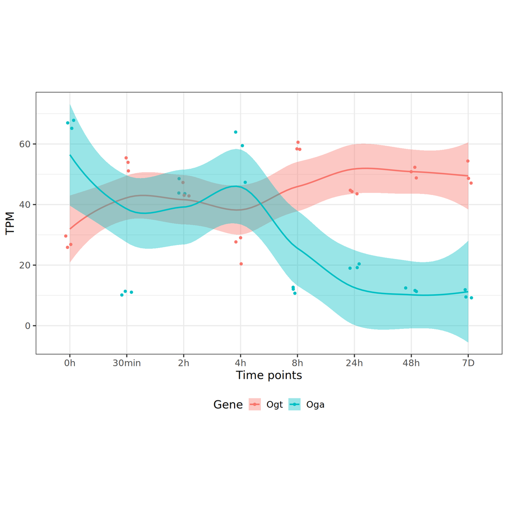

```r
ogt <- "MGI:1339639"
oga <- "MGI:1932139"

labs <- c("MGI:1339639" = "Ogt",
          "MGI:1932139" = "Oga")

p <- all_tpm %>%
  dplyr::as_tibble(rownames = "gene_id") %>%
  dplyr::filter(gene_id %in% c(ogt, oga)) %>%
  tidyr::pivot_longer(cols = -gene_id) %>%
  dplyr::mutate(
    tp = sapply(str_split(name, "_"), `[`, 1),
    rep = sapply(str_split(name, "_"), `[`, 2)
  ) %>%
  dplyr::filter(!grepl("WT", tp)) %>%
  ggplot2::ggplot(mapping = aes(x = tp,
                               y = value,
                               group = gene_id,
                               color = gene_id,
                               fill = gene_id)) +
  ggplot2::geom_jitter(width = 0.1) +
  ggplot2::geom_smooth(method = stats::loess) +
  ggplot2::scale_color_discrete(labels = labs, name = "Gene") +
  ggplot2::scale_fill_discrete(labels = labs, name = "Gene") +
  ggplot2::scale_x_discrete(name = "Time points",
                           labels = c("0h", "30min",
                                      "2h", "4h",
                                      "8h", "24h",
                                      "48h", "7D")) +
  ggplot2::ylab("TPM") +
  ggplot2::theme_bw(base_size = 16) +
  ggplot2::theme(aspect.ratio = 9/16,
                 legend.position = "bottom")

ggsave(filename = "figures/plot_oga_ogt_expression_over_time.pdf",
       plot = p,
       height = 6,
       width = 6)

p
```

# Plot RPL and RPS genes expression over time

We manually searched for ribosomal genes on the Mouse Genetics Informatics (MGI) website. We downloaded the results in CSV format and will use it to subset our gene expression table for ribosomal genes of interest.

```r
mgi_search_results <- read_csv("MGI_Features_20240610_071948.csv") %>%
  dplyr::filter(Type != "pseudogene"
                & Start != "syntenic"
                & !`Best Match Type` %in% c("Protein Domain", "old name", "Process")
                & Chr != "MT")
```

| Type | MGI ID | Symbol | Name | Chr | Start | End | Build | Strand | Best Match Type | Best Match | Match Score |
| --- | --- | --- | --- | --- | --- | --- | --- | --- | --- | --- | --- |
| protein coding gene | MGI:1351605 | Rpl3 | ribosomal protein L3 | 15 | 79961993 | 79967553 | GRCm39 | - | Name | ribosomal protein L3 | 3 |
| protein coding gene | MGI:1913461 | Rpl3l | ribosomal protein L3-like | 17 | 24946800 | 24955117 | GRCm39 | + | Name | ribosomal protein L3-like | 3 |
| protein coding gene | MGI:1915141 | Rpl4 | ribosomal protein L4 | 9 | 64080657 | 64085948 | GRCm39 | + | Name | ribosomal protein L4 | 3 |
| protein coding gene | MGI:102854 | Rpl5 | ribosomal protein L5 | 5 | 108048388 | 108056871 | GRCm39 | + | Name | ribosomal protein L5 | 3 |
| protein coding gene | MGI:108057 | Rpl6 | ribosomal protein L6 | 5 | 121342564 | 121347304 | GRCm39 | + | Name | ribosomal protein L6 | 3 |
| protein coding gene | MGI:98073 | Rpl7 | ribosomal protein L7 | 1 | 16171519 | 16174657 | GRCm39 | - | Name | ribosomal protein L7 | 3 |
| protein coding gene | MGI:1353472 | Rpl7a | ribosomal protein L7A | 2 | 26800776 | 26803330 | GRCm39 | + | Name | ribosomal protein L7A | 3 |
| protein coding gene | MGI:1913479 | Rpl7l1 | ribosomal protein L7-like 1 | 17 | 47084833 | 47093582 | GRCm39 | - | Name | ribosomal protein L7-like 1 | 3 |
| protein coding gene | MGI:1350927 | Rpl8 | ribosomal protein L8 | 15 | 76788278 | 76790514 | GRCm39 | + | Name | ribosomal protein L8 | 3 |
| protein coding gene | MGI:1298373 | Rpl9 | ribosomal protein L9 | 5 | 65545707 | 65548774 | GRCm39 | - | Name | ribosomal protein L9 | 3 |

[output cut: 179 more lines]

We will produce a clustered heatmap of Z-scores to show expression trends.

```r
selected_mgi <- mgi_search_results %>% pull("MGI ID")

print(sum(selected_mgi %in% rownames(all_counts_mor)) / length(selected_mgi) * 100)
```

```
## [1] 98.9418
```

```r
print(setdiff(selected_mgi, rownames(all_counts_mor)))
```

```
## [1] "MGI:3646958" "MGI:1915749"
```

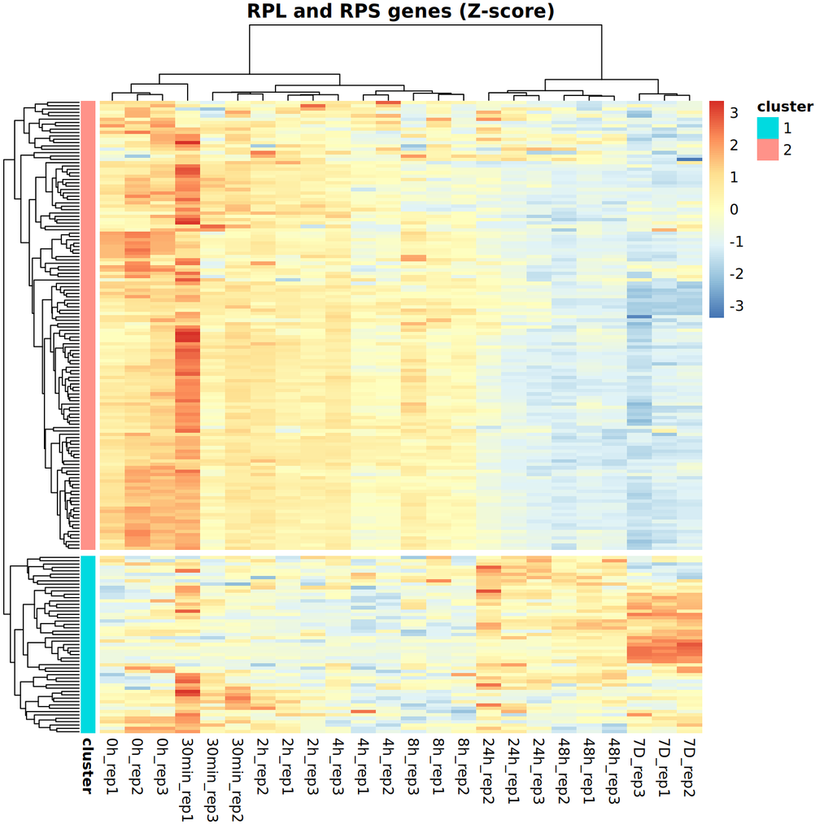

```r
mat <- all_counts_mor[rownames(all_counts_mor) %in% selected_mgi,
                      !grepl("WT", colnames(all_counts_mor))]

colorder <- rep(c("0h", "30min", "2h", "4h", "8h", "24h", "48h", "7D"), each = 3)
replicates <- paste0(rep("rep", 3), 1:3)
labs <- expand.grid(colorder, replicates)
labs <- paste(labs$Var1, labs$Var2, sep="_")

hcc <- hclust(
  distances::distance_matrix(
    distances::distances(
      scale(t(mat),
            center = rowMeans(mat),
            scale = rowSds(mat)),
      id_variable = colnames(mat)
    )),
  method = "ward.D")
hcc <- dendextend::rotate(hcc, order = labs)

hcr <- hclust(
  d = dist(t(scale(t(mat), center = rowMeans(mat), scale= rowSds(mat))), method = "euclidean"),
  method = "complete"
)

clusters <- data.frame(row.names = rownames(mat),
                       gene_id = rownames(mat),
                       cluster = as.factor(cutree(hcr, 2)))

pheatmap::pheatmap(
  mat,
  cluster_cols = hcc,
  cluster_rows = hcr,
  scale = "row",
  show_rownames = FALSE,
  main = "RPL and RPS genes (Z-score)",
  cutree_rows = 2,
  annotation_row = subset(clusters, select = -1)
)
```

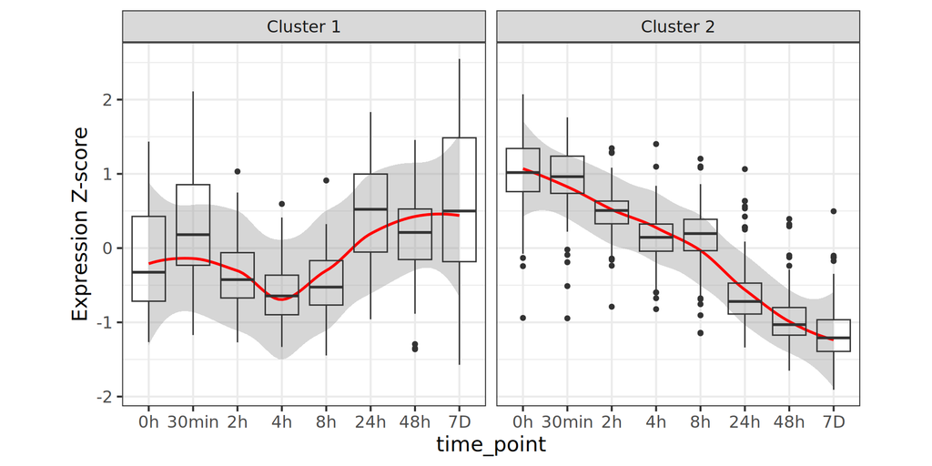

```r
mat <- t(scale(t(mat), center = rowMeans(mat), scale = rowSds(mat)))

dat <- mat %>%
  dplyr::as_tibble(rownames = "gene_id") %>%
  dplyr::inner_join(clusters) %>%
  tidyr::pivot_longer(cols = -c(gene_id, cluster)) %>%
  dplyr::mutate(time_point = sapply(str_split(name, "_"), `[`, 1),
         replicate = sapply(str_split(name, "_"), `[`, 2),
         time_point = factor(time_point, levels = c("0h", "30min", "2h", "4h", "8h", "24h", "48h", "7D"))) %>%
  dplyr::group_by(gene_id, time_point, cluster) %>%
  dplyr::summarise(exp = mean(value))

avg <- dat %>%
  group_by(time_point, cluster) %>%
  summarise(mean_exp = median(exp))

p <- dat %>%
  ggplot2::ggplot(aes(time_point, exp)) +
  ggplot2::geom_smooth(data = avg, mapping = aes(x =  time_point, y = mean_exp, group = cluster), color = "red") +
  ggplot2::geom_boxplot(fill = NA) +
  ggplot2::facet_wrap(~ cluster, labeller = labeller(cluster = c(`1` = "Cluster 1", `2` = "Cluster 2"))) +
  ggplot2::ylab("Expression Z-score") +
  ggplot2::theme_bw(base_size = 16) +
  ggplot2::theme(aspect.ratio = 1)

ggsave(filename = "figures/plot_rpl_rps_by_cluster.pdf",
       plot = p,
       height = 5,
       width = 10)

p
```

Tables below show the MGI search results table split by cluster.

#### Cluster 1

| Type | MGI ID | Symbol | Name | Chr | Start | End | Build | Strand | Best Match Type | Best Match | Match Score |
| --- | --- | --- | --- | --- | --- | --- | --- | --- | --- | --- | --- |
| protein coding gene | MGI:3647985 | Rpl10l | ribosomal protein L10-like | 12 | 66330153 | 66331175 | GRCm39 | - | Name | ribosomal protein L10-like | 3 |
| protein coding gene | MGI:1915443 | Rpl24 | ribosomal protein L24 | 16 | 55786638 | 55791798 | GRCm39 | + | Name | ribosomal protein L24 | 3 |
| protein coding gene | MGI:3644747 | Rpl32l | ribosomal protein L32-like | 10 | 20084236 | 20084634 | GRCm39 | + | Name | ribosomal protein L32-like | 3 |
| protein coding gene | MGI:1913733 | Rpl36al | ribosomal protein L36A-like | 12 | 69229508 | 69230841 | GRCm39 | - | Name | ribosomal protein L36A-like | 3 |
| protein coding gene | MGI:1915422 | Rpl39l | ribosomal protein L39-like | 16 | 9988090 | 9992775 | GRCm39 | + | Name | ribosomal protein L39-like | 3 |
| protein coding gene | MGI:104558 | Rps6ka1 | ribosomal protein S6 kinase polypeptide 1 | 4 | 133574601 | 133615108 | GRCm39 | - | Name | ribosomal protein S6 kinase polypeptide 1 | 3 |
| protein coding gene | MGI:104557 | Rps6ka3 | ribosomal protein S6 kinase polypeptide 3 | X | 158038652 | 158151240 | GRCm39 | + | Name | ribosomal protein S6 kinase polypeptide 3 | 3 |
| protein coding gene | MGI:1930076 | Rps6ka4 | ribosomal protein S6 kinase, polypeptide 4 | 19 | 6806578 | 6818004 | GRCm39 | - | Name | ribosomal protein S6 kinase, polypeptide 4 | 3 |
| protein coding gene | MGI:1914321 | Rps6ka6 | ribosomal protein S6 kinase polypeptide 6 | X | 110297889 | 110447656 | GRCm39 | - | Name | ribosomal protein S6 kinase polypeptide 6 | 3 |
| protein coding gene | MGI:1270849 | Rps6kb1 | ribosomal protein S6 kinase, polypeptide 1 | 11 | 86389697 | 86435631 | GRCm39 | - | Name | ribosomal protein S6 kinase, polypeptide 1 | 3 |

[output cut: 43 more lines]

#### Cluster 2

| Type | MGI ID | Symbol | Name | Chr | Start | End | Build | Strand | Best Match Type | Best Match | Match Score |
| --- | --- | --- | --- | --- | --- | --- | --- | --- | --- | --- | --- |
| protein coding gene | MGI:1351605 | Rpl3 | ribosomal protein L3 | 15 | 79961993 | 79967553 | GRCm39 | - | Name | ribosomal protein L3 | 3 |
| protein coding gene | MGI:1913461 | Rpl3l | ribosomal protein L3-like | 17 | 24946800 | 24955117 | GRCm39 | + | Name | ribosomal protein L3-like | 3 |
| protein coding gene | MGI:1915141 | Rpl4 | ribosomal protein L4 | 9 | 64080657 | 64085948 | GRCm39 | + | Name | ribosomal protein L4 | 3 |
| protein coding gene | MGI:102854 | Rpl5 | ribosomal protein L5 | 5 | 108048388 | 108056871 | GRCm39 | + | Name | ribosomal protein L5 | 3 |
| protein coding gene | MGI:108057 | Rpl6 | ribosomal protein L6 | 5 | 121342564 | 121347304 | GRCm39 | + | Name | ribosomal protein L6 | 3 |
| protein coding gene | MGI:98073 | Rpl7 | ribosomal protein L7 | 1 | 16171519 | 16174657 | GRCm39 | - | Name | ribosomal protein L7 | 3 |
| protein coding gene | MGI:1353472 | Rpl7a | ribosomal protein L7A | 2 | 26800776 | 26803330 | GRCm39 | + | Name | ribosomal protein L7A | 3 |
| protein coding gene | MGI:1913479 | Rpl7l1 | ribosomal protein L7-like 1 | 17 | 47084833 | 47093582 | GRCm39 | - | Name | ribosomal protein L7-like 1 | 3 |
| protein coding gene | MGI:1350927 | Rpl8 | ribosomal protein L8 | 15 | 76788278 | 76790514 | GRCm39 | + | Name | ribosomal protein L8 | 3 |
| protein coding gene | MGI:1298373 | Rpl9 | ribosomal protein L9 | 5 | 65545707 | 65548774 | GRCm39 | - | Name | ribosomal protein L9 | 3 |

[output cut: 124 more lines]

We will also produce a Volcano and MA plots highlighting significantly deregulated gene coding for ribosomal proteins.

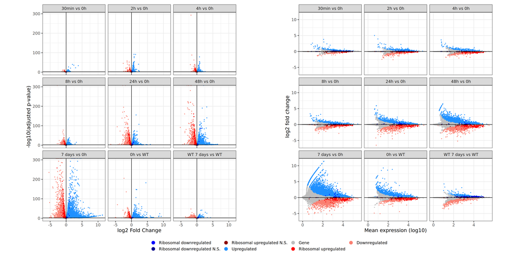

```r
pick_color <- function (gene_id, deg_status, direction) {
  if (length(deg_status) != length(direction)){
    stop("Input vectors must have the same length.")
  }
  color <- rep("grey", length(deg_status))
  color[deg_status & direction == 1] <- "dodgerblue"
  color[deg_status & direction == -1] <- "salmon"
  color[deg_status
        & direction == 1
        & gene_id %in% mgi_search_results$`MGI ID`] <- "blue"
  color[deg_status
        & direction == -1
        & gene_id %in% mgi_search_results$`MGI ID`] <- "red"
  color[!deg_status
        & direction == 1
        & gene_id %in% mgi_search_results$`MGI ID`] <- "darkblue"
  color[!deg_status
        & direction == -1
        & gene_id %in% mgi_search_results$`MGI ID`] <- "darkred"
  return(color)
}

point_size <- 0.5

legend_labels <-  c(dodgerblue = "Upregulated",
                    salmon = "Downregulated",
                    grey = "Gene",
                    darkred = "Ribosomal upregulated N.S.",
                    darkblue = "Ribosomal downregulated N.S.",
                    red = "Ribosomal upregulated",
                    blue = "Ribosomal downregulated")

labels <- c(`0_30` = "30min vs 0h",
            `0_2` = "2h vs 0h",
            `0_4` = "4h vs 0h",
            `0_8` = "8h vs 0h",
            `0_24` = "24h vs 0h",
            `0_48` = "48h vs 0h",
            `0_7D` = "7 days vs 0h",
            `0_WT` = "0h vs WT",
            `WT_WT7D` = "WT 7 days vs WT")


volcano <- all_deg %>%
  mutate(color = pick_color(gene_id, deg, direction)) %>%
  ggplot(aes(
    x = log2FoldChange,
    y = -log10(padj),
    color = color)
    ) +
  geom_point(size = point_size) +
  geom_point(
    data = all_deg %>%
      mutate(color = pick_color(gene_id, deg, direction)) %>%
      filter(gene_id %in% mgi_search_results$`MGI ID`),
    size = point_size
  ) +
  geom_hline(
    yintercept = -log10(pval_thr),
    color = "black") +
  geom_vline(
    xintercept = c(-lfc_thr, lfc_thr),
    color = "black") +
  scale_color_identity(
    guide = "legend",
    name = "",
    labels = legend_labels) +
  guides(colour = guide_legend(override.aes = list(size = 4))) +
  xlab("log2 Fold Change") +
  ylab("-log10(adjusted p-value)") +
  facet_wrap(facets = vars(time_point), ncol = 3,
             labeller = labeller(time_point = labels)) +
  theme_bw(base_size = 14) +
  theme(aspect.ratio = 1,
        legend.position = "bottom")

ma_plot <- all_deg %>%
  mutate(color = pick_color(gene_id, deg, direction)) %>%
  ggplot(aes(x = log10(baseMean), y = log2FoldChange, color = color)) +
  geom_point(size = point_size) +
  geom_point(
    data = all_deg %>%
      mutate(color = pick_color(gene_id, deg, direction)) %>%
      filter(gene_id %in% mgi_search_results$`MGI ID`),
    size = point_size
  ) +
  geom_hline(
    yintercept = c(-lfc_thr, lfc_thr),
    color = "black") +
  scale_color_identity(
    guide = "legend",
    name = "",
    labels = legend_labels) +
  guides(colour = guide_legend(override.aes = list(size = 4))) +
  xlab("Mean expression (log10)") +
  ylab("log2 fold change") +
  facet_wrap(facets = vars(time_point), ncol = 3,
             labeller = labeller(time_point = labels)) +
  theme_bw(base_size = 14) +
  theme(aspect.ratio = 1,
        legend.position = "bottom")

p <- volcano +
  ma_plot +
  plot_layout(guides = "collect") &
  theme(legend.position = "bottom")

ggsave(filename = "figures/ma_volcano_RPL_RPS_genes.pdf",
       plot = p,
       height = 10,
       width = 20)

p
```

### RPL and RPS genes from HGNC

We have downloaded manually curated lists of RPL and RPS genes from the HUGO Gene Nomenclature Consortium (HGNC). We dowloaded two sets corresponding to [L risbosomal proteins](https://www.genenames.org/data/genegroup/#!/group/729) and [S ribosomal proteins](https://www.genenames.org/data/genegroup/#!/group/728).

We will import this data, map human gene identifiers to mouse and plot expression as we did before.

```r
library(org.Hs.eg.db)
library(org.Mm.eg.db)

L_genes <- readr::read_csv("group-729.csv", skip = 1)
S_genes <- readr::read_csv("group-728.csv", skip = 1)

ribosomal_genes <- dplyr::bind_rows(L_genes, S_genes)

human_ribosomal_genes_uniprot <- AnnotationDbi::select(
  x = org.Hs.eg.db,
  keys = ribosomal_genes$`Approved symbol`,
  keytype = "SYMBOL",
  columns = c("UNIPROT")
)
```

We downloaded [a table](https://inparanoidb.sbc.su.se/species/9606&10090&1&Protein) mapping ortholog protein ids between human and mouse from InParanoiDB 9.

```r
inparanoid <- read_table("SQLtable.9606.fa-10090.fa", col_names = FALSE) %>%
  dplyr::rename(
    ID = "X1",
    `Bitscore` = "X2",
    `Species` = "X3",
    `Inparalog score` = "X4",
    `Uniprot ID` = "X5",
    `Seed score` = "X6")
create_dt(inparanoid)
```

| ID | Bitscore | Species | Inparalog score | Uniprot ID | Seed score |
| --- | --- | --- | --- | --- | --- |
| 1 | 60090 | 10090.fa | 1 | A2ASS6 | 1 |
| 1 | 60090 | 9606.fa | 1 | Q8WZ42 | 1 |
| 2 | 14503 | 10090.fa | 1 | Q6ZWR6 | 1 |
| 2 | 14503 | 9606.fa | 1 | Q8NF91 | 1 |
| 3 | 12156 | 10090.fa | 1 | A2AAJ9 | 1 |
| 3 | 12156 | 9606.fa | 1 | Q5VST9 | 1 |
| 4 | 10869 | 10090.fa | 1 | Q9QXZ0 | 1 |
| 4 | 10869 | 9606.fa | 1 | Q9UPN3 | 1 |
| 5 | 10549 | 10090.fa | 1 | Q91ZU6 | 1 |
| 5 | 10549 | 9606.fa | 1 | Q03001 | 1 |

[output cut: 35948 more lines]

We are ready to filter the mapping table with the human ribosomal gene ids.

```r
# Find common human Uniprot ID between the input list and Inparanoid
mapped_human <- dplyr::inner_join(
  human_ribosomal_genes_uniprot,
  inparanoid,
  by = c( UNIPROT = "Uniprot ID")
)

# Extract mouse Uniprot ID corresponding to the human ones
mapped_mouse <- inparanoid %>%
  dplyr::filter(ID %in% (mapped_human %>% dplyr::pull("ID")),
                Species == "10090.fa")

# Find unmapped human Uniprot id
missing_uniprots <- setdiff(
  human_ribosomal_genes_uniprot$UNIPROT,
  mapped_human$UNIPROT)

# Recover human symbols
not_mapped <- human_ribosomal_genes_uniprot %>%
  filter(UNIPROT %in% missing_uniprots
         & !SYMBOL %in% mapped_human$SYMBOL)

# From mouse Uniprot id generate a table of MGI identifiers.
mapped_mgi <- AnnotationDbi::select(
  x = org.Mm.eg.db,
  keys = mapped_mouse %>% dplyr::pull("Uniprot ID"),
  keytype = "UNIPROT",
  columns = c("SYMBOL", "MGI")
) %>%
  dplyr::filter(startsWith(MGI, "MGI"))
```

| SYMBOL | UNIPROT |
| --- | --- |
| RPL10L | Q96L21 |
| RPL26L1 | Q9UNX3 |
| RPL36AL | Q969Q0 |
| RPL39L | Q96EH5 |
| RPL41 | A0A024RB15 |
| RPL41 | P62945 |
| RPS4Y1 | P22090 |
| RPS4Y2 | Q8TD47 |
| FAU | P35544 |

We will map them manually and proceed with the analysis.

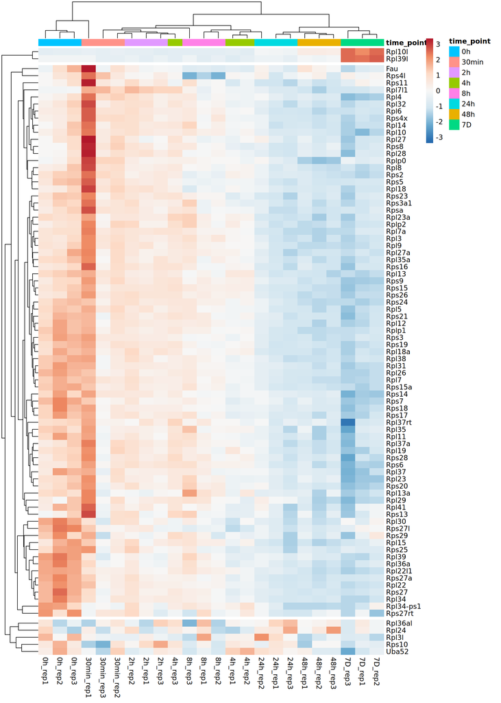

```r
mapped_manual <- tibble(
  UNIPROT = c("P86048", NA, NA, "Q9CQD0", "P62947", "P62702", "Q3V1Z5", "P62862"),
  SYMBOL = c("Rpl10l", "Rpl26-ps4", "Rpl36al", "Rpl39l", "Rpl41", "Rps4x", "Rps4l", "Fau"),
  MGI = paste0("MGI:", c("MGI:3647985", "MGI:3644695", "MGI:1913733", "MGI:1915422","MGI:1915195", "MGI:98158", "MGI:1913434", "MGI:102547"))
)

mapped_final <- bind_rows(mapped_mgi, mapped_manual) %>% dplyr::distinct(MGI, .keep_all = TRUE)
selected_mgi <- sub("MGI:", "", mapped_final$MGI)

mat <- all_counts_mor[rownames(all_counts_mor) %in% selected_mgi,
                      !grepl("WT", colnames(all_counts_mor))]

order_hclust <- function(hc, clust_mat) {

  if (nrow(clust_mat) == ncol(mat)) {

    colorder <- rep(c("0h", "30min", "2h", "4h", "8h", "24h", "48h", "7D"), each = 3)
    replicates <- paste0(rep("rep", 3), 1:3)
    labs <- expand.grid(colorder, replicates)
    labs <- paste(labs$Var1, labs$Var2, sep = "_")

    hc <- dendextend::rotate(hc, order = labs)
  }

  return(hc)

}

pheatmap(mat,
         scale = "row",
         clustering_callback = order_hclust,
         cutree_rows = 3,
         color = colorRampPalette(rev(brewer.pal(n = 7, name = "RdBu")))(100),
         border_color = NA,
         annotation_col = data.frame(
           row.names = colnames(mat),
           time_point = factor(sapply(strsplit(colnames(mat), "_"), `[`, 1),
                               levels = c("0h", "30min", "2h", "4h", "8h", "24h", "48h", "7D"))
           ),
         labels_row = mapped_final %>%
           mutate(MGI = sub("MGI:", "", MGI)) %>%
           filter(MGI %in% rownames(mat)) %>%
           arrange(match(MGI, rownames(mat))) %>%
           pull(SYMBOL))
```

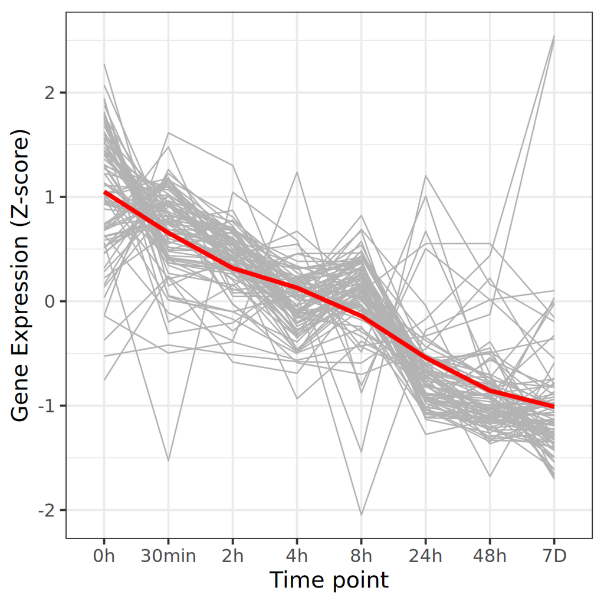

```r
dat <- t(scale(t(mat), center = rowMeans(mat), scale = rowSds(mat))) %>%
  as_tibble(rownames = "gene_id") %>%
  pivot_longer(cols = -gene_id) %>%
  mutate(tp = factor(sapply(strsplit(name, "_"), `[`, 1),
                     levels = c("0h", "30min", "2h", "4h", "8h", "24h", "48h", "7D")),
         replicate = as.numeric(sub("rep", "", sapply(strsplit(name, "_"), `[`, 2)))
  ) %>%
  group_by(
    gene_id,
    tp
  ) %>%
  summarize(
    expression = median(value)
  )

fit <- loess(expression ~ as.numeric(tp), data = dat)
j <- order(as.numeric(dat$tp))
regression <- data.frame(x = fit$x[j], y = fit$fitted[j], gene_id = "none")

p <- dat %>%
  ggplot(aes(tp, expression, group = gene_id)) +
  geom_line(color = "grey70") +
  geom_line(mapping = aes(x, y), data = regression, color = "red", linewidth = 1.5) +
  ylab("Gene Expression (Z-score)") +
  xlab("Time point") +
  theme_bw(base_size = 16) +
  theme(aspect.ratio = 1)

ggsave(
  filename = "figures/rpl_rps_hgnc_heatmap.pdf",
  plot = p,
  height = 6,
  width = 6
)

p
```

# Principal Component Analysis

Next we will perform Principal component analysis.

## All samples

We will compute PCA using all replicates from all samples across all time points. We will compute it on median-of-ratios normalized counts.

The plot shows a large contribution of time on PC1 and the genetic background emerge on PC2.

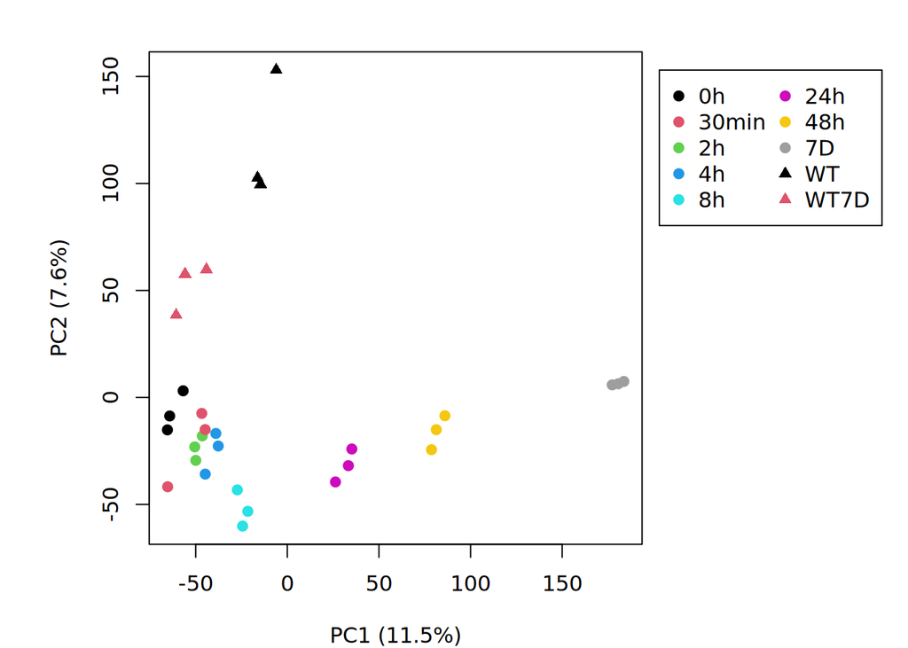

```r
do_pca <- function(mat, legend_labels) {
  pc <- prcomp(t(mat), center = TRUE, scale = TRUE)

  tp <- sapply(strsplit(colnames(mat), "_", fixed = TRUE), `[[`, 1)
  tp <- factor(tp, levels = legend_labels)
  colors <- as.numeric(tp)

  is_wt <- grepl("WT", colnames(mat))
  shape <- ifelse(is_wt, 17, 19)

  perc_sdev <- pc$sdev / sum(pc$sdev) * 100
  pc1 <- sprintf("PC1 (%.1f%%)", perc_sdev[1])
  pc2 <- sprintf("PC2 (%.1f%%)", perc_sdev[2])

  par(mar = c(4,4,2,8.5), pty = "s")
  plot(pc$x[,1], pc$x[,2], col = colors, pch = shape, xlab = pc1, ylab = pc2)
  lx <- ceiling(max(pc$x[,1])) + ceiling(max(pc$x[,1]) * 0.1)
  ly <- ceiling(max(pc$x[,2]))
  legend(x = lx, y = ly,
    legend = levels(tp),
    col = 1:length(levels(tp)),
    pch = ifelse(grepl("WT", levels(tp)), 17, 19),
    horiz = FALSE,
    ncol = 2,
    xpd = TRUE)
}

do_pca(all_counts_mor,
       legend_labels = c("0h", "30min", "2h",
                         "4h", "8h", "24h",
                         "48h", "7D", "WT",
                         "WT7D"))
```

## Without WT

We will explore how the median of ratios normalization affects PCA. We will go back to the raw counts, remove WT samples, re-run the median of ratios normalization and PCA.

The scatterplot of the first two components looks substantially different than previous iterations. The effect of time is spread in diagonal between PC1 and PC2.

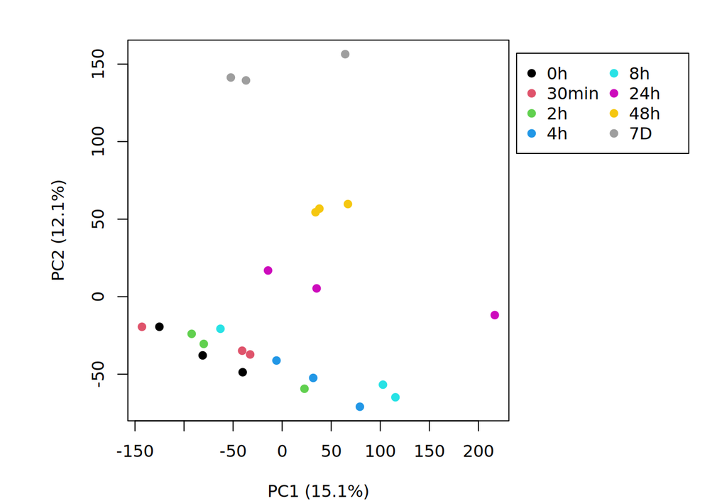

```r
mat <- all_counts
mat <- mat[,-grep("WT", colnames(mat))]
mat_mor <- mor(mat, return_coefficients = FALSE, do_rounding = FALSE)

do_pca(mat,
       legend_labels = c("0h", "30min", "2h", "4h", "8h", "24h", "48h", "7D"))
```

# Time-course analysis

We will start by median-of-ratios (mor) normalized counts and compute Z-scores. We will filter for genes with at least 50 mor-normalized read counts and with a variance value above the lower quartile value of the global variances distribution. We will compute Z-scores on this filtered gene expression matrix.

```r
colorder <- c("0h", "30min", "2h", "4h", "8h", "24h", "48h")

mat <- all_counts_mor[,-c(grep("7D", colnames(all_counts_mor)),
                          grep("WT", colnames(all_counts_mor)))]
mat <- mat[rowSums(mat) > 50,]
mat <- mat[rowVars(mat) > quantile(rowVars(mat), .25),]

# t0_median <- rowMedians(mat[,grep("0h", colnames(mat))])

norm_full <- t(scale(t(mat),
        center = rowMeans(mat),
        scale = rowSds(mat)))

as_matrix <- function(tbl) {
  rn <- tbl$gene_id
  mat <- as.matrix(tbl[,-which(colnames(tbl) == "gene_id")])
  rownames(mat) <- rn
  mat <- mat[,colorder]
  return(mat)
}

norm <- norm_full %>%
  as_tibble(rownames = "gene_id") %>%
  pivot_longer(
    cols = -gene_id,
    names_to = "sample",
    values_to = "expression"
  ) %>%
    mutate(time_point = sapply(str_split(sample, "_"), `[`, 1),
         replicate = sapply(str_split(sample, "_"), `[`, 2)) %>%
  group_by(gene_id, time_point) %>%
  summarize(expression = median(expression)) %>%
  pivot_wider(
    id_cols = gene_id,
    names_from = time_point,
    values_from = expression
  ) %>%
  as_matrix
```

Next, we will use the `Mclust` package to estimate the number of clusters to split the dataset into. The package tests for a range of models and `k` values (number of clusters). We will test partitioning the dataset into up to 200 clusters, ie. `k = 1:200`. For each couple (model, cluster), calculates the Bayesian Information Content (BIC) value. It then picks the couple that maximizes the BIC score.

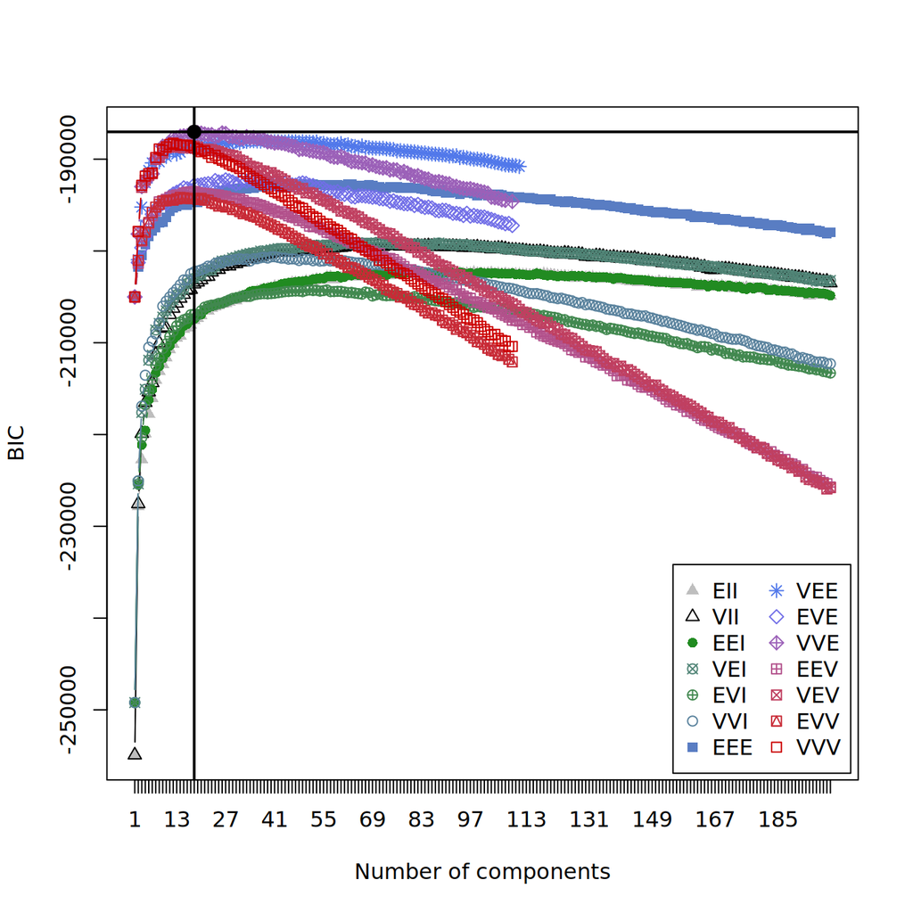

```r
k_max <- 200

d_clust <- Mclust(
  norm,
  G = 1:k_max,
  modelNames = mclust.options("emModelNames")
)

plot(d_clust, what = "BIC")
```

The best performing model is `VVE,18` (black dot in the plot above). This is a model using a multivariate Gaussian mixture model that uses ellipsoid kernels with equal orientations. We will proceed using the results from this clustering.

We will split our dataset in 18 clusters. On top of the genes we used to generate clusters, we will predict cluster assignment for all remaining genes.

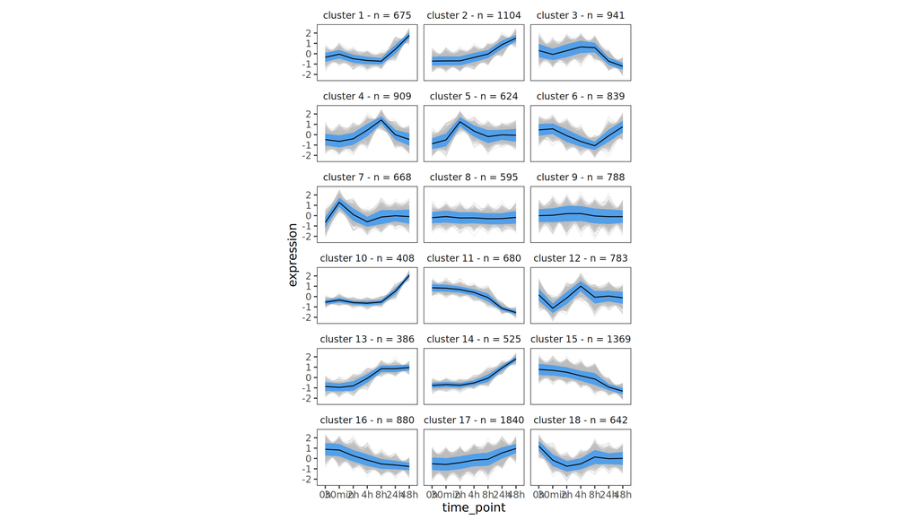

```r
ct <- d_clust$classification
ct <- data.frame(gene_id = names(ct), cluster = ct)

newdata <- norm[!rownames(norm) %in% ct$gene_id,]

res <- predict(d_clust, newdata)

ct <- rbind(ct,
            data.frame(
              gene_id = rownames(newdata),
              cluster = res$classification))

dat <- norm %>%
  as_tibble(rownames = "gene_id") %>%
  inner_join(ct) %>%
  pivot_longer(
    cols = -c(gene_id, cluster),
    names_to = "sample",
    values_to = "expression") %>%
  dplyr::rename(time_point = sample)

sds <- dat %>%
  group_by(time_point, cluster) %>%
  summarize(sd = sd(expression),
            expression = median(expression)) %>%
  mutate(gene_id = "none",
         sdmin = expression - sd,
         sdmax = expression + sd)

cluster_labels <- dat %>%
  group_by(cluster) %>%
  summarize(
    n = length(unique(gene_id))) %>%
  mutate(label = sprintf("cluster %d - n = %d", cluster, n)) %>%
  pull(label, name = cluster)

p <- dat %>%
  mutate(time_point = factor(time_point, levels = colorder)) %>%
  ggplot(aes(x = time_point, group = gene_id)) +
  geom_line(mapping =
              aes(y = expression),
            linewidth = 0.25,
            alpha = 0.33,
            color = "grey"
  ) +
  geom_ribbon(
    data = sds,
    mapping = aes(x = time_point, ymin = sdmin, ymax = sdmax),
    fill = "dodgerblue",
    alpha = 0.66
  ) +
  geom_line(
    data = sds,
    mapping = aes(x = time_point, y = expression),
    color = "black") +
  facet_wrap(~ cluster,
             labeller = labeller(cluster = cluster_labels),
             nrow = 6,
             ncol = 3) +
  theme_bw(base_size = 14) +
  theme(aspect.ratio = 9/16,

        panel.grid = element_blank(),
        strip.background = element_blank())

ggsave(filename = "figures/time_based_clustering.pdf",
       plot = p,
       height = 15,
       width = 7.5)

p
```

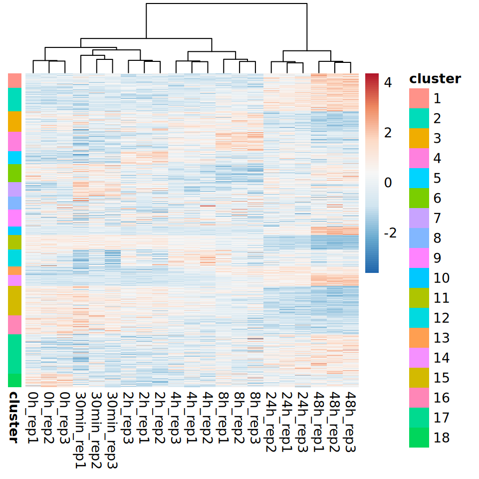

```r
rowann <- ct %>%
  arrange(cluster, .keep_all = TRUE) %>%
  filter(gene_id %in% rownames(norm_full))

x <- norm_full[match(rowann$gene_id, rownames(norm_full)),]

order_hclust <- function(hc, clust_mat) {
  if (nrow(clust_mat) == ncol(mat)) {
    colorder <- rep(c("0h", "30min", "2h", "4h", "8h", "24h", "48h"), each = 3)
    replicates <- paste0(rep("rep", 3), 1:3)
    labs <- expand.grid(colorder, replicates)
    labs <- paste(labs$Var1, labs$Var2, sep = "_")
    hc <- dendextend::rotate(hc, order = labs)
  }
  return(hc)
}

pheatmap(
  x,
  cluster_rows = FALSE,
  clustering_method = "ward.D",
  color = colorRampPalette(rev(brewer.pal(n = 7, name =
  "RdBu")))(100),
  scale = "none",
  annotation_row = rowann %>% dplyr::select(-gene_id) %>% mutate(cluster = as.factor(cluster)),
  show_rownames = FALSE,
  clustering_callback = order_hclust
)
```

We will proceed to characterize these clusters with GO enrichment.

# Gene Ontology Enrichment Analysis

## Clusters from time course analysis

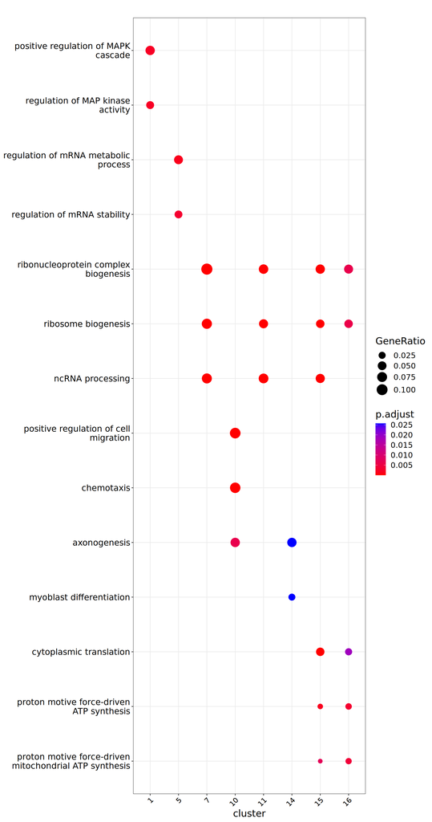

```r
time_based_clusters <- ct %>%
  as_tibble() %>%
  dplyr::mutate(gene_id = paste0("MGI:", gene_id))

universe <- rownames(all_counts_mor) %>%
  paste0("MGI:", .)

ck_time_course_clustering <- compareCluster(gene_id ~ cluster,
                     data = time_based_clusters,
                     fun = enrichGO,
                     OrgDb = 'org.Mm.eg.db',
                     keyType = "MGI",
                     ont = "BP",
                     universe = universe,
                     minGSSize = 15)

ck_time_course_clustering <- setReadable(ck_time_course_clustering, OrgDb = org.Mm.eg.db, keyType = "MGI")

p <- dotplot(ck_time_course_clustering,
        x = "cluster",
        showCategory = 2) +
  scale_x_discrete(limits = c("1", "5",
                              "7", "10",
                              "11", "14",
                              "15", "16")) +
  theme(axis.text.x = element_text(angle = 45, hjust = 1),
        text = element_text(size=16),
        axis.title = element_text(size=16),
        axis.text.y = element_text(size=14))

ggsave(filename = "figures/GO_enrichment_time_course.pdf",
       plot = p,
       height = 19,
       width = 10)

p
```

Tables below report enriched GO terms for each cluster separately.

#### Cluster 1

| Cluster | Description | Generatio | Bgratio | Adjusted p-value | Geneid | Count |
| --- | --- | --- | --- | --- | --- | --- |
| 1 | positive regulation of MAPK cascade | 38/611 | 394/15144 | 2.1e-03 | Ptk2b/Ackr3/Nrxn1/Tpd52l1/Sema7a/Mapk8ip1/Tnfrsf11a/Pak1/Aju…… | 38 |
| 1 | regulation of MAP kinase activity | 22/611 | 168/15144 | 2.1e-03 | Ptk2b/Sfrp2/Tpd52l1/Mapk8ip1/Tnfrsf11a/Pak1/Ajuba/Nox4/Pdgfc/Lrrk2/Sash1/Dusp10/Fgd4/Trib1/Pik3r5/Cbs/Egfr/Gba/Ghr/Mif/Pdgfa/Prkcd | 22 |
| 1 | regulation of ossification | 17/611 | 115/15144 | 4.5e-03 | Ptk2b/Smad3/Adgrv1/Fzd9/Dhrs3/Creb3l1/Rflnb/Pkdcc/Bmp2k/Cd276/Lrp4/Intu/Ank/Acvr1/Dlk1/Srgn/Thrb | 17 |
| 1 | skeletal system development | 39/611 | 455/15144 | 6.2e-03 | Fmn1/Alx1/Has2/Sfrp2/Smad3/Mmp16/Nsd2/Cited2/Dhrs3/Matn3/Efe…… | 39 |
| 1 | positive regulation of MAP kinase activity | 16/611 | 110/15144 | 6.2e-03 | Ptk2b/Tpd52l1/Tnfrsf11a/Pak1/Ajuba/Nox4/Pdgfc/Lrrk2/Sash1/Fgd4/Pik3r5/Egfr/Ghr/Mif/Pdgfa/Prkcd | 16 |
| 1 | JNK cascade | 19/611 | 150/15144 | 6.2e-03 | Mdfic/Ptk2b/Sfrp2/Smad3/Tpd52l1/Mapk8ip1/Gadd45g/Casr/Tnfrsf19/Lrrk2/Dusp10/Ankrd6/Irak4/Fgd4/Map3k20/Trib1/Sh3rf2/Sfrp4/Egfr | 19 |
| 1 | negative regulation of growth | 24/611 | 226/15144 | 8.3e-03 | Serpine2/Ntn1/Sox17/Sema3c/Sfrp2/Ei24/Fgf13/Smad3/Wwc2/Cited2/Sema7a/Slit1/Cth/Pak1/Foxp1/Dusp10/Tro/Wwc1/Vgll4/Prdm11/Adrb3/Fbp1/Gas1/Rb1 | 24 |
| 1 | ossification | 30/611 | 326/15144 | 1.1e-02 | Tgfbr3/Ptk2b/Ppp3ca/Sfrp2/Jag1/Smad3/Adgrv1/Mmp16/Fzd9/Tnfrsf11a/Dhrs3/Creb3l1/Casr/Pdlim7/Igsf10/Rflnb/Pkdcc/Bmp2k/Cd276/Lrp4/Intu/Ank/Acvr1/Cbs/Col1a2/Dlk1/Fgfr2/Igfbp3/Srgn/Thrb | 30 |
| 1 | stress-activated MAPK cascade | 22/611 | 203/15144 | 1.1e-02 | Mdfic/Ptk2b/Sfrp2/Mapkapk2/Smad3/Tpd52l1/Mapk8ip1/Gadd45g/Casr/Tnfrsf19/Lrrk2/Sash1/Dusp10/Ankrd6/Irak4/Fgd4/Map3k20/Trib1/Sh3rf2/Sfrp4/Egfr/Ezr | 22 |
| 1 | presynapse organization | 9/611 | 43/15144 | 1.6e-02 | Efnb1/Gpc4/Snap91/Nrxn1/Bsn/Cadm1/Lrp4/Farp1/Slitrk5 | 9 |

[output cut: 13 more lines]

#### Cluster 5

| Cluster | Description | Generatio | Bgratio | Adjusted p-value | Geneid | Count |
| --- | --- | --- | --- | --- | --- | --- |
| 5 | regulation of mRNA metabolic process | 29/546 | 282/15144 | 1.4e-03 | Ddx5/Larp4b/Rbm3/Tbrg4/Dyrk1a/Fus/Srrm1/Srsf4/Syncrip/Rbm25/Srsf6/Fastkd3/Tent4b/Dcp2/Ythdf3/Brf1/Dcp1a/Wtap/Pum1/Alkbh5/Cnot6/Tnrc6a/Zc3h12a/Thrap3/Ago2/Tent4a/Cirbp/Srsf2/Son | 29 |
| 5 | regulation of mRNA stability | 19/546 | 149/15144 | 3.1e-03 | Larp4b/Tbrg4/Fus/Syncrip/Fastkd3/Tent4b/Dcp2/Ythdf3/Brf1/Dcp1a/Pum1/Alkbh5/Cnot6/Tnrc6a/Zc3h12a/Thrap3/Ago2/Tent4a/Cirbp | 19 |
| 5 | mRNA catabolic process | 23/546 | 221/15144 | 5.2e-03 | Ddx5/Larp4b/Tbrg4/Gspt2/Fus/Syncrip/Fastkd3/Tent4b/Dcp2/Ythdf3/Brf1/Dcp1a/Pum1/Alkbh5/Cnot6/Tnrc6a/Zc3h12a/Thrap3/Ago2/Smg5/Tent4a/Smg7/Cirbp | 23 |
| 5 | regulation of RNA stability | 19/546 | 162/15144 | 5.2e-03 | Larp4b/Tbrg4/Fus/Syncrip/Fastkd3/Tent4b/Dcp2/Ythdf3/Brf1/Dcp1a/Pum1/Alkbh5/Cnot6/Tnrc6a/Zc3h12a/Thrap3/Ago2/Tent4a/Cirbp | 19 |
| 5 | regulation of mRNA catabolic process | 19/546 | 164/15144 | 5.2e-03 | Larp4b/Tbrg4/Fus/Syncrip/Fastkd3/Tent4b/Dcp2/Ythdf3/Brf1/Dcp1a/Pum1/Alkbh5/Cnot6/Tnrc6a/Zc3h12a/Thrap3/Ago2/Tent4a/Cirbp | 19 |
| 5 | histone modification | 35/546 | 440/15144 | 6.1e-03 | Atf2/Kdm6a/Epc2/Epc1/Taf1/Baz1b/Kdm2a/Kat6b/Lpin1/Meaf6/Ubr5…… | 35 |
| 5 | regulation of RNA splicing | 19/546 | 173/15144 | 8.0e-03 | Ddx5/Clk4/Cdk12/Rbm3/Ahnak/Dyrk1a/Fus/Srrm1/Srsf4/Rbm25/Srsf6/Rbm12/Wtap/Thrap3/Setx/Cirbp/Srsf2/Srsf5/Son | 19 |
| 5 | positive regulation of cellular catabolic process | 31/546 | 382/15144 | 1.0e-02 | Gclc/Pten/Arih2/Esrrb/Rnf19a/Csnk1d/Wdr45/Gsk3b/Foxo3/Syncrip/Mtdh/Socs4/Rchy1/Tent4b/Dcp2/Ankib1/Ythdf3/Dcp1a/Pum1/Sirt1/Zfand2a/Cnot6/Tnrc6a/Zc3h12a/Wac/Snx30/Smcr8/Ago2/Tent4a/Htt/Ldlr | 31 |
| 5 | regulation of ubiquitin-dependent protein catabolic process | 17/546 | 155/15144 | 1.8e-02 | Gclc/Pten/Lats1/Arih2/Tlk2/Rnf19a/Csnk1d/Gsk3b/Socs4/Rchy1/Bag5/Ankib1/N4bp1/Zfand2a/Usp7/Wac/Csnk2a1 | 17 |
| 5 | mRNA processing | 33/546 | 442/15144 | 2.3e-02 | Prpf39/Ddx5/Prpf4b/Cdk12/Rbm3/Tbrg4/Dyrk1a/Srrm1/Ddx20/Gpkow…… | 33 |

[output cut: 15 more lines]

#### Cluster 7

| Cluster | Description | Generatio | Bgratio | Adjusted p-value | Geneid | Count |
| --- | --- | --- | --- | --- | --- | --- |
| 7 | ribonucleoprotein complex biogenesis | 62/578 | 406/15144 | 1.4e-17 | Ddx3x/Zrsr2/Xrcc5/Mybbp1a/Imp4/Lsg1/Lyar/Usp39/Nop16/Clns1a/…… | 62 |
| 7 | ribosome biogenesis | 47/578 | 292/15144 | 6.6e-14 | Ddx3x/Xrcc5/Mybbp1a/Imp4/Lsg1/Lyar/Nop16/C1qbp/Eif6/Sart1/Ra…… | 47 |
| 7 | rRNA metabolic process | 37/578 | 245/15144 | 8.4e-10 | Imp4/Lyar/Polr1a/Eif6/Sart1/Smarcb1/Exosc10/Bysl/Ftsj3/Ddx21…… | 37 |
| 7 | mRNA processing | 51/578 | 442/15144 | 1.4e-09 | Zrsr2/Fxr1/Tra2b/Grsf1/Usp39/Larp7/Hnrnpc/Sf1/Clns1a/C1qbp/A…… | 51 |
| 7 | rRNA processing | 32/578 | 212/15144 | 1.9e-08 | Imp4/Lyar/Eif6/Sart1/Exosc10/Bysl/Ftsj3/Ddx21/Rsl1d1/Rrp8/Pwp1/Mettl16/Ddx47/Brix1/Nop9/Nifk/Mphosph6/Nol11/Gtpbp4/Pin4/Znhit6/Rpf1/Wdr36/Utp3/Wdr43/Wdr75/Exosc4/Ddx52/Rrs1/Mrpl1/Pa2g4/Ncl | 32 |
| 7 | ncRNA processing | 45/578 | 390/15144 | 2.0e-08 | Ddx3x/Grsf1/Imp4/Lyar/Larp7/Tsn/Eif6/Sart1/Exosc10/Bysl/Ftsj…… | 45 |
| 7 | RNA splicing, via transesterification reactions | 35/578 | 260/15144 | 3.3e-08 | Zrsr2/Fxr1/Tra2b/Usp39/Larp7/Sf1/Clns1a/C1qbp/Aqr/Sf3b3/Dhx8…… | 35 |
| 7 | RNA splicing, via transesterification reactions with bulged adenosine as nucleophile | 35/578 | 260/15144 | 3.3e-08 | Zrsr2/Fxr1/Tra2b/Usp39/Larp7/Sf1/Clns1a/C1qbp/Aqr/Sf3b3/Dhx8…… | 35 |
| 7 | mRNA splicing, via spliceosome | 35/578 | 260/15144 | 3.3e-08 | Zrsr2/Fxr1/Tra2b/Usp39/Larp7/Sf1/Clns1a/C1qbp/Aqr/Sf3b3/Dhx8…… | 35 |
| 7 | RNA splicing | 44/578 | 399/15144 | 8.9e-08 | Zrsr2/Fxr1/Tra2b/Grsf1/Usp39/Larp7/Hnrnpc/Sf1/Clns1a/C1qbp/A…… | 44 |

[output cut: 83 more lines]

#### Cluster 10

| Cluster | Description | Generatio | Bgratio | Adjusted p-value | Geneid | Count |
| --- | --- | --- | --- | --- | --- | --- |
| 10 | positive regulation of cell migration | 36/385 | 475/15144 | 9.9e-06 | Reln/Pdpn/Cxcl12/Ptprj/Epha1/Smo/Lpar1/Amot/Fzd4/Dab2/Pik3cd… | 36 |
| 10 | chemotaxis | 34/385 | 439/15144 | 9.9e-06 | Reln/Cxcl12/Ptprj/Efnb2/Epha1/Plxna2/Plxna1/Smo/Lpar1/Amot/St6gal1/Matn2/Pik3cd/Sema6a/Enpp2/Foxd1/Stk39/Vav3/Lmx1a/Trio/Kalrn/Mcu/App/Bdnf/Dpp4/Flt1/Hspb1/Cd74/Anxa1/Lyn/Met/Syk/Lama3/Lamb2 | 34 |
| 10 | taxis | 34/385 | 440/15144 | 9.9e-06 | Reln/Cxcl12/Ptprj/Efnb2/Epha1/Plxna2/Plxna1/Smo/Lpar1/Amot/St6gal1/Matn2/Pik3cd/Sema6a/Enpp2/Foxd1/Stk39/Vav3/Lmx1a/Trio/Kalrn/Mcu/App/Bdnf/Dpp4/Flt1/Hspb1/Cd74/Anxa1/Lyn/Met/Syk/Lama3/Lamb2 | 34 |
| 10 | positive regulation of cell motility | 36/385 | 492/15144 | 1.1e-05 | Reln/Pdpn/Cxcl12/Ptprj/Epha1/Smo/Lpar1/Amot/Fzd4/Dab2/Pik3cd… | 36 |
| 10 | positive regulation of cell adhesion | 30/385 | 390/15144 | 5.1e-05 | Pdpn/Cxcl12/Ptprj/Cd55/Efnb2/Epha1/Dab2/Enpp2/Vav3/Carmil1/Unc13d/Dock8/Egflam/Npnt/Pawr/Frmd5/B2m/Dpp4/H2-Eb1/Cd74/Jak2/Lamb1/Anxa1/Pcsk5/Prkce/Spta1/Tek/Syk/Lamc1/Lamb2 | 30 |
| 10 | substrate adhesion-dependent cell spreading | 14/385 | 101/15144 | 1.5e-04 | Pdpn/Epha1/St6gal1/Fzd4/Dab2/Enpp2/Carmil1/Unc13d/Ntng2/Lamb1/Tek/Lamc1/Lamb3/Lamb2 | 14 |
| 10 | negative regulation of cell adhesion | 22/385 | 251/15144 | 2.4e-04 | Cxcl12/Cdkn2a/Plxna2/Plxna1/Fzd4/Sftpd/Sema6a/Cask/Enpp2/Pde3b/Ubash3b/Adtrp/Pawr/Tnfrsf21/Btla/Bmp6/Hspb1/Cd74/Jak2/Lamb1/Anxa1/Mmp2 | 22 |
| 10 | urogenital system development | 24/385 | 307/15144 | 5.0e-04 | Stat1/Efnb2/Aldh1a2/Cited1/Smo/Serpinf1/Prom1/Foxd1/Wwtr1/Ptk7/Anks6/Npnt/Fras1/Bdnf/Bmp6/Cfh/Col4a1/Fbn1/Id2/Anxa1/Mmp2/Pcsk5/Tek/Lamb2 | 24 |
| 10 | positive regulation of cysteine-type endopeptidase activity | 14/385 | 118/15144 | 6.9e-04 | Stat1/Cdkn2a/Slc1a1/Casp8/Apaf1/Asph/Dap/Arl6ip5/Pawr/App/D1Pas1/Gsn/Jak2/Syk | 14 |
| 10 | regulation of cell-substrate adhesion | 18/385 | 195/15144 | 7.5e-04 | Pdpn/Ptprj/Cdkn2a/Epha1/St6gal1/Fzd4/Dab2/Onecut1/Cask/Enpp2/Carmil1/Unc13d/Egflam/Npnt/Jak2/Pcsk5/Prkce/Tek | 18 |

[output cut: 322 more lines]

#### Cluster 11

| Cluster | Description | Generatio | Bgratio | Adjusted p-value | Geneid | Count |
| --- | --- | --- | --- | --- | --- | --- |
| 11 | ncRNA processing | 47/663 | 390/15144 | 1.0e-06 | Rpl5/Rrp1/Rps19/Mettl1/Rpl10a/Rpp40/Map2k2/Exosc9/Rpp30/Wdr4…… | 47 |
| 11 | ribosome biogenesis | 37/663 | 292/15144 | 1.0e-05 | Rpl5/Rrp1/Rps19/Rpl10a/Rpp40/Exosc9/Rpp30/Nom1/Eral1/Wbp11/M…… | 37 |
| 11 | rRNA metabolic process | 33/663 | 245/15144 | 1.0e-05 | Rpl5/Rrp1/Rps19/Rpl10a/Rpp40/Exosc9/Rpp30/Wbp11/Eri1/Mphosph10/Ebna1bp2/Tsr2/Cd3eap/Ddx54/Shq1/Utp14a/Dis3/Nop14/Ippk/Ddx10/Lsm6/Gar1/Wdr46/Nol6/Nsun5/Urb1/Tfb1m/Helb/Eri3/Rrp9/Rps15/Rps24/Trp53 | 33 |
| 11 | rRNA processing | 30/663 | 212/15144 | 1.2e-05 | Rpl5/Rrp1/Rps19/Rpl10a/Rpp40/Exosc9/Rpp30/Wbp11/Eri1/Mphosph10/Ebna1bp2/Tsr2/Ddx54/Shq1/Utp14a/Dis3/Nop14/Ddx10/Lsm6/Gar1/Wdr46/Nol6/Nsun5/Urb1/Tfb1m/Helb/Eri3/Rrp9/Rps15/Rps24 | 30 |
| 11 | ribonucleoprotein complex biogenesis | 43/663 | 406/15144 | 5.5e-05 | Rpl5/Sf3a2/Smn1/Rrp1/Rps19/Eif4h/Rpl10a/Rpp40/Prmt5/Exosc9/R…… | 43 |
| 11 | tRNA processing | 17/663 | 118/15144 | 8.8e-03 | Mettl1/Rpp40/Rpp30/Wdr4/Elp2/Elac2/Thg1l/Tsen15/Polr3k/Trnt1/Trub1/Trmt5/Lsm6/Ctu1/Trmt61a/Thumpd1/Aars2 | 17 |
| 11 | chromosome organization | 42/663 | 496/15144 | 1.7e-02 | Mcm3/Recql/Cct7/Kpnb1/Ezh2/Nek2/H3f3a/Mre11a/Ttk/Zwint/Incen…… | 42 |
| 11 | tRNA metabolic process | 20/663 | 170/15144 | 2.5e-02 | Mettl1/Rpp40/Exosc9/Rpp30/Wdr4/Elp2/Elac2/Lars/Thg1l/Tsen15/Polr3k/Qars/Trnt1/Trub1/Trmt5/Lsm6/Ctu1/Trmt61a/Thumpd1/Aars2 | 20 |
| 11 | chromosome segregation | 32/663 | 353/15144 | 3.3e-02 | Kpnb1/Nek2/Mre11a/Ttk/Zwint/Incenp/Bcl7b/Smc1a/Ik/Cdc20/Chmp7/Ube2c/Syde1/Fam83d/Pinx1/Cdca2/Nup37/Chmp1a/Uvrag/Cenpk/Ppp2r1a/Rec8/Kat5/Ncapd3/Recql5/Dlgap5/Dis3l2/Brip1/Kif18b/Meioc/Ccne1/Top2a | 32 |
| 11 | branched-chain amino acid catabolic process | 6/663 | 20/15144 | 4.6e-02 | Dld/Bckdk/Aldh6a1/Ivd/Acat1/Bckdhb | 6 |

[output cut: 12 more lines]

#### Cluster 14

| Cluster | Description | Generatio | Bgratio | Adjusted p-value | Geneid | Count |
| --- | --- | --- | --- | --- | --- | --- |
| 14 | axonogenesis | 31/505 | 410/15144 | 2.6e-02 | Skil/Rufy3/Myo5b/Sema5a/Enah/Fzd3/Dab1/Bmpr2/Ephb6/Ece1/Robo1/Map1b/Slit3/Cyfip1/Sema3e/Zeb2/Pla2g10/Shtn1/Stxbp5/Spg20/Boc/Mycbp2/Sipa1l1/Unc5a/Fn1/Lrp2/Igf1r/Nefh/Prkca/Cdh4/Ephb2 | 31 |
| 14 | myoblast differentiation | 12/505 | 84/15144 | 2.6e-02 | Gpx1/Epas1/Map3k5/Prickle1/Cdon/Boc/Plekhm3/Mbnl3/Mkx/Nrg1/Smarca2/Zfhx3 | 12 |
| 14 | axon development | 33/505 | 453/15144 | 2.6e-02 | Skil/Rufy3/Myo5b/Sema5a/Enah/Fzd3/Dab1/Bmpr2/Ephb6/Ece1/Robo1/Map1b/Slit3/Cyfip1/Sema3e/Zeb2/Pla2g10/Shtn1/Stxbp5/Spg20/Boc/Mycbp2/Sipa1l1/Mtr/Unc5a/Fn1/Lrp2/Nrg1/Igf1r/Nefh/Prkca/Cdh4/Ephb2 | 33 |
| 14 | positive regulation of axon extension | 9/505 | 49/15144 | 2.6e-02 | Rufy3/Myo5b/Sema5a/Bmpr2/Map1b/Cyfip1/Shtn1/Fn1/Cdh4 | 9 |
| 14 | regulation of axonogenesis | 17/505 | 165/15144 | 2.6e-02 | Skil/Rufy3/Myo5b/Sema5a/Dab1/Bmpr2/Robo1/Map1b/Cyfip1/Sema3e/Zeb2/Shtn1/Spg20/Sipa1l1/Fn1/Cdh4/Ephb2 | 17 |
| 14 | positive regulation of axonogenesis | 12/505 | 90/15144 | 2.6e-02 | Skil/Rufy3/Myo5b/Sema5a/Bmpr2/Robo1/Map1b/Cyfip1/Zeb2/Shtn1/Fn1/Cdh4 | 12 |
| 14 | small GTPase mediated signal transduction | 29/505 | 393/15144 | 2.6e-02 | Bcl6/Dab1/Robo1/Dgkz/Dok2/Cyfip1/Dock4/Shtn1/Arhgef3/Rnd3/Dock11/Cdon/Nisch/Uso1/Arl3/Setdb1/Cdc42bpa/Dgki/Sipa1l1/Dock5/Akap13/Ralgapa2/Syde2/Iqsec2/Bcr/Nrg1/Notch2/Sos2/Ephb2 | 29 |
| 14 | positive regulation of nervous system development | 24/505 | 296/15144 | 2.6e-02 | Atxn1/Skil/Rufy3/Myo5b/Sema5a/Bin1/Fzd3/Bmpr2/Dll3/Robo1/Map1b/Cyfip1/Zeb2/Shtn1/Adgrl1/Adgrl2/Tenm4/Cux1/Fn1/Lrp2/Nrg1/Prkca/Cdh4/Ephb2 | 24 |

#### Cluster 15

| Cluster | Description | Generatio | Bgratio | Adjusted p-value | Geneid | Count |
| --- | --- | --- | --- | --- | --- | --- |
| 15 | cytoplasmic translation | 57/1283 | 141/15144 | 1.3e-21 | Rps2/Rpsa/Rpl26/Rpl6/Nck1/Rps5/Rps3a1/Rpl21/Rpl9/Rps17/Rpl27…… | 57 |
| 15 | ribonucleoprotein complex biogenesis | 79/1283 | 406/15144 | 3.0e-09 | Nup88/Rps2/Rpsa/Rpl10/Rpl26/Npm1/Atr/Rpl6/Rps5/Nhp2/Abce1/Kr…… | 79 |
| 15 | ncRNA processing | 75/1283 | 390/15144 | 1.4e-08 | Stat3/Rpl26/Npm1/Spout1/Nsun2/Nhp2/Thumpd3/Krr1/Rps17/Hsd17b…… | 75 |
| 15 | ribosome biogenesis | 58/1283 | 292/15144 | 6.6e-07 | Nup88/Rps2/Rpsa/Rpl10/Rpl26/Npm1/Rpl6/Rps5/Nhp2/Abce1/Krr1/R…… | 58 |
| 15 | ribonucleoprotein complex assembly | 37/1283 | 165/15144 | 2.5e-05 | Rps2/Rpsa/Rpl10/Atr/Rpl6/Rps5/Prkra/Eif2s3x/Lsm4/Rps28/Rps27…… | 37 |
| 15 | ribonucleoprotein complex subunit organization | 38/1283 | 173/15144 | 2.5e-05 | Rps2/Rpsa/Rpl10/Atr/Rpl6/Rps5/Prkra/Eif2s3x/Lsm4/Rps28/Rps27…… | 38 |
| 15 | rRNA metabolic process | 47/1283 | 245/15144 | 4.9e-05 | Rpl26/Npm1/Taf1b/Nhp2/Krr1/Rps17/Mars1/Macroh2a1/Rpl7a/Rps28…… | 47 |
| 15 | rRNA processing | 42/1283 | 212/15144 | 8.3e-05 | Rpl26/Npm1/Nhp2/Krr1/Rps17/Rpl7a/Rps28/Rps27/Rcl1/Bud23/Nop1…… | 42 |
| 15 | ribosomal large subunit biogenesis | 20/1283 | 68/15144 | 2.2e-04 | Rpl10/Rpl26/Npm1/Rpl6/Nhp2/Rpl7a/Rpl7l1/Rpl35/Nsa2/Rpl11/Rpl14/Rpl38/Rplp0/Rpl35a/Wdr74/Nop53/Ppan/Rpl23a/Traf7/Rpl7 | 20 |
| 15 | chromosome organization | 75/1283 | 496/15144 | 2.2e-04 | Mlh1/Mcm4/Nudc/Smc2/Sin3a/Cct5/Cct2/Atr/Sycp3/Kif11/Nhp2/Psm…… | 75 |

[output cut: 53 more lines]

#### Cluster 16

| Cluster | Description | Generatio | Bgratio | Adjusted p-value | Geneid | Count |
| --- | --- | --- | --- | --- | --- | --- |
| 16 | proton motive force-driven ATP synthesis | 14/738 | 60/15144 | 3.1e-03 | Atp5g1/Ndufs6/Ndufc2/Ndufb5/Sdhc/Ndufa12/Sdhd/Ndufa13/Ndufa5/Ndufa8/Ndufab1/Ndufv2/Ndufs8/Ndufb1 | 14 |
| 16 | proton motive force-driven mitochondrial ATP synthesis | 13/738 | 56/15144 | 4.0e-03 | Ndufs6/Ndufc2/Ndufb5/Sdhc/Ndufa12/Sdhd/Ndufa13/Ndufa5/Ndufa8/Ndufab1/Ndufv2/Ndufs8/Ndufb1 | 13 |
| 16 | oxidative phosphorylation | 19/738 | 121/15144 | 5.7e-03 | Uqcrq/Ndufs6/Shmt2/Ndufc2/Ndufb5/Sdhc/Ndufa12/Uqcr11/Sdhd/Ndufa13/Ndufa5/Ndufa8/Tefm/Ndufab1/Ndufv2/Ndufs8/Ndufb1/Cox5b/Cyct | 19 |
| 16 | ribosome biogenesis | 33/738 | 292/15144 | 5.7e-03 | Gtf2h5/Rps7/Pes1/Nip7/Exosc3/Exosc1/Riok3/Rpf2/Trmt112/Rps27…… | 33 |
| 16 | ribonucleoprotein complex biogenesis | 41/738 | 406/15144 | 6.1e-03 | Prpf19/Gtf2h5/Snrpc/Rps7/Pes1/Nip7/Exosc3/Exosc1/Riok3/Ramac…… | 41 |
| 16 | aerobic electron transport chain | 11/738 | 47/15144 | 7.5e-03 | Uqcrq/Ndufs6/Ndufc2/Sdhc/Uqcr11/Sdhd/Ndufa8/Ndufv2/Ndufs8/Cox5b/Cyct | 11 |
| 16 | ATP synthesis coupled electron transport | 12/738 | 59/15144 | 1.0e-02 | Uqcrq/Ndufs6/Ndufc2/Sdhc/Ndufa12/Uqcr11/Sdhd/Ndufa8/Ndufv2/Ndufs8/Cox5b/Cyct | 12 |
| 16 | mitochondrial ATP synthesis coupled electron transport | 12/738 | 59/15144 | 1.0e-02 | Uqcrq/Ndufs6/Ndufc2/Sdhc/Ndufa12/Uqcr11/Sdhd/Ndufa8/Ndufv2/Ndufs8/Cox5b/Cyct | 12 |
| 16 | respiratory electron transport chain | 14/738 | 79/15144 | 1.0e-02 | Etfa/Uqcrq/Ndufs6/Ndufc2/Sdhc/Ndufa12/Uqcr11/Sdhd/Ndufa5/Ndufa8/Ndufv2/Ndufs8/Cox5b/Cyct | 14 |
| 16 | aerobic respiration | 21/738 | 164/15144 | 1.8e-02 | Uqcrq/Ndufs6/Shmt2/Ndufc2/Ndufb5/Sdhc/Ndufa12/Uqcr11/Sdhd/Ndufa13/Ndufa5/Ndufa8/Tefm/Ndufab1/Cox10/Ndufv2/Mtfr1l/Ndufs8/Ndufb1/Cox5b/Cyct | 21 |

[output cut: 13 more lines]

We will focus on clusters 7, 11, 15 and 16 that contain genes annotated to ribosome function, assembly and biogenesis.

We will produce a plot to show how genes belonging to these clusters share GO terms annotations.

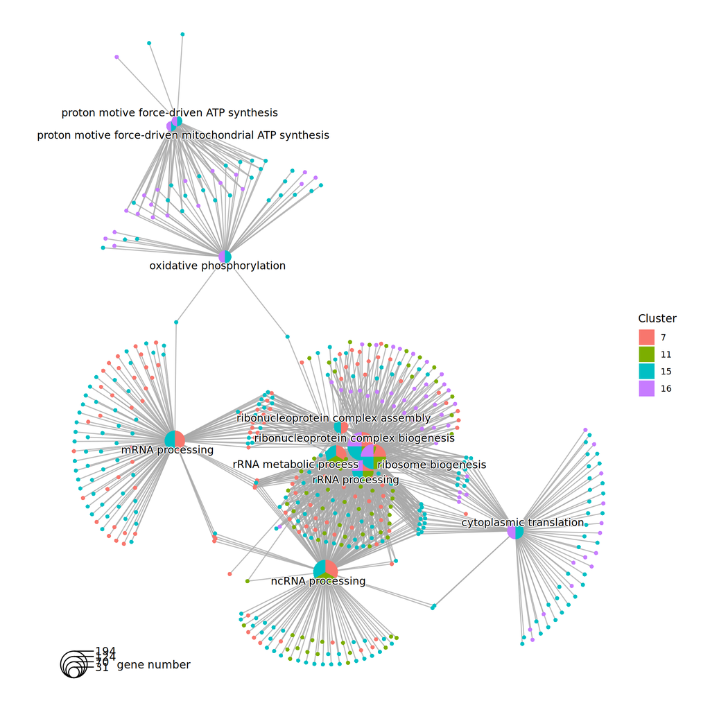

```r
p <- ck_time_course_clustering %>%
  filter(cluster %in% c(7, 11, 15, 16)) %>%
  cnetplot(
    node_label = "category",
    layout = "kk",
    cex.params = list(
      category_node = 1.5,
      category_label = 1.5
    )
  )

ggsave(filename = "figures/cnetplot_time_based_clustering.pdf",
       plot = p,
       width = 10,
       height = 10)

p
```

We will also dig a bit deeper into the terms enriched in these clusters by producing a plot to show how these gene clusters share GO terms.

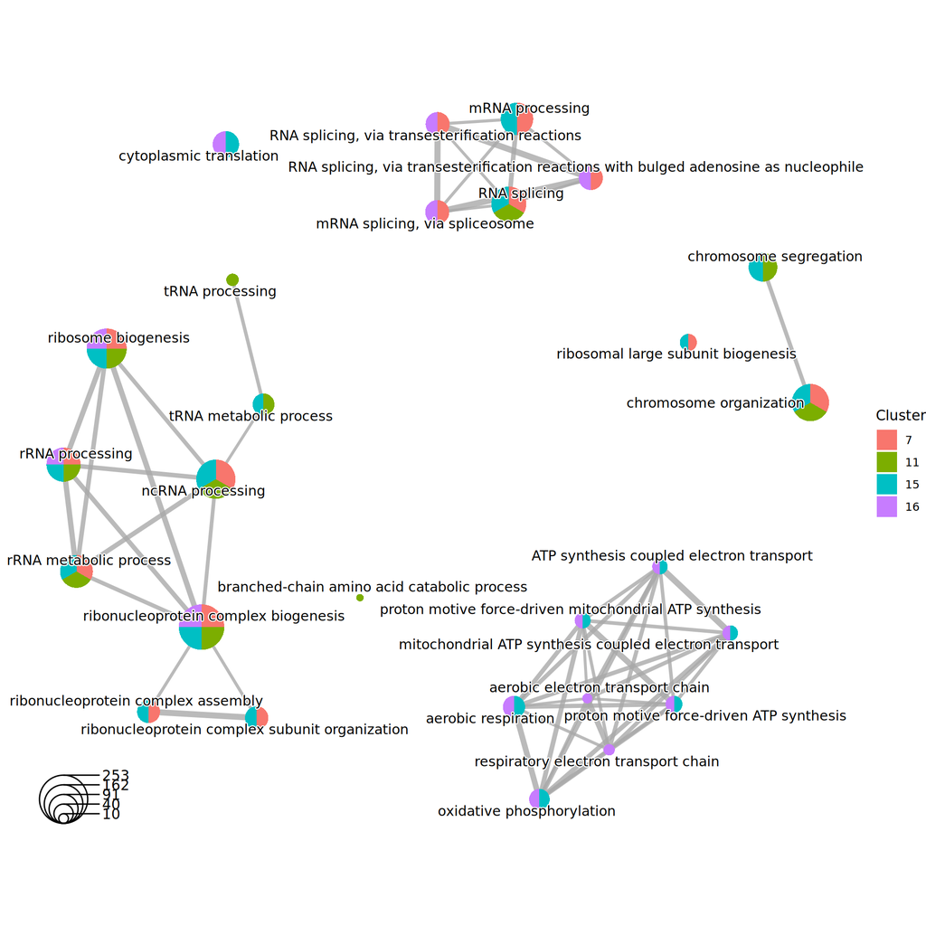

```r
ts <- pairwise_termsim(
  ck_time_course_clustering %>%
    filter(cluster %in% c(7, 11, 15, 16))
  )

p <- emapplot(
  ts,
  showCategory = 10,
  layout.params = list(layout = "kk"),
  cex.params = list(
    category_node = .5,
    category_label = 1.25
  ))

ggsave(filename = "figures/emapplot_time_based_clustering.pdf",
       plot = p,
       height = 10,
       width = 10)

p
```

## Pairwise comparisons

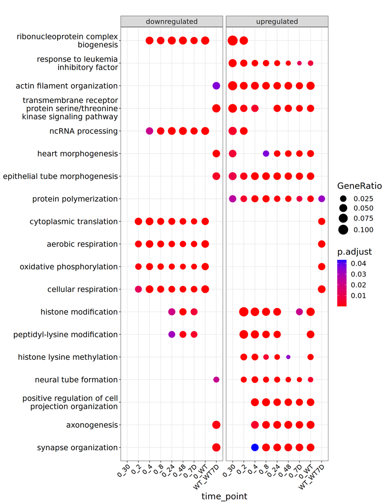

```r
clusters <- all_deg %>%
  dplyr::filter(deg) %>%
  dplyr::mutate(gene_id = paste0("MGI:", gene_id)) %>%
  dplyr::ungroup()

universe <- all_deg %>%
  pull(gene_id) %>%
  unique() %>%
  paste0("MGI:", .)

ck_pairwise_comparisons <- compareCluster(gene_id ~ time_point + direction,
                     data = clusters,
                     fun = enrichGO,
                     OrgDb = 'org.Mm.eg.db',
                     keyType = "MGI",
                     ont = "BP",
                     universe = universe,
                     minGSSize = 15)

ck_pairwise_comparisons <- setReadable(ck_pairwise_comparisons, OrgDb = org.Mm.eg.db, keyType = "MGI")

p <- dotplot(ck_pairwise_comparisons,
        x = "time_point",
        showCategory = 2) +
  facet_grid(~direction,
             labeller = labeller(
               direction = c(`1` = "upregulated",
                             `-1` = "downregulated"
                             ))) +
  scale_x_discrete(limits = c("0_30", "0_2", "0_4",
                              "0_8", "0_24", "0_48",
                              "0_7D", "0_WT", "WT_WT7D")) +
  theme(axis.text.x = element_text(angle = 45, hjust = 1),
        text = element_text(size = 16),
        axis.title = element_text(size = 16),
        axis.text.y = element_text(size = 14))

ggsave(filename = "figures/dotplot_pairwise_comparisons.pdf",
       plot = p,
       width = 10,
       height = 13)

p
```

Tables below report enriched GO terms for each comparison, split by upregulated and downregulated.

#### 30 min vs 0 h

##### Upregulated

| Time_point | Direction | Description | Generatio | Bgratio | Adjusted p-value | Geneid | Count |
| --- | --- | --- | --- | --- | --- | --- | --- |
| 0_30 | 1 | ribonucleoprotein complex biogenesis | 37/353 | 413/17957 | 4.5e-11 | Nopchap1/Lyar/Usp39/Nop16/Clns1a/Nhp2/Sart1/Strap/Nufip1/Rpl…… | 37 |
| 0_30 | 1 | response to leukemia inhibitory factor | 19/353 | 139/17957 | 5.7e-08 | Tle4/Jarid2/Gclm/Ctbp2/Socs3/Hk2/Spry2/Spry4/Adam23/Foxd3/Mkrn1/Kdm5b/Mat2a/Ext1/Ncl/Rarg/Sox1/Spp1/Kdm3a | 19 |
| 0_30 | 1 | cellular response to leukemia inhibitory factor | 18/353 | 138/17957 | 2.8e-07 | Tle4/Jarid2/Gclm/Ctbp2/Socs3/Hk2/Spry2/Spry4/Adam23/Foxd3/Mkrn1/Kdm5b/Mat2a/Ncl/Rarg/Sox1/Spp1/Kdm3a | 18 |
| 0_30 | 1 | ribosome biogenesis | 25/353 | 295/17957 | 8.4e-07 | Lyar/Nop16/Nhp2/Sart1/Rpl7l1/Gpatch4/Ddx18/Rrp8/Rrp15/Ddx47/Brix1/Gtpbp4/Rpf1/Utp3/Wdr43/Dis3/Wdr75/Rrn3/Aatf/Nop58/Ltv1/Pa2g4/D1Pas1/Glul/Ncl | 25 |
| 0_30 | 1 | RNA splicing, via transesterification reactions | 23/353 | 268/17957 | 1.8e-06 | Usp39/Larp7/Clns1a/Sf3b3/Dhx8/Sart1/Strap/Crnkl1/Srsf6/Prpf31/Prpf3/Cdc5l/Sf3a3/Eif4a3/Rbm17/Hnrnpm/Dhx38/Khdrbs1/Prdx6/Ncl/Srsf2/Snrnp70/U2af1 | 23 |
| 0_30 | 1 | RNA splicing, via transesterification reactions with bulged adenosine as nucleophile | 23/353 | 268/17957 | 1.8e-06 | Usp39/Larp7/Clns1a/Sf3b3/Dhx8/Sart1/Strap/Crnkl1/Srsf6/Prpf31/Prpf3/Cdc5l/Sf3a3/Eif4a3/Rbm17/Hnrnpm/Dhx38/Khdrbs1/Prdx6/Ncl/Srsf2/Snrnp70/U2af1 | 23 |
| 0_30 | 1 | mRNA splicing, via spliceosome | 23/353 | 268/17957 | 1.8e-06 | Usp39/Larp7/Clns1a/Sf3b3/Dhx8/Sart1/Strap/Crnkl1/Srsf6/Prpf31/Prpf3/Cdc5l/Sf3a3/Eif4a3/Rbm17/Hnrnpm/Dhx38/Khdrbs1/Prdx6/Ncl/Srsf2/Snrnp70/U2af1 | 23 |
| 0_30 | 1 | RNA splicing | 28/353 | 407/17957 | 4.4e-06 | Grsf1/Usp39/Larp7/Hnrnpc/Clns1a/Sf3b3/Dhx8/Sart1/Strap/Pabpc1/Crnkl1/Ddx47/Srsf6/Prpf31/Prpf3/Cdc5l/Sf3a3/Smndc1/Eif4a3/Rbm17/Hnrnpm/Dhx38/Khdrbs1/Prdx6/Ncl/Srsf2/Snrnp70/U2af1 | 28 |
| 0_30 | 1 | protein folding | 17/353 | 162/17957 | 8.4e-06 | Cct3/Cct6a/Pfdn2/Hspa4/Ppid/Dnajb11/Pdcl3/St13/Dnajc7/Ppig/Calr/Clu/Pdia3/Hspa5/Hspd1/Hspa9/Dnajc2 | 17 |
| 0_30 | 1 | mRNA processing | 29/353 | 452/17957 | 8.9e-06 | Grsf1/Usp39/Larp7/Hnrnpc/Zfp36l1/Clns1a/Sf3b3/Dhx8/Sart1/Strap/Pabpc1/Crnkl1/Ddx47/Srsf6/Prpf31/Prpf3/Cdc5l/Sf3a3/Smndc1/Eif4a3/Rbm17/Hnrnpm/Dhx38/Khdrbs1/Prdx6/Ncl/Srsf2/Snrnp70/U2af1 | 29 |

[output cut: 341 more lines]

#### 2 h vs 0 h

##### Upregulated

| Time_point | Direction | Description | Generatio | Bgratio | Adjusted p-value | Geneid | Count |
| --- | --- | --- | --- | --- | --- | --- | --- |
| 0_2 | 1 | histone modification | 90/1073 | 460/17957 | 2.0e-20 | Atrx/Phc1/Jarid2/Mtf2/Hcfc1/Myo1c/Supt6/Nfyc/Atf2/Ctcf/Kdm6a…… | 90 |
| 0_2 | 1 | peptidyl-lysine modification | 71/1073 | 393/17957 | 7.0e-14 | Atrx/Rela/Jarid2/Mtf2/Hcfc1/Myo1c/Supt6/Nfyc/Trim28/Atf2/Ctc…… | 71 |
| 0_2 | 1 | mRNA processing | 76/1073 | 452/17957 | 2.3e-13 | Prpf39/Coil/Ddx5/Tra2b/Grsf1/Larp7/Supt6/Hnrnpc/Dhx9/Prpf4b/…… | 76 |
| 0_2 | 1 | cellular response to leukemia inhibitory factor | 38/1073 | 138/17957 | 6.8e-13 | Mybl2/Trim25/Phc1/Tle4/Jarid2/Gclm/Mtf2/Rif1/Mras/Ctbp2/Socs…… | 38 |
| 0_2 | 1 | RNA splicing | 70/1073 | 407/17957 | 6.8e-13 | Prpf39/Coil/Ddx5/Tra2b/Grsf1/Larp7/Supt6/Hnrnpc/Dhx9/Prpf4b/…… | 70 |
| 0_2 | 1 | response to leukemia inhibitory factor | 38/1073 | 139/17957 | 7.1e-13 | Mybl2/Trim25/Phc1/Tle4/Jarid2/Gclm/Mtf2/Rif1/Mras/Ctbp2/Socs…… | 38 |
| 0_2 | 1 | regulation of mRNA metabolic process | 57/1073 | 296/17957 | 1.6e-12 | Hnrnpd/Ddx5/Tra2b/Larp4b/Larp7/Supt6/Hnrnpc/Rock2/Dhx9/Noct/…… | 57 |
| 0_2 | 1 | post-transcriptional regulation of gene expression | 74/1073 | 481/17957 | 2.6e-11 | Hnrnpd/Stat3/Ddx3x/Ddx6/Ddx5/Pum3/Larp4b/Eif3b/Nsun2/Rock2/D…… | 74 |
| 0_2 | 1 | histone methylation | 39/1073 | 165/17957 | 3.7e-11 | Atrx/Jarid2/Mtf2/Hcfc1/Supt6/Nfyc/Ctcf/Rif1/Kdm1a/Suz12/Dnmt…… | 39 |
| 0_2 | 1 | RNA splicing, via transesterification reactions | 51/1073 | 268/17957 | 4.6e-11 | Prpf39/Coil/Ddx5/Tra2b/Larp7/Dhx9/Prpf4b/Rbm3/Sf3b3/Dyrk1a/T…… | 51 |

[output cut: 600 more lines]

##### Downregulated

| Time_point | Direction | Description | Generatio | Bgratio | Adjusted p-value | Geneid | Count |
| --- | --- | --- | --- | --- | --- | --- | --- |
| 0_2 | -1 | cytoplasmic translation | 30/752 | 142/17957 | 6.3e-10 | Rpl5/Eif4ebp1/Rps2/Rpl13/Rpl26/Rps29/Rpl36a/Rps17/Rps7/Rps3/Rpl36/Rps21/Rpl11/Rpl39/Rpl38/Rpl22l1/Rpl34/Rps27a/Rplp1/Rpl31/Aars/Rps15a/Unk/Rpl12/Rpl30/Rpl7/Rps12/Rps14/Rps18/Rpl22 | 30 |
| 0_2 | -1 | aerobic respiration | 23/752 | 166/17957 | 9.2e-04 | Cox6a1/Cox7c/Uqcrq/Chchd2/Shmt2/Cox7a2/Ndufs4/Ndufc2/Ndufb11/Nupr1/Uqcrh/Uqcr11/Slc25a23/Ndufa6/Coa6/Pdhb/Ndufv2/Atp5j2/Chchd10/Ndufb1/Akt1/Idh2/Mdh1 | 23 |
| 0_2 | -1 | oxidative phosphorylation | 19/752 | 123/17957 | 1.1e-03 | Cox6a1/Cox7c/Uqcrq/Chchd2/Shmt2/Cox7a2/Ndufs4/Ndufc2/Ndufb11/Nupr1/Uqcrh/Uqcr11/Slc25a23/Ndufa6/Coa6/Ndufv2/Atp5j2/Chchd10/Ndufb1 | 19 |
| 0_2 | -1 | cellular amino acid metabolic process | 27/752 | 238/17957 | 2.7e-03 | Sars/Mthfr/Pycr2/Shmt2/Slc7a7/Gldc/Mars1/Cars/Phgdh/Ddah2/Aldh18a1/Pycrl/Gpt2/Vars2/Nars/Kyat1/Yars/Psat1/Aars/Dars2/Hpdl/Acy1/Atf4/Vars/Ggt1/Prodh/Psph | 27 |
| 0_2 | -1 | cellular respiration | 24/752 | 218/17957 | 1.2e-02 | Cox6a1/Cox7c/Uqcrq/Chchd2/Shmt2/Cox7a2/Ndufs4/Ndufc2/Ndufb11/Nupr1/Uqcrh/Uqcr11/Slc25a23/Ndufa6/Mtln/Coa6/Pdhb/Ndufv2/Atp5j2/Chchd10/Ndufb1/Akt1/Idh2/Mdh1 | 24 |
| 0_2 | -1 | generation of precursor metabolites and energy | 37/752 | 421/17957 | 1.2e-02 | Cox6a1/Cox7c/Cyb561/Tkt/Ndufa4/Uqcrq/Phlda2/Chchd2/Shmt2/Cox…… | 37 |
| 0_2 | -1 | tRNA aminoacylation for protein translation | 9/752 | 40/17957 | 1.9e-02 | Sars/Mars1/Cars/Vars2/Nars/Yars/Aars/Dars2/Vars | 9 |
| 0_2 | -1 | intrinsic apoptotic signaling pathway | 28/752 | 290/17957 | 1.9e-02 | E2f1/Tpt1/Rpl26/Tnfrsf1b/Hint1/Rps7/Ppp1r13b/Trib3/Rps3/Nupr1/Grina/Rpl11/Rps27l/Nacc2/Zfas1/Chac1/Ddit4/Herpud1/Pycard/Pias4/Ivns1abp/Rrm2b/Rtkn2/Tmem161a/Akt1/Atf4/Cebpb/Polb | 28 |
| 0_2 | -1 | tRNA aminoacylation | 9/752 | 43/17957 | 2.2e-02 | Sars/Mars1/Cars/Vars2/Nars/Yars/Aars/Dars2/Vars | 9 |
| 0_2 | -1 | positive regulation of fat cell differentiation | 11/752 | 64/17957 | 2.2e-02 | Bmp7/Cmklr1/Lrp5/Klf5/Uchl3/Trpm4/Napepld/Rreb1/Akt1/Cebpb/Pim1 | 11 |

[output cut: 3 more lines]

#### 4 h vs 0 h

##### Upregulated

| Time_point | Direction | Description | Generatio | Bgratio | Adjusted p-value | Geneid | Count |
| --- | --- | --- | --- | --- | --- | --- | --- |
| 0_4 | 1 | histone modification | 56/879 | 460/17957 | 1.2e-06 | Zbtb7b/Atrx/Hcfc1/Rcor1/Myo1c/Mthfr/Supt6/Crebbp/Kdm1a/Ep300…… | 56 |
| 0_4 | 1 | histone lysine methylation | 26/879 | 131/17957 | 1.2e-06 | Atrx/Hcfc1/Supt6/Kdm1a/Men1/Ogt/Setd2/Asxl2/Kansl1/Rlf/Ncoa6/Setdb1/Mllt6/Sirt1/Setd4/Dot1l/Zfp369/Ash1l/Tet2/Kmt2c/Setd1b/Zfp335/Ctnnb1/Smad4/Kmt2a/Kdm3a | 26 |
| 0_4 | 1 | protein methylation | 33/879 | 204/17957 | 1.2e-06 | Atrx/Hcfc1/Mthfr/Supt6/Crebbp/Kdm1a/Men1/Ogt/Icmt/Rrp8/Atpsckmt/Setd2/Fam98a/Asxl2/Kansl1/Rlf/Ncoa6/Setdb1/Mllt6/Sirt1/Setd4/Dot1l/Zfp369/Ash1l/Tet2/Kmt2c/Setd1b/Zfp335/Ctnnb1/Mtr/Smad4/Kmt2a/Kdm3a | 33 |
| 0_4 | 1 | protein alkylation | 33/879 | 204/17957 | 1.2e-06 | Atrx/Hcfc1/Mthfr/Supt6/Crebbp/Kdm1a/Men1/Ogt/Icmt/Rrp8/Atpsckmt/Setd2/Fam98a/Asxl2/Kansl1/Rlf/Ncoa6/Setdb1/Mllt6/Sirt1/Setd4/Dot1l/Zfp369/Ash1l/Tet2/Kmt2c/Setd1b/Zfp335/Ctnnb1/Mtr/Smad4/Kmt2a/Kdm3a | 33 |
| 0_4 | 1 | peptidyl-lysine methylation | 27/879 | 144/17957 | 1.2e-06 | Atrx/Hcfc1/Supt6/Kdm1a/Men1/Ogt/Atpsckmt/Setd2/Asxl2/Kansl1/Rlf/Ncoa6/Setdb1/Mllt6/Sirt1/Setd4/Dot1l/Zfp369/Ash1l/Tet2/Kmt2c/Setd1b/Zfp335/Ctnnb1/Smad4/Kmt2a/Kdm3a | 27 |
| 0_4 | 1 | neural tube development | 32/879 | 195/17957 | 1.2e-06 | Cfl1/Tsc2/Cobl/Mthfr/Luzp1/Rock2/Dvl3/Sufu/Map3k7/Sall2/Kdm2a/Kdm2b/Dlc1/Sall1/Ipmk/Setd2/Traf3ip1/Arhgap35/Arid1a/Sall4/C2cd3/Mib1/Itpk1/Gpr161/Bmp4/Epha2/Nf1/Pfn1/Rarg/Ski/Brd2/Rab23 | 32 |
| 0_4 | 1 | histone methylation | 29/879 | 165/17957 | 1.2e-06 | Atrx/Hcfc1/Mthfr/Supt6/Crebbp/Kdm1a/Men1/Ogt/Rrp8/Setd2/Asxl2/Kansl1/Rlf/Ncoa6/Setdb1/Mllt6/Sirt1/Setd4/Dot1l/Zfp369/Ash1l/Tet2/Kmt2c/Setd1b/Zfp335/Ctnnb1/Smad4/Kmt2a/Kdm3a | 29 |
| 0_4 | 1 | macromolecule methylation | 43/879 | 326/17957 | 1.7e-06 | Atrx/Hcfc1/Mepce/Mthfr/Supt6/Trim28/Crebbp/Kdm1a/Pik3ca/Men1…… | 43 |
| 0_4 | 1 | peptidyl-lysine modification | 48/879 | 393/17957 | 2.4e-06 | Atrx/Rangap1/Rela/Hcfc1/Myo1c/Supt6/Trim28/Crebbp/Kdm1a/Ep30…… | 48 |
| 0_4 | 1 | neural tube formation | 25/879 | 133/17957 | 2.4e-06 | Cfl1/Tsc2/Cobl/Mthfr/Luzp1/Rock2/Dvl3/Sufu/Map3k7/Kdm2a/Kdm2b/Dlc1/Sall1/Ipmk/Setd2/Arhgap35/Arid1a/Sall4/Mib1/Bmp4/Pfn1/Rarg/Ski/Brd2/Rab23 | 25 |

[output cut: 472 more lines]

##### Downregulated

| Time_point | Direction | Description | Generatio | Bgratio | Adjusted p-value | Geneid | Count |
| --- | --- | --- | --- | --- | --- | --- | --- |
| 0_4 | -1 | cytoplasmic translation | 48/1046 | 142/17957 | 8.2e-21 | Rpl5/Eif4ebp1/Rps2/Rpl13/Rpl26/Rps29/Slbp/Rps5/Rpl36a/Rps3a1…… | 48 |
| 0_4 | -1 | aerobic respiration | 44/1046 | 166/17957 | 1.5e-14 | Cox6a1/Adsl/Cox7c/Cox7a2l/Atp5k/Atp5j/Uqcrq/Ndufv1/Chchd2/Sh…… | 44 |
| 0_4 | -1 | cellular amino acid metabolic process | 52/1046 | 238/17957 | 8.6e-14 | Sars/Cdo1/Tars/Nit2/Pycr2/Shmt2/Cth/Gldc/Mars1/Farsb/Gcat/As…… | 52 |
| 0_4 | -1 | oxidative phosphorylation | 35/1046 | 123/17957 | 1.7e-12 | Cox6a1/Cox7c/Cox7a2l/Atp5k/Atp5j/Uqcrq/Ndufv1/Chchd2/Shmt2/C…… | 35 |
| 0_4 | -1 | cellular respiration | 47/1046 | 218/17957 | 2.8e-12 | Cox6a1/Adsl/Cox7c/Cox7a2l/Atp5k/Atp5j/Uqcrq/Ndufv1/Chchd2/Sh…… | 47 |
| 0_4 | -1 | energy derivation by oxidation of organic compounds | 53/1046 | 302/17957 | 3.0e-10 | Cox6a1/Adsl/Cox7c/Grb10/Ppp1cb/Cox7a2l/Atp5k/Atp5j/Uqcrq/Ndu…… | 53 |
| 0_4 | -1 | generation of precursor metabolites and energy | 64/1046 | 421/17957 | 8.7e-10 | Cox6a1/Adsl/Fdx1/Cox7c/Grb10/Ppp1cb/Tkt/Cox7a2l/Atp5k/Ndufa4…… | 64 |
| 0_4 | -1 | alpha-amino acid metabolic process | 33/1046 | 167/17957 | 2.7e-07 | Cdo1/Nit2/Pycr2/Shmt2/Cth/Gldc/Gcat/Asns/Phgdh/Ddah2/Aldh18a1/Hibadh/Pycrl/Aasdhppt/Aldh6a1/Gpt2/Hibch/Ddo/Psat1/Pycr1/Kyat3/Ahcyl/Acat1/Ahcy/Asl/Atf4/Dhfr/Fh1/Gart/Ggt1/Oat/Psph/Qdpr | 33 |
| 0_4 | -1 | purine-containing compound biosynthetic process | 36/1046 | 207/17957 | 1.5e-06 | Acsl1/Adsl/Atp5k/Atp5j/Ndufv1/Shmt2/Ndufa2/Ndufs4/Ndufc2/Ndu…… | 36 |
| 0_4 | -1 | proton motive force-driven ATP synthesis | 18/1046 | 61/17957 | 2.6e-06 | Atp5k/Atp5j/Ndufv1/Ndufa2/Ndufs4/Ndufc2/Ndufb11/Atp5e/Ndufb3/Stoml2/Ndufa6/Ndufa13/Atp5g2/Ndufb4/Ndufa5/Ndufv2/Atp5j2/Ndufb1 | 18 |

[output cut: 107 more lines]

#### 8 h vs 0 h

##### Upregulated

| Time_point | Direction | Description | Generatio | Bgratio | Adjusted p-value | Geneid | Count |
| --- | --- | --- | --- | --- | --- | --- | --- |
| 0_8 | 1 | positive regulation of cell projection organization | 69/1349 | 409/17957 | 7.1e-07 | Cfl1/F2rl1/Cobl/Nin/Nptn/Pafah1b1/Bmpr2/Enc1/Adam17/Pias2/Se…… | 69 |
| 0_8 | 1 | protein polymerization | 49/1349 | 255/17957 | 2.0e-06 | Cfl1/Cobl/Nin/Myo1c/Bin1/Rhoa/Diaph1/Tubgcp4/Map1b/Scin/Dyrk…… | 49 |
| 0_8 | 1 | cellular response to leukemia inhibitory factor | 33/1349 | 138/17957 | 2.0e-06 | Trim25/Pml/Jarid2/Gclm/Rfx2/Eif4a2/Laptm5/Enah/Mras/Ctbp2/Socs3/Gtf2h1/Hk2/Spry2/Spry4/Nr5a2/Mga/Hnrnpu/Mkrn1/Nol8/Kdm5b/Pcolce2/Trim2/Sirt1/Ildr1/Arid5b/Mat2a/Ina/Nefh/Rarg/Ubtf/Kdm3a/Xbp1 | 33 |
| 0_8 | 1 | histone modification | 72/1349 | 460/17957 | 2.0e-06 | Atrx/Brca1/Pml/Jarid2/Rest/Satb1/Myo1c/Mthfr/Bcl6/Supt6/Brca…… | 72 |
| 0_8 | 1 | response to leukemia inhibitory factor | 33/1349 | 139/17957 | 2.0e-06 | Trim25/Pml/Jarid2/Gclm/Rfx2/Eif4a2/Laptm5/Enah/Mras/Ctbp2/Socs3/Gtf2h1/Hk2/Spry2/Spry4/Nr5a2/Mga/Hnrnpu/Mkrn1/Nol8/Kdm5b/Pcolce2/Trim2/Sirt1/Ildr1/Arid5b/Mat2a/Ina/Nefh/Rarg/Ubtf/Kdm3a/Xbp1 | 33 |
| 0_8 | 1 | positive regulation of cellular component biogenesis | 74/1349 | 486/17957 | 3.0e-06 | Cfl1/Dag1/F2rl1/Dync1h1/Cobl/Slx4/Myo1c/Atm/Rock1/Myd88/Bin1…… | 74 |
| 0_8 | 1 | epithelial tube morphogenesis | 61/1349 | 370/17957 | 3.0e-06 | Cfl1/Hmga2/Dag1/Mmp14/Slc12a2/Six1/Yap1/Pml/Cobl/Mthfr/Hif1a…… | 61 |
| 0_8 | 1 | regulation of intracellular transport | 55/1349 | 320/17957 | 3.1e-06 | Cdk5/Dync1h1/Cacnb3/Brca1/Myo1c/Kif3a/Supt6/Dhx9/Frat1/Nup21…… | 55 |
| 0_8 | 1 | cytosolic transport | 35/1349 | 159/17957 | 3.1e-06 | Ap1g1/Eps15/Washc2/Rab6b/Laptm5/Kif1a/Kif5a/Kif16b/Atg14/Dop…… | 35 |
| 0_8 | 1 | protein-containing complex disassembly | 43/1349 | 224/17957 | 4.5e-06 | Cfl1/Nes/F2rl1/Nsf/Hspa8/Frat1/Pik3ca/Atg14/Map1a/Map1b/Scin…… | 43 |

[output cut: 590 more lines]

##### Downregulated

| Time_point | Direction | Description | Generatio | Bgratio | Adjusted p-value | Geneid | Count |
| --- | --- | --- | --- | --- | --- | --- | --- |
| 0_8 | -1 | cytoplasmic translation | 49/1447 | 142/17957 | 1.3e-15 | Fau/Rpl5/Eif4ebp1/Rps2/Rpl13/Rpl26/Rps29/Rps5/Rpl36a/Rpl21/R…… | 49 |
| 0_8 | -1 | aerobic respiration | 45/1447 | 166/17957 | 4.4e-10 | Cox6a1/Cox7c/Cox7a2l/Coq7/Atp5j/Uqcrq/Ndufv1/Uqcrc1/Idh3g/Ch…… | 45 |
| 0_8 | -1 | oxidative phosphorylation | 36/1447 | 123/17957 | 6.5e-09 | Cox6a1/Cox7c/Cox7a2l/Coq7/Atp5j/Uqcrq/Ndufv1/Uqcrc1/Chchd2/S…… | 36 |
| 0_8 | -1 | cellular respiration | 49/1447 | 218/17957 | 3.5e-08 | Cox6a1/Cox7c/Cox7a2l/Coq7/Atp5j/Uqcrq/Ndufv1/Uqcrc1/Idh3g/Ch…… | 49 |
| 0_8 | -1 | cellular amino acid metabolic process | 50/1447 | 238/17957 | 2.3e-07 | Sars/Cdo1/Tars/Pycr2/Shmt2/Hsd17b10/Cth/Gldc/Mars1/Farsb/Gca…… | 50 |
| 0_8 | -1 | generation of precursor metabolites and energy | 67/1447 | 421/17957 | 3.5e-05 | Cox6a1/Fdx1/Cox7c/Grb10/Cox7a2l/Coq7/Ndufa4/Atp5j/Uqcrq/Nduf…… | 67 |
| 0_8 | -1 | energy derivation by oxidation of organic compounds | 53/1447 | 302/17957 | 3.5e-05 | Cox6a1/Cox7c/Grb10/Cox7a2l/Coq7/Atp5j/Uqcrq/Ndufv1/Uqcrc1/Id…… | 53 |
| 0_8 | -1 | ATP synthesis coupled electron transport | 19/1447 | 60/17957 | 6.2e-05 | Cox6a1/Cox7c/Coq7/Uqcrq/Ndufv1/Uqcrc1/Chchd2/Ndufc2/Uqcr10/Ndufa7/Cyc1/Uqcrh/Uqcr11/Uqcrfs1/Ndufb8/Uqcrb/Coa6/Ndufv2/Park7 | 19 |
| 0_8 | -1 | mitochondrial ATP synthesis coupled electron transport | 19/1447 | 60/17957 | 6.2e-05 | Cox6a1/Cox7c/Coq7/Uqcrq/Ndufv1/Uqcrc1/Chchd2/Ndufc2/Uqcr10/Ndufa7/Cyc1/Uqcrh/Uqcr11/Uqcrfs1/Ndufb8/Uqcrb/Coa6/Ndufv2/Park7 | 19 |
| 0_8 | -1 | signal transduction by p53 class mediator | 32/1447 | 146/17957 | 6.8e-05 | E2f1/Rpl5/Rpl26/Casp6/Hint1/Rps7/Trp73/Stk11/Phlda3/Zfp385a/Rbm38/Foxo3/Pcbp4/Nupr1/Snw1/Rpl11/Rps27l/Aen/Steap3/Bag6/Ddit4/Cdk5rap3/Nop53/Bbc3/Eda2r/Sesn2/Bcl3/Mdm2/Casp2/Rps15/Sox4/Bax | 32 |

[output cut: 93 more lines]

#### 24 h vs 0 h

##### Upregulated

| Time_point | Direction | Description | Generatio | Bgratio | Adjusted p-value | Geneid | Count |
| --- | --- | --- | --- | --- | --- | --- | --- |
| 0_24 | 1 | epithelial tube morphogenesis | 97/2263 | 370/17957 | 3.3e-09 | Cfl1/Hmga2/Tead1/Slc12a2/Six1/Yap1/Pml/Tfap2a/Cobl/Ntn1/Efnb…… | 97 |
| 0_24 | 1 | neural tube formation | 46/2263 | 133/17957 | 6.0e-08 | Cfl1/Tfap2a/Cobl/Hif1a/Luzp1/Rock2/Traf6/Enah/Fzd6/Fzd3/Tgif…… | 46 |
| 0_24 | 1 | axonogenesis | 108/2263 | 459/17957 | 6.0e-08 | Nfib/Xk/Dst/Cobl/Ntn1/Efnb2/Nin/Lama5/Skil/Rufy3/Myo5b/Sema5…… | 108 |
| 0_24 | 1 | neural tube development | 59/2263 | 195/17957 | 6.0e-08 | Cfl1/Tfap2a/Cobl/Hif1a/Luzp1/Kif3a/Rock2/Aldh1a2/Zfp36l1/Tra…… | 59 |
| 0_24 | 1 | morphogenesis of embryonic epithelium | 56/2263 | 181/17957 | 6.0e-08 | Cfl1/Six1/Tfap2a/Cobl/Lama5/Six4/Hif1a/Luzp1/Rock2/Aldh1a2/T…… | 56 |
| 0_24 | 1 | embryonic epithelial tube formation | 50/2263 | 153/17957 | 6.0e-08 | Cfl1/Six1/Tfap2a/Cobl/Six4/Hif1a/Luzp1/Rock2/Traf6/Enah/Fzd6…… | 50 |
| 0_24 | 1 | primary neural tube formation | 42/2263 | 118/17957 | 7.7e-08 | Cfl1/Tfap2a/Cobl/Hif1a/Luzp1/Rock2/Traf6/Enah/Fzd6/Fzd3/Tgif…… | 42 |
| 0_24 | 1 | histone modification | 107/2263 | 460/17957 | 7.7e-08 | Ube2a/Atrx/Phc1/Brca1/Pml/Jarid2/Rest/Satb1/Hcfc1/Bcl6/Supt6…… | 107 |
| 0_24 | 1 | response to transforming growth factor beta | 63/2263 | 225/17957 | 2.3e-07 | Ptprk/Tgfbr3/Pml/Crkl/Glg1/Adam9/Skil/Rock2/Rock1/Zfp36l1/Da…… | 63 |
| 0_24 | 1 | regulation of cell morphogenesis | 80/2263 | 317/17957 | 2.5e-07 | Cfl1/Ptprf/Pdpn/Capzb/Crkl/Cdc42/Zranb1/Myo5b/Plxna3/Plxna1/…… | 80 |

[output cut: 928 more lines]

##### Downregulated

| Time_point | Direction | Description | Generatio | Bgratio | Adjusted p-value | Geneid | Count |
| --- | --- | --- | --- | --- | --- | --- | --- |
| 0_24 | -1 | cytoplasmic translation | 88/2648 | 142/17957 | 1.6e-34 | Rpl28/Rpl5/Eif4ebp1/Rps2/Rpsa/Rpl13/Rpl26/Rps29/Rpl6/Slbp/Nc…… | 88 |
| 0_24 | -1 | ribonucleoprotein complex biogenesis | 137/2648 | 413/17957 | 3.7e-18 | Rpl5/Sf3a2/Rps2/Rpsa/Rpl10/Rpl26/Npm1/Prpf19/Gtf2h5/Rpl6/Smn…… | 137 |
| 0_24 | -1 | ribosome biogenesis | 107/2648 | 295/17957 | 3.9e-17 | Rpl5/Rps2/Rpsa/Rpl10/Rpl26/Npm1/Gtf2h5/Rpl6/Rps5/Nhp2/Mettl1…… | 107 |
| 0_24 | -1 | ncRNA processing | 126/2648 | 394/17957 | 2.4e-15 | Rpl5/Stat3/Rpl26/Npm1/Spout1/Gtf2h5/Nsun2/Nhp2/Tert/Rrp1/Thu…… | 126 |
| 0_24 | -1 | rRNA metabolic process | 91/2648 | 247/17957 | 5.1e-15 | Rpl5/Rpl26/Npm1/Gtf2h5/Taf1b/Nhp2/Rrp1/Cavin1/Rps17/Rps19/Rp…… | 91 |
| 0_24 | -1 | aerobic respiration | 69/2648 | 166/17957 | 3.1e-14 | Cox6a1/Cox7c/Cox7a2l/Atp5o/Atp5k/Coq7/Dld/Atp5j/Atp5b/Uqcrq/…… | 69 |
| 0_24 | -1 | oxidative phosphorylation | 57/2648 | 123/17957 | 3.4e-14 | Cox6a1/Cox7c/Cox7a2l/Atp5o/Atp5k/Coq7/Dld/Atp5j/Atp5b/Uqcrq/…… | 57 |
| 0_24 | -1 | rRNA processing | 81/2648 | 214/17957 | 3.4e-14 | Rpl5/Rpl26/Npm1/Gtf2h5/Nhp2/Rrp1/Rps17/Rps19/Rps7/Rpl10a/Rpp…… | 81 |
| 0_24 | -1 | cellular respiration | 78/2648 | 218/17957 | 4.3e-12 | Cox6a1/Cox7c/Cox7a2l/Etfa/Atp5o/Atp5k/Coq7/Dld/Atp5j/Atp5b/U…… | 78 |
| 0_24 | -1 | proton motive force-driven ATP synthesis | 34/2648 | 61/17957 | 5.7e-11 | Atp5o/Atp5k/Atp5g1/Atp5j/Atp5b/Ndufv1/Ndufs6/Atp5pb/Atp5c1/N…… | 34 |

[output cut: 249 more lines]

#### 48 h vs 0 h

##### Upregulated

| Time_point | Direction | Description | Generatio | Bgratio | Adjusted p-value | Geneid | Count |
| --- | --- | --- | --- | --- | --- | --- | --- |
| 0_48 | 1 | axonogenesis | 146/2973 | 459/17957 | 1.3e-12 | Isl1/Dag1/Pou3f2/Reln/Nfib/Xk/Dst/Atoh1/Cobl/Ntn1/Efnb2/Nin/…… | 146 |
| 0_48 | 1 | actin filament organization | 136/2973 | 429/17957 | 9.7e-12 | Zyx/Capzb/Pls3/Lcp1/Pls1/Ptk2b/Cobl/Myo5a/Cdc42/Washc2/Rufy3…… | 136 |
| 0_48 | 1 | cell junction assembly | 125/2973 | 394/17957 | 8.0e-11 | Six1/Epb41l5/Epb41l3/Reln/Slk/Ptprk/Ptprj/Dst/Crkl/Gpc4/Ptk2…… | 125 |
| 0_48 | 1 | cell-substrate adhesion | 113/2973 | 347/17957 | 1.4e-10 | Dag1/Epb41l5/Zyx/Pdpn/Slk/Ptprk/Ptprj/Crkl/Cdkn2a/Itga9/Ptk2…… | 113 |
| 0_48 | 1 | small GTPase mediated signal transduction | 128/2973 | 416/17957 | 2.6e-10 | F2r/Arhgdib/Reln/Pdpn/Ntn1/Cdc42/Dock9/Arfgef3/Bcl6/Rock2/Ro…… | 128 |
| 0_48 | 1 | transmembrane receptor protein serine/threonine kinase signaling pathway | 114/2973 | 356/17957 | 2.6e-10 | Fstl1/Acvr2a/Zyx/Ptprk/Tgfbr3/Pml/Cdkn2b/Ppara/Glg1/Adam9/Sk…… | 114 |
| 0_48 | 1 | synapse organization | 138/2973 | 464/17957 | 4.3e-10 | F2r/Dag1/Ptprf/Six1/Reln/Cacnb3/Crkl/Ncan/Rest/Gpc4/Slc1a1/N…… | 138 |
| 0_48 | 1 | epithelial tube morphogenesis | 116/2973 | 370/17957 | 6.0e-10 | Hmga2/Dag1/Slc12a2/Nfatc1/Six1/Yap1/Pml/Tfap2a/Cobl/Ntn1/Efn…… | 116 |
| 0_48 | 1 | dendrite development | 100/2973 | 303/17957 | 6.6e-10 | Ptprf/Reln/Crkl/Cobl/Ntn1/Bcl11a/Cdc42/Myo5b/Ppp3ca/Rock2/Lp…… | 100 |
| 0_48 | 1 | regulation of cell morphogenesis | 103/2973 | 317/17957 | 8.1e-10 | Ptprf/Epb41l3/Epb41l2/Reln/Pdpn/Capzb/Crkl/Ptk2b/Syt17/Bcl11…… | 103 |

[output cut: 1225 more lines]

##### Downregulated

| Time_point | Direction | Description | Generatio | Bgratio | Adjusted p-value | Geneid | Count |
| --- | --- | --- | --- | --- | --- | --- | --- |
| 0_48 | -1 | cytoplasmic translation | 98/3501 | 142/17957 | 4.6e-34 | Rpl28/Rpl5/Eif4ebp1/Rps2/Rpsa/Rpl13/Rpl26/Rps29/Rpl6/Dhx9/Sl…… | 98 |
| 0_48 | -1 | ncRNA processing | 174/3501 | 394/17957 | 3.8e-26 | Rpl5/Stat3/Hnrnpa2b1/Rpl26/Npm1/Spout1/Imp4/Nsun2/Exosc5/Nhp…… | 174 |
| 0_48 | -1 | ribonucleoprotein complex biogenesis | 179/3501 | 413/17957 | 6.3e-26 | Sfswap/Rpl5/Nup88/Sf3a2/Rps2/Rpsa/Rpl10/Rpl26/Npm1/Prpf19/Im…… | 179 |
| 0_48 | -1 | ribosome biogenesis | 136/3501 | 295/17957 | 1.9e-22 | Rpl5/Nup88/Rps2/Rpsa/Rpl10/Rpl26/Npm1/Imp4/Exosc5/Rpl6/Rps5/…… | 136 |
| 0_48 | -1 | rRNA processing | 100/3501 | 214/17957 | 1.2e-16 | Rpl5/Rpl26/Npm1/Imp4/Exosc5/Nhp2/Rrp1/Krr1/Sart1/Rps17/Rps19…… | 100 |
| 0_48 | -1 | rRNA metabolic process | 110/3501 | 247/17957 | 1.4e-16 | Rpl5/Rpl26/Npm1/Imp4/Exosc5/Nhp2/Rrp1/Krr1/Sart1/Rps17/Smarc…… | 110 |
| 0_48 | -1 | aerobic respiration | 84/3501 | 166/17957 | 1.4e-16 | Cox7c/Cox7a2l/Atp5o/Atp5k/Coq7/Dld/Atp5j/Atp5b/Uqcrq/Ndufv1/…… | 84 |
| 0_48 | -1 | oxidative phosphorylation | 67/3501 | 123/17957 | 3.6e-15 | Cox7c/Cox7a2l/Atp5o/Atp5k/Coq7/Dld/Atp5j/Atp5b/Uqcrq/Ndufv1/…… | 67 |
| 0_48 | -1 | RNA splicing | 153/3501 | 407/17957 | 3.6e-15 | Sfswap/Nova2/Nova1/Snrpb2/Hnrnpa2b1/Hnrnpa1/Srsf9/Sf3a2/Hspa…… | 153 |
| 0_48 | -1 | proton motive force-driven ATP synthesis | 43/3501 | 61/17957 | 3.6e-15 | Atp5o/Atp5k/Atp5g1/Atp5j/Atp5b/Ndufv1/Ndufs6/Atp5pb/Atp5c1/N…… | 43 |

[output cut: 428 more lines]

#### 7 days vs 0 h

##### Upregulated

| Time_point | Direction | Description | Generatio | Bgratio | Adjusted p-value | Geneid | Count |
| --- | --- | --- | --- | --- | --- | --- | --- |
| 0_7D | 1 | epithelial tube morphogenesis | 158/4285 | 370/17957 | 2.9e-12 | Cfl1/Hmga2/Dag1/Tead1/Mmp14/Slc12a2/Nfatc1/Six1/Vdr/Yap1/Cxc…… | 158 |
| 0_7D | 1 | synapse organization | 187/4285 | 464/17957 | 3.4e-12 | Cfl1/F2r/Dag1/Ptprf/Six1/Reln/Cacnb3/Crkl/Ncan/Nrcam/Gpc4/Il…… | 187 |
| 0_7D | 1 | angiogenesis | 190/4285 | 483/17957 | 2.2e-11 | Hmga2/Isl1/Slc12a2/Tbx4/Ptprm/Stat1/Cxcl12/Hand1/Hand2/Dll1/…… | 190 |
| 0_7D | 1 | axonogenesis | 177/4285 | 459/17957 | 1.1e-09 | Isl1/Dag1/Pou3f2/Ptprm/Reln/Cxcl12/Xk/Dst/Atoh1/Nrcam/Efnb2/…… | 177 |
| 0_7D | 1 | cell junction assembly | 156/4285 | 394/17957 | 1.7e-09 | Cfl1/Mmp14/Six1/Epb41l5/Epb41l3/Reln/Ptprj/Dst/Crkl/Gpc4/Ptk…… | 156 |
| 0_7D | 1 | regulation of cell morphogenesis | 128/4285 | 317/17957 | 2.9e-08 | Cfl1/Ptprf/Itga7/Epb41l3/Reln/Pdpn/Capzb/Eps8/Crkl/Ptk2b/Syt…… | 128 |
| 0_7D | 1 | heart morphogenesis | 110/4285 | 261/17957 | 2.9e-08 | Isl1/Tead1/Nfatc1/Pou4f1/Six1/Yap1/Hand1/Hand2/Tgfbr3/Dll1/C…… | 110 |
| 0_7D | 1 | cell-substrate adhesion | 136/4285 | 347/17957 | 6.6e-08 | Cfl1/Dag1/Mmp14/Itga7/Epb41l5/Zyx/Pdpn/Ptprj/Crkl/Cdkn2a/Itg…… | 136 |
| 0_7D | 1 | ameboidal-type cell migration | 163/4285 | 437/17957 | 8.0e-08 | Cfl1/Isl1/Arhgdib/Ptprm/Fstl1/Epb41l5/Cxcl12/Hand2/Alx1/Tgfb…… | 163 |
| 0_7D | 1 | urogenital system development | 138/4285 | 356/17957 | 9.1e-08 | Six1/Stat1/Yap1/Cdkn1c/Dll1/Crkl/Efnb2/Ube3a/Ctnnd1/Lama5/Si…… | 138 |

[output cut: 1103 more lines]

##### Downregulated

| Time_point | Direction | Description | Generatio | Bgratio | Adjusted p-value | Geneid | Count |
| --- | --- | --- | --- | --- | --- | --- | --- |
| 0_7D | -1 | cytoplasmic translation | 98/4308 | 142/17957 | 3.3e-26 | Rpl28/Fau/Rpl5/Eif4ebp1/Rps2/Rpsa/Rpl13/Rpl26/Rpl6/Dhx9/Slbp…… | 98 |
| 0_7D | -1 | aerobic respiration | 102/4308 | 166/17957 | 1.7e-21 | Cox6a1/Cox7c/Cox7a2l/Atp5o/Atp5k/Coq7/Dld/Atp5j/Atp5b/Uqcrq/…… | 102 |
| 0_7D | -1 | cellular respiration | 119/4308 | 218/17957 | 2.8e-19 | Cox6a1/Cox7c/Cox7a2l/Etfb/Atp5o/Atp5k/Coq7/Dld/Atp5j/Atp5b/U…… | 119 |
| 0_7D | -1 | oxidative phosphorylation | 80/4308 | 123/17957 | 5.4e-19 | Cox6a1/Cox7c/Cox7a2l/Atp5o/Atp5k/Coq7/Dld/Atp5j/Atp5b/Uqcrq/…… | 80 |
| 0_7D | -1 | proton motive force-driven ATP synthesis | 49/4308 | 61/17957 | 2.4e-17 | Atp5o/Atp5k/Atp5g1/Atp5j/Atp5b/Ndufv1/Ndufs6/Atp5pb/Atp5c1/N…… | 49 |
| 0_7D | -1 | proton motive force-driven mitochondrial ATP synthesis | 46/4308 | 56/17957 | 5.2e-17 | Atp5o/Atp5k/Atp5j/Atp5b/Ndufv1/Ndufs6/Atp5pb/Atp5c1/Ndufa2/N…… | 46 |
| 0_7D | -1 | ATP biosynthetic process | 64/4308 | 95/17957 | 2.7e-16 | Stat3/Atp5o/Ldhd/Atp5k/Atp5g1/Atp5j/Atp5b/Ndufv1/Ndufs6/Tafa…… | 64 |
| 0_7D | -1 | generation of precursor metabolites and energy | 182/4308 | 421/17957 | 8.2e-16 | Gys1/Aldoc/Ppp1ca/Stat3/Cox6a1/Cox7c/Ppp1cc/Tkt/Cox7a2l/Etfb…… | 182 |
| 0_7D | -1 | ribonucleoside triphosphate biosynthetic process | 69/4308 | 110/17957 | 3.1e-15 | Stat3/Atp5o/Ldhd/Atp5k/Atp5g1/Atp5j/Atp5b/Ndufv1/Ndufs6/Impd…… | 69 |
| 0_7D | -1 | purine ribonucleoside triphosphate biosynthetic process | 66/4308 | 105/17957 | 1.3e-14 | Stat3/Atp5o/Ldhd/Atp5k/Atp5g1/Atp5j/Atp5b/Ndufv1/Ndufs6/Impd…… | 66 |

[output cut: 452 more lines]

#### 0 h vs WT 0 h

##### Upregulated

| Time_point | Direction | Description | Generatio | Bgratio | Adjusted p-value | Geneid | Count |
| --- | --- | --- | --- | --- | --- | --- | --- |
| 0_WT | 1 | histone modification | 94/1610 | 460/17957 | 7.9e-11 | Atrx/Vegfa/Phc1/Jarid2/Hcfc1/Nap1l2/Bcl6/Brca2/Kmt2b/Crebbp/…… | 94 |
| 0_WT | 1 | actin filament organization | 88/1610 | 429/17957 | 2.2e-10 | Zyx/Arhgef2/Myo7a/Eps8/Ptk2b/Cobl/Was/Myo5a/Rufy3/Srf/Dlg1/S…… | 88 |
| 0_WT | 1 | cell-substrate adhesion | 73/1610 | 347/17957 | 5.5e-09 | Zyx/Pdpn/Vegfa/Tiam1/Ptprk/Ptprj/Ptk2b/Adam9/Lama5/Srf/Bcl6/…… | 73 |
| 0_WT | 1 | chromatin remodeling | 66/1610 | 314/17957 | 4.6e-08 | Hmga2/Atrx/Jarid2/Hcfc1/Nap1l2/Trim28/Kmt2b/Rif1/Tet1/Rbbp7/…… | 66 |
| 0_WT | 1 | actin filament bundle assembly | 43/1610 | 162/17957 | 4.6e-08 | Zyx/Eps8/Ptk2b/Was/Srf/Myo1b/Rock2/Evl/Gas7/Pak1/Pak2/Dpysl3…… | 43 |
| 0_WT | 1 | actin filament bundle organization | 43/1610 | 165/17957 | 7.3e-08 | Zyx/Eps8/Ptk2b/Was/Srf/Myo1b/Rock2/Evl/Gas7/Pak1/Pak2/Dpysl3…… | 43 |
| 0_WT | 1 | regulation of actin filament-based process | 75/1610 | 389/17957 | 9.6e-08 | Arhgdib/Pdpn/Eps8/Ptk2b/Was/Cnn2/Dlg1/Efna5/Sema5a/Myo1f/Myh…… | 75 |
| 0_WT | 1 | cell junction assembly | 75/1610 | 394/17957 | 1.6e-07 | Vegfa/Ptprk/Ptprj/Dst/Nfasc/Gpc4/Ptk2b/Ctnnd1/Six4/Srf/Dlg1/…… | 75 |
| 0_WT | 1 | regulation of cell morphogenesis | 64/1610 | 317/17957 | 2.4e-07 | Ptprf/Epb41l2/Pdpn/Vegfa/Fgd1/Eps8/Ptk2b/Zranb1/Dlg1/Efna5/P…… | 64 |
| 0_WT | 1 | histone lysine methylation | 36/1610 | 131/17957 | 3.0e-07 | Atrx/Jarid2/Hcfc1/Kmt2b/Rif1/Kdm1a/Dnmt3b/Nsd1/Ogt/Brd4/Kmt5…… | 36 |

[output cut: 775 more lines]

##### Downregulated

| Time_point | Direction | Description | Generatio | Bgratio | Adjusted p-value | Geneid | Count |
| --- | --- | --- | --- | --- | --- | --- | --- |
| 0_WT | -1 | oxidative phosphorylation | 75/1983 | 123/17957 | 4.2e-37 | Cox6a1/Cox7c/Cox7a2l/Atp5o/Atp5k/Coq7/Dld/Atp5j/Uqcrq/Ndufv1…… | 75 |
| 0_WT | -1 | aerobic respiration | 86/1983 | 166/17957 | 1.6e-35 | Cox6a1/Cox7c/Cox7a2l/Atp5o/Atp5k/Coq7/Dld/Atp5j/Uqcrq/Ndufv1…… | 86 |
| 0_WT | -1 | cytoplasmic translation | 77/1983 | 142/17957 | 1.4e-33 | Fau/Rpl5/Rpsa/Rpl13/Rpl26/Rps29/Rpl6/Eif2d/Nck1/Rps5/Rpl36a/…… | 77 |
| 0_WT | -1 | cellular respiration | 93/1983 | 218/17957 | 3.5e-30 | Cox6a1/Cox7c/Cox7a2l/Etfa/Atp5o/Atp5k/Coq7/Dld/Atp5j/Uqcrq/N…… | 93 |
| 0_WT | -1 | proton motive force-driven ATP synthesis | 46/1983 | 61/17957 | 7.4e-29 | Atp5o/Atp5k/Atp5g1/Atp5j/Ndufv1/Ndufs6/Atp5pb/Ndufa2/Ndufs4/…… | 46 |
| 0_WT | -1 | proton motive force-driven mitochondrial ATP synthesis | 43/1983 | 56/17957 | 1.6e-27 | Atp5o/Atp5k/Atp5j/Ndufv1/Ndufs6/Atp5pb/Ndufa2/Ndufs4/Ndufc2/…… | 43 |
| 0_WT | -1 | ATP synthesis coupled electron transport | 43/1983 | 60/17957 | 1.6e-25 | Cox6a1/Cox7c/Coq7/Dld/Uqcrq/Ndufv1/Ndufs6/Bid/Chchd2/Ndufc2/…… | 43 |
| 0_WT | -1 | mitochondrial ATP synthesis coupled electron transport | 43/1983 | 60/17957 | 1.6e-25 | Cox6a1/Cox7c/Coq7/Dld/Uqcrq/Ndufv1/Ndufs6/Bid/Chchd2/Ndufc2/…… | 43 |
| 0_WT | -1 | energy derivation by oxidation of organic compounds | 104/1983 | 302/17957 | 5.7e-25 | Ppp1ca/Cox6a1/Cox7c/Ppp1cb/Ppp1cc/Cox7a2l/Etfa/Atp5o/Atp5k/C…… | 104 |
| 0_WT | -1 | respiratory electron transport chain | 47/1983 | 81/17957 | 5.1e-22 | Cox6a1/Cox7c/Etfa/Coq7/Dld/Uqcrq/Ndufv1/Ndufs6/Bid/Chchd2/Nd…… | 47 |

[output cut: 245 more lines]

#### WT 0 h vs WT 7 days

##### Upregulated

| Time_point | Direction | Description | Generatio | Bgratio | Adjusted p-value | Geneid | Count |
| --- | --- | --- | --- | --- | --- | --- | --- |
| WT_WT7D | 1 | oxidative phosphorylation | 29/789 | 123/17957 | 2.8e-10 | Cox6a1/Cox7a2l/Uqcrq/Bid/Rhoa/Chchd2/Cox7a1/Cox7a2/Ndufc2/Macroh2a1/Ndufb11/Dguok/Nupr1/Ndufa7/Cyc1/Uqcrh/Uqcrfs1/Ndufa6/Ndufb8/Uqcc2/Sdhb/Coa6/Ndufb4/Ndufv2/Ndufs8/Ndufb1/Ak4/Cdk1/Cycs | 29 |
| WT_WT7D | 1 | cellular respiration | 36/789 | 218/17957 | 9.7e-09 | Cox6a1/Cox7a2l/Etfa/Uqcrq/Bid/Rhoa/Chchd2/Cox7a1/Cox7a2/Nduf…… | 36 |
| WT_WT7D | 1 | aerobic respiration | 31/789 | 166/17957 | 9.7e-09 | Cox6a1/Cox7a2l/Uqcrq/Bid/Rhoa/Chchd2/Cox7a1/Cox7a2/Ndufc2/Macroh2a1/Ndufb11/Dguok/Nupr1/Ndufa7/Cyc1/Uqcrh/Uqcrfs1/Ndufa6/Ndufb8/Uqcc2/Sdhb/Coa6/Ndufb4/Ndufv2/Ndufs8/Ndufb1/Ak4/Cdk1/Cycs/Fh1/Mdh1 | 31 |
| WT_WT7D | 1 | cytoplasmic translation | 28/789 | 142/17957 | 2.0e-08 | Fau/Rpl13/Rpl26/Rps17/Rps7/Drg1/Rps3/Rps26/Eif3m/Rpl36/Rpl15/Rps21/Rps20/Rpl38/Rpl22l1/Rpl34/Rps25/Rpl18a/Rplp1/Rpl31/Rps15a/Rpl17/Rpl12/Rpl32/Rpl7/Rps15/Rps18/Rps24 | 28 |
| WT_WT7D | 1 | generation of precursor metabolites and energy | 50/789 | 421/17957 | 1.3e-07 | Aldoc/Cox6a1/Cox7a2l/Etfa/Uqcrq/Bid/Rhoa/Chchd2/Taldo1/Cox7a…… | 50 |
| WT_WT7D | 1 | energy derivation by oxidation of organic compounds | 40/789 | 302/17957 | 2.5e-07 | Cox6a1/Cox7a2l/Etfa/Uqcrq/Bid/Rhoa/Chchd2/Cox7a1/Cox7a2/Nduf…… | 40 |
| WT_WT7D | 1 | ATP synthesis coupled electron transport | 17/789 | 60/17957 | 2.5e-07 | Cox6a1/Uqcrq/Bid/Chchd2/Ndufc2/Dguok/Ndufa7/Cyc1/Uqcrh/Uqcrfs1/Ndufb8/Sdhb/Coa6/Ndufv2/Ndufs8/Cdk1/Cycs | 17 |
| WT_WT7D | 1 | mitochondrial ATP synthesis coupled electron transport | 17/789 | 60/17957 | 2.5e-07 | Cox6a1/Uqcrq/Bid/Chchd2/Ndufc2/Dguok/Ndufa7/Cyc1/Uqcrh/Uqcrfs1/Ndufb8/Sdhb/Coa6/Ndufv2/Ndufs8/Cdk1/Cycs | 17 |
| WT_WT7D | 1 | small molecule biosynthetic process | 53/789 | 478/17957 | 2.6e-07 | Aldoc/Fdft1/Pltp/Acly/Sik1/Rest/Cyp51/Srebf1/Abcg1/Nsdhl/Pyc…… | 53 |
| WT_WT7D | 1 | respiratory electron transport chain | 19/789 | 81/17957 | 6.5e-07 | Cox6a1/Etfa/Uqcrq/Bid/Chchd2/Ndufc2/Dguok/Ndufa7/Cyc1/Uqcrh/Uqcrfs1/Ndufb8/Sdhb/Coa6/Ndufv2/Ndufs8/Cdk1/Cycs/Sod2 | 19 |

[output cut: 139 more lines]

##### Downregulated

| Time_point | Direction | Description | Generatio | Bgratio | Adjusted p-value | Geneid | Count |
| --- | --- | --- | --- | --- | --- | --- | --- |
| WT_WT7D | -1 | transmembrane receptor protein serine/threonine kinase signaling pathway | 40/704 | 356/17957 | 9.2e-06 | Fstl1/Zyx/Bmp8a/Tgfbr3/Bmpr2/Tet1/Meg3/Ltbp4/Spry2/Ror2/Dmrt…… | 40 |
| WT_WT7D | -1 | heart morphogenesis | 30/704 | 261/17957 | 2.8e-04 | Tead1/Tgfbr3/Tfap2a/Mdm4/Bmpr2/Pkd2/Axin2/Nipbl/Synpo2l/Adgrg6/Grhl2/Mib1/Chd7/Asxl1/Zmiz1/Col2a1/Col5a1/Ccn1/Eng/Folr1/Gata3/Gja1/Lrp2/Id2/Rbpj/Jun/Tgfb2/Ttn/Ryr1/Ryr2 | 30 |
| WT_WT7D | -1 | response to BMP | 22/704 | 159/17957 | 2.8e-04 | Fstl1/Bmp8a/Tgfbr3/Bmpr2/Ror2/Crim1/Zfp423/Htra1/Sulf1/Scube3/Bmp6/Col2a1/Ccn1/Usp9x/Eng/Fst/Gata3/Lrp2/Hivep1/Rbpj/Lef1/Tgfb2 | 22 |
| WT_WT7D | -1 | cellular response to BMP stimulus | 22/704 | 159/17957 | 2.8e-04 | Fstl1/Bmp8a/Tgfbr3/Bmpr2/Ror2/Crim1/Zfp423/Htra1/Sulf1/Scube3/Bmp6/Col2a1/Ccn1/Usp9x/Eng/Fst/Gata3/Lrp2/Hivep1/Rbpj/Lef1/Tgfb2 | 22 |
| WT_WT7D | -1 | placenta development | 22/704 | 167/17957 | 5.3e-04 | Zfp36l1/Bmpr2/Pkd2/Birc6/Ncoa1/Foxd3/Tex19.1/Htra1/Arid1a/Zfp568/Peg10/Grhl2/Ash1l/Hectd1/Vash1/Rtl1/Ccn1/Rbpj/Lef1/Ascl2/Hnf1a/Xist | 22 |
| WT_WT7D | -1 | regulation of cellular response to growth factor stimulus | 30/704 | 292/17957 | 9.8e-04 | Fstl1/Grb10/Tgfbr3/Bmpr2/Tet1/Gpc1/Sema6a/Ptp4a3/Cask/Spry2/Crim1/Zfp423/Emilin1/Htra1/Sulf1/Spred3/Spred1/Peg10/Mmrn2/Il17f/Scube3/Ccn1/Eng/Folr1/Fst/Gata3/Lrp2/Rbpj/Lrp1/Tcf4 | 30 |
| WT_WT7D | -1 | reproductive structure development | 30/704 | 293/17957 | 9.8e-04 | Hmga2/Atrx/Ermp1/Atm/Brca2/Aspm/Ror2/Dmrt1/Nipbl/Jmjd1c/Tex19.1/Tex15/Sulf1/Safb2/Akap9/Ash1l/Chd7/Gm4787/Bcl2l1/Bmp6/Fst/Gata3/Gja1/Lrp2/Igf1r/Mmp2/Rarg/Hnf1a/Tgfb2/Zp3 | 30 |
| WT_WT7D | -1 | BMP signaling pathway | 20/704 | 152/17957 | 1.0e-03 | Fstl1/Bmp8a/Tgfbr3/Bmpr2/Ror2/Crim1/Zfp423/Htra1/Sulf1/Scube3/Bmp6/Ccn1/Usp9x/Eng/Fst/Lrp2/Hivep1/Rbpj/Lef1/Tgfb2 | 20 |
| WT_WT7D | -1 | reproductive system development | 30/704 | 297/17957 | 1.0e-03 | Hmga2/Atrx/Ermp1/Atm/Brca2/Aspm/Ror2/Dmrt1/Nipbl/Jmjd1c/Tex19.1/Tex15/Sulf1/Safb2/Akap9/Ash1l/Chd7/Gm4787/Bcl2l1/Bmp6/Fst/Gata3/Gja1/Lrp2/Igf1r/Mmp2/Rarg/Hnf1a/Tgfb2/Zp3 | 30 |
| WT_WT7D | -1 | synapse organization | 40/704 | 464/17957 | 1.2e-03 | F2r/Cacnb3/Gpc4/Ntn1/Efnb2/Efna5/Rock2/Slc8a2/Cacna1a/Cask/G…… | 40 |

[output cut: 219 more lines]

### Remove `WT_WT7D` DEG

We observe that some GO terms are enriched both in contrasts generated from genetically engineered samples activated with the drug (`0_*`) and WT treated with the activating drug (`WT_WT7D`).

We will filter out differentially expressed genes from the control case and calculate new GO enrichments.

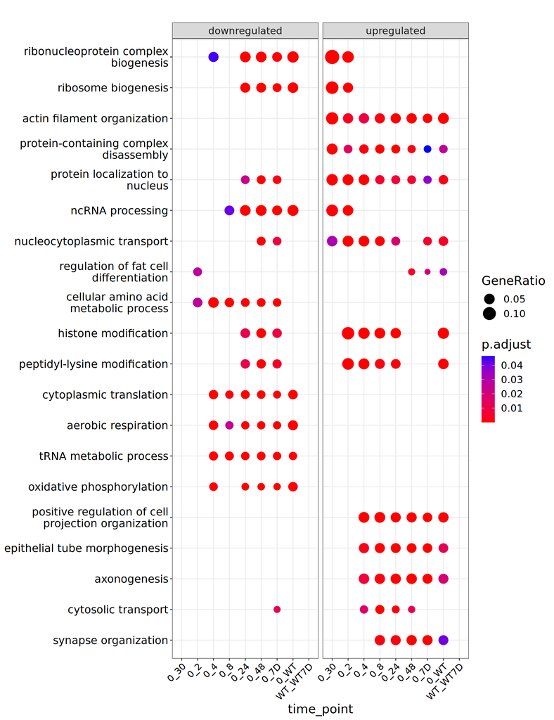

```r
fp <- all_deg %>%
  dplyr::filter(deg
                & time_point == "WT_WT7D") %>%
  dplyr::pull("gene_id")

clusters <- all_deg %>%
  dplyr::filter(deg
                & !gene_id %in% fp) %>%
  dplyr::mutate(gene_id = paste0("MGI:", gene_id)) %>%
  dplyr::ungroup()

ck_pairwise_comparisons_no_wt_wt7d <- compareCluster(gene_id ~ time_point + direction,
                     data = clusters,
                     fun = enrichGO,
                     OrgDb = 'org.Mm.eg.db',
                     keyType = "MGI",
                     ont = "BP",
                     universe = universe,
                     minGSSize = 15)

ck_pairwise_comparisons_no_wt_wt7d <- setReadable(ck_pairwise_comparisons_no_wt_wt7d, OrgDb = org.Mm.eg.db, keyType = "MGI")

p <- dotplot(ck_pairwise_comparisons_no_wt_wt7d, x = "time_point", showCategory = 2) +
  facet_grid(~direction,
             labeller = labeller(
               direction = c(`1` = "upregulated",
                             `-1` = "downregulated"
                             ))) +
  scale_x_discrete(limits = c("0_30", "0_2", "0_4",
                              "0_8", "0_24", "0_48",
                              "0_7D", "0_WT", "WT_WT7D")) +
  theme(axis.text.x = element_text(angle = 45, hjust = 1),
        text = element_text(size=16),
        axis.title = element_text(size=16),
        axis.text.y = element_text(size=14))

ggsave(filename = "figures/clusterProfiler_compare_cluster_filter_wt_deg.pdf",
       plot = p,
       height = 13,
       width = 10)

p
```

#### 30 min vs 0 h

##### Upregulated

| Time_point | Direction | Description | Generatio | Bgratio | Adjusted p-value | Geneid | Count |
| --- | --- | --- | --- | --- | --- | --- | --- |
| 0_30 | 1 | ribonucleoprotein complex biogenesis | 36/267 | 413/17957 | 2.9e-14 | Nopchap1/Lyar/Usp39/Nop16/Clns1a/Nhp2/Sart1/Strap/Nufip1/Rpl…… | 36 |
| 0_30 | 1 | ribosome biogenesis | 24/267 | 295/17957 | 2.4e-08 | Lyar/Nop16/Nhp2/Sart1/Rpl7l1/Gpatch4/Ddx18/Rrp8/Rrp15/Ddx47/Brix1/Gtpbp4/Rpf1/Utp3/Wdr43/Dis3/Wdr75/Rrn3/Aatf/Nop58/Ltv1/Pa2g4/Glul/Ncl | 24 |
| 0_30 | 1 | protein folding | 17/267 | 162/17957 | 3.3e-07 | Cct3/Cct6a/Pfdn2/Hspa4/Ppid/Dnajb11/Pdcl3/St13/Dnajc7/Ppig/Calr/Clu/Pdia3/Hspa5/Hspd1/Hspa9/Dnajc2 | 17 |
| 0_30 | 1 | RNA splicing, via transesterification reactions | 20/267 | 268/17957 | 1.9e-06 | Usp39/Larp7/Clns1a/Sf3b3/Dhx8/Sart1/Strap/Crnkl1/Srsf6/Prpf31/Prpf3/Sf3a3/Eif4a3/Rbm17/Hnrnpm/Dhx38/Khdrbs1/Ncl/Srsf2/U2af1 | 20 |
| 0_30 | 1 | RNA splicing, via transesterification reactions with bulged adenosine as nucleophile | 20/267 | 268/17957 | 1.9e-06 | Usp39/Larp7/Clns1a/Sf3b3/Dhx8/Sart1/Strap/Crnkl1/Srsf6/Prpf31/Prpf3/Sf3a3/Eif4a3/Rbm17/Hnrnpm/Dhx38/Khdrbs1/Ncl/Srsf2/U2af1 | 20 |
| 0_30 | 1 | mRNA splicing, via spliceosome | 20/267 | 268/17957 | 1.9e-06 | Usp39/Larp7/Clns1a/Sf3b3/Dhx8/Sart1/Strap/Crnkl1/Srsf6/Prpf31/Prpf3/Sf3a3/Eif4a3/Rbm17/Hnrnpm/Dhx38/Khdrbs1/Ncl/Srsf2/U2af1 | 20 |
| 0_30 | 1 | rRNA metabolic process | 19/267 | 247/17957 | 2.5e-06 | Lyar/Nhp2/Sart1/Rpl7l1/Ddx18/Rrp8/Rrp15/Ddx47/Brix1/Gtpbp4/Rpf1/Utp3/Wdr43/Dis3/Wdr75/Polr1e/Pa2g4/Ncl/Top1 | 19 |
| 0_30 | 1 | RNA splicing | 24/267 | 407/17957 | 4.1e-06 | Usp39/Larp7/Hnrnpc/Clns1a/Sf3b3/Dhx8/Sart1/Strap/Pabpc1/Crnkl1/Ddx47/Srsf6/Prpf31/Prpf3/Sf3a3/Smndc1/Eif4a3/Rbm17/Hnrnpm/Dhx38/Khdrbs1/Ncl/Srsf2/U2af1 | 24 |
| 0_30 | 1 | response to leukemia inhibitory factor | 14/267 | 139/17957 | 6.9e-06 | Tle4/Jarid2/Gclm/Ctbp2/Hk2/Spry4/Adam23/Kdm5b/Mat2a/Ext1/Ncl/Sox1/Spp1/Kdm3a | 14 |
| 0_30 | 1 | rRNA processing | 17/267 | 214/17957 | 6.9e-06 | Lyar/Nhp2/Sart1/Rpl7l1/Ddx18/Rrp8/Rrp15/Ddx47/Brix1/Gtpbp4/Rpf1/Utp3/Wdr43/Dis3/Wdr75/Pa2g4/Ncl | 17 |

[output cut: 147 more lines]

##### Downregulated

**Warning** No enriched terms.

#### 2 h vs 0 h

##### Upregulated

| Time_point | Direction | Description | Generatio | Bgratio | Adjusted p-value | Geneid | Count |
| --- | --- | --- | --- | --- | --- | --- | --- |
| 0_2 | 1 | histone modification | 79/910 | 460/17957 | 2.2e-18 | Jarid2/Mtf2/Hcfc1/Myo1c/Supt6/Nfyc/Atf2/Ctcf/Kdm6a/Kdm1a/Suz…… | 79 |
| 0_2 | 1 | peptidyl-lysine modification | 64/910 | 393/17957 | 1.7e-13 | Rela/Jarid2/Mtf2/Hcfc1/Myo1c/Supt6/Nfyc/Trim28/Atf2/Ctcf/Kdm…… | 64 |
| 0_2 | 1 | mRNA processing | 69/910 | 452/17957 | 2.2e-13 | Prpf39/Coil/Ddx5/Tra2b/Larp7/Supt6/Hnrnpc/Dhx9/Prpf4b/Cdk12/…… | 69 |
| 0_2 | 1 | regulation of mRNA metabolic process | 52/910 | 296/17957 | 3.0e-12 | Hnrnpd/Ddx5/Tra2b/Larp4b/Larp7/Supt6/Hnrnpc/Dhx9/Noct/Tbrg4/…… | 52 |
| 0_2 | 1 | RNA splicing | 62/910 | 407/17957 | 5.2e-12 | Prpf39/Coil/Ddx5/Tra2b/Larp7/Supt6/Hnrnpc/Dhx9/Prpf4b/Clk4/C…… | 62 |
| 0_2 | 1 | post-transcriptional regulation of gene expression | 68/910 | 481/17957 | 9.1e-12 | Hnrnpd/Stat3/Ddx3x/Ddx6/Ddx5/Pum3/Larp4b/Eif3b/Nsun2/Dhx9/Ri…… | 68 |
| 0_2 | 1 | ribonucleoprotein complex biogenesis | 61/910 | 413/17957 | 2.6e-11 | Ddx3x/Prpf39/Coil/Nopchap1/Dhx9/Pten/Nhp2/Ddx20/Ddx21/Dkc1/R…… | 61 |
| 0_2 | 1 | protein localization to nucleus | 50/910 | 303/17957 | 5.9e-11 | Cfl1/Stat3/Yap1/Kpna1/Kpna2/Ddx5/Mepce/Kpnb1/Larp7/Trim28/At…… | 50 |
| 0_2 | 1 | histone acetylation | 37/910 | 177/17957 | 5.9e-11 | Hcfc1/Myo1c/Nfyc/Atf2/Ctcf/Ep300/Epc2/Epc1/Sf3b3/Taf1/Ogt/Ma…… | 37 |
| 0_2 | 1 | protein acetylation | 42/910 | 227/17957 | 9.7e-11 | Ddx3x/Hcfc1/Myo1c/Nfyc/Atf2/Ctcf/Ep300/Epc2/Epc1/Sf3b3/Taf1/…… | 42 |

[output cut: 497 more lines]

##### Downregulated

| Time_point | Direction | Description | Generatio | Bgratio | Adjusted p-value | Geneid | Count |
| --- | --- | --- | --- | --- | --- | --- | --- |
| 0_2 | -1 | regulation of fat cell differentiation | 16/585 | 138/17957 | 2.7e-02 | E2f1/Vegfa/Bmp7/Cmklr1/Lrp5/Ncor2/Klf5/Trib3/Trpm4/Jdp2/Napepld/Ccdc85b/Rreb1/Akt1/Cebpb/Pim1 | 16 |
| 0_2 | -1 | cellular amino acid metabolic process | 21/585 | 238/17957 | 2.7e-02 | Sars/Mthfr/Shmt2/Slc7a7/Gldc/Mars1/Cars/Phgdh/Aldh18a1/Pycrl/Gpt2/Vars2/Nars/Kyat1/Yars/Psat1/Aars/Hpdl/Acy1/Vars/Prodh | 21 |
| 0_2 | -1 | tRNA aminoacylation for protein translation | 8/585 | 40/17957 | 2.7e-02 | Sars/Mars1/Cars/Vars2/Nars/Yars/Aars/Vars | 8 |
| 0_2 | -1 | positive regulation of fat cell differentiation | 10/585 | 64/17957 | 2.7e-02 | Bmp7/Cmklr1/Lrp5/Klf5/Trpm4/Napepld/Rreb1/Akt1/Cebpb/Pim1 | 10 |
| 0_2 | -1 | Wnt signaling pathway | 30/585 | 416/17957 | 2.7e-02 | Mitf/Mdfic/Mdfi/Fzd7/Celsr1/Nlk/Tert/Lrp5/Apc2/Celsr2/Fzd2/Ift80/Trpm4/Ptk7/Mad2l2/Fam53b/Arl6/Vangl2/Fzd10/Pias4/Kank1/Nphp4/Pbxip1/Tmem131l/Dixdc1/Dvl1/Rps12/Sox2/Sox4/Thra | 30 |
| 0_2 | -1 | cell-cell signaling by wnt | 30/585 | 417/17957 | 2.7e-02 | Mitf/Mdfic/Mdfi/Fzd7/Celsr1/Nlk/Tert/Lrp5/Apc2/Celsr2/Fzd2/Ift80/Trpm4/Ptk7/Mad2l2/Fam53b/Arl6/Vangl2/Fzd10/Pias4/Kank1/Nphp4/Pbxip1/Tmem131l/Dixdc1/Dvl1/Rps12/Sox2/Sox4/Thra | 30 |
| 0_2 | -1 | carboxylic acid transmembrane transport | 14/585 | 125/17957 | 2.7e-02 | Slc19a1/Slc1a5/Slc7a5/Slc7a7/Slc27a1/Abcd4/Slc38a2/Lrrc8d/Slc1a4/Slc38a7/Akt1/Slc7a1/Slc6a9/Slc3a2 | 14 |
| 0_2 | -1 | organic acid transmembrane transport | 14/585 | 126/17957 | 2.7e-02 | Slc19a1/Slc1a5/Slc7a5/Slc7a7/Slc27a1/Abcd4/Slc38a2/Lrrc8d/Slc1a4/Slc38a7/Akt1/Slc7a1/Slc6a9/Slc3a2 | 14 |
| 0_2 | -1 | tRNA aminoacylation | 8/585 | 43/17957 | 2.7e-02 | Sars/Mars1/Cars/Vars2/Nars/Yars/Aars/Vars | 8 |
| 0_2 | -1 | amino acid activation | 8/585 | 44/17957 | 2.8e-02 | Sars/Mars1/Cars/Vars2/Nars/Yars/Aars/Vars | 8 |

[output cut: 5 more lines]

#### 4 h vs 0 h

##### Upregulated

| Time_point | Direction | Description | Generatio | Bgratio | Adjusted p-value | Geneid | Count |
| --- | --- | --- | --- | --- | --- | --- | --- |
| 0_4 | 1 | protein localization to nucleus | 37/728 | 303/17957 | 9.1e-06 | Cfl1/Cdk5/Tsc2/Six1/Rangap1/Yap1/Kpna1/Akap1/Ddx5/Mepce/Trim…… | 37 |
| 0_4 | 1 | nucleocytoplasmic transport | 38/728 | 329/17957 | 9.1e-06 | Cfl1/Cdk5/Tsc2/Rangap1/Kpna1/Akap1/Ddx5/Supt6/Dhx9/Mlx/Trim2…… | 38 |
| 0_4 | 1 | nuclear transport | 38/728 | 329/17957 | 9.1e-06 | Cfl1/Cdk5/Tsc2/Rangap1/Kpna1/Akap1/Ddx5/Supt6/Dhx9/Mlx/Trim2…… | 38 |
| 0_4 | 1 | histone modification | 46/728 | 460/17957 | 1.7e-05 | Hcfc1/Rcor1/Myo1c/Mthfr/Supt6/Crebbp/Kdm1a/Ep300/Epc1/Men1/T…… | 46 |
| 0_4 | 1 | peptidyl-lysine modification | 41/728 | 393/17957 | 2.6e-05 | Rangap1/Rela/Hcfc1/Myo1c/Supt6/Trim28/Crebbp/Kdm1a/Ep300/Epc…… | 41 |
| 0_4 | 1 | macromolecule methylation | 36/728 | 326/17957 | 2.9e-05 | Hcfc1/Mepce/Mthfr/Supt6/Trim28/Crebbp/Kdm1a/Pik3ca/Men1/Ogt/…… | 36 |
| 0_4 | 1 | histone methylation | 24/728 | 165/17957 | 2.9e-05 | Hcfc1/Mthfr/Supt6/Crebbp/Kdm1a/Men1/Ogt/Rrp8/Setd2/Asxl2/Kansl1/Rlf/Ncoa6/Setdb1/Sirt1/Setd4/Dot1l/Zfp369/Tet2/Setd1b/Zfp335/Ctnnb1/Smad4/Kdm3a | 24 |
| 0_4 | 1 | protein methylation | 27/728 | 204/17957 | 2.9e-05 | Hcfc1/Mthfr/Supt6/Crebbp/Kdm1a/Men1/Ogt/Icmt/Rrp8/Atpsckmt/Setd2/Fam98a/Asxl2/Kansl1/Rlf/Ncoa6/Setdb1/Sirt1/Setd4/Dot1l/Zfp369/Tet2/Setd1b/Zfp335/Ctnnb1/Smad4/Kdm3a | 27 |
| 0_4 | 1 | protein alkylation | 27/728 | 204/17957 | 2.9e-05 | Hcfc1/Mthfr/Supt6/Crebbp/Kdm1a/Men1/Ogt/Icmt/Rrp8/Atpsckmt/Setd2/Fam98a/Asxl2/Kansl1/Rlf/Ncoa6/Setdb1/Sirt1/Setd4/Dot1l/Zfp369/Tet2/Setd1b/Zfp335/Ctnnb1/Smad4/Kdm3a | 27 |
| 0_4 | 1 | histone lysine methylation | 21/728 | 131/17957 | 2.9e-05 | Hcfc1/Supt6/Kdm1a/Men1/Ogt/Setd2/Asxl2/Kansl1/Rlf/Ncoa6/Setdb1/Sirt1/Setd4/Dot1l/Zfp369/Tet2/Setd1b/Zfp335/Ctnnb1/Smad4/Kdm3a | 21 |

[output cut: 346 more lines]

##### Downregulated

| Time_point | Direction | Description | Generatio | Bgratio | Adjusted p-value | Geneid | Count |
| --- | --- | --- | --- | --- | --- | --- | --- |
| 0_4 | -1 | cellular amino acid metabolic process | 38/773 | 238/17957 | 9.4e-09 | Sars/Cdo1/Tars/Nit2/Shmt2/Cth/Gldc/Mars1/Farsb/Asns/Cars/Phg…… | 38 |
| 0_4 | -1 | cytoplasmic translation | 25/773 | 142/17957 | 3.4e-06 | Rpl5/Eif4ebp1/Rps2/Rps29/Slbp/Rps5/Rpl36a/Rps3a1/Rpl21/Rps19/Eif2s3y/Rpl11/Rpl39/Rpl41/Mcts1/Rps27a/Rpl35a/Rpl23/Aars/Eef2/Eif4b/Rpl30/Rps12/Rps14/Rpl22 | 25 |
| 0_4 | -1 | tRNA aminoacylation for protein translation | 13/773 | 40/17957 | 8.3e-06 | Sars/Tars/Mars1/Farsb/Cars/Lars/Qars/Nars/Iars/Yars/Aars/Tarsl2/Gars | 13 |
| 0_4 | -1 | aerobic respiration | 26/773 | 166/17957 | 1.0e-05 | Adsl/Cox7c/Atp5k/Atp5j/Ndufv1/Shmt2/Ndufa2/Ndufs4/Atp5e/Uqcr10/Ndufb3/Stoml2/Uqcrc2/Ndufa13/Uqcrb/Ndufa5/Pdhb/Tefm/Slc25a33/Dlst/Atp5j2/Nop53/Dhtkd1/Aco2/Cyct/Idh2 | 26 |
| 0_4 | -1 | tRNA aminoacylation | 13/773 | 43/17957 | 1.3e-05 | Sars/Tars/Mars1/Farsb/Cars/Lars/Qars/Nars/Iars/Yars/Aars/Tarsl2/Gars | 13 |
| 0_4 | -1 | amino acid activation | 13/773 | 44/17957 | 1.5e-05 | Sars/Tars/Mars1/Farsb/Cars/Lars/Qars/Nars/Iars/Yars/Aars/Tarsl2/Gars | 13 |
| 0_4 | -1 | cellular respiration | 28/773 | 218/17957 | 1.3e-04 | Adsl/Cox7c/Atp5k/Atp5j/Ndufv1/Shmt2/Ndufa2/Ndufs4/Atp5e/Uqcr10/Ndufb3/Stoml2/Uqcrc2/Ndufa13/Uqcrb/Coq10b/Ndufa5/Pdhb/Tefm/Slc25a33/Pnpt1/Dlst/Atp5j2/Nop53/Dhtkd1/Aco2/Cyct/Idh2 | 28 |
| 0_4 | -1 | purine-containing compound biosynthetic process | 26/773 | 207/17957 | 4.7e-04 | Adsl/Atp5k/Atp5j/Ndufv1/Shmt2/Ndufa2/Ndufs4/Pdk4/Atp5e/Nudt2/Ndufb3/Stoml2/Ndufa13/Atp5g2/Ndufa5/Pdhb/Acss1/Atp5j2/Nme4/Acacb/Prps1l3/Acat1/Gart/Pgm2/Prps1/Spp1 | 26 |
| 0_4 | -1 | tRNA metabolic process | 23/773 | 171/17957 | 4.9e-04 | Sars/Tars/Trmt10c/Thumpd3/Mars1/Farsb/Rpp40/Cars/Lars/Polr3k/Rtraf/Qars/Exosc8/2210016F16Rik/Nars/Elp6/Trmt11/Iars/Yars/Aars/Tarsl2/Gars/Ssb | 23 |
| 0_4 | -1 | oxidative phosphorylation | 19/773 | 123/17957 | 4.9e-04 | Cox7c/Atp5k/Atp5j/Ndufv1/Shmt2/Ndufa2/Ndufs4/Atp5e/Uqcr10/Ndufb3/Stoml2/Uqcrc2/Ndufa13/Uqcrb/Ndufa5/Tefm/Slc25a33/Atp5j2/Cyct | 19 |

[output cut: 33 more lines]

#### 8 h vs 0 h

##### Upregulated

| Time_point | Direction | Description | Generatio | Bgratio | Adjusted p-value | Geneid | Count |
| --- | --- | --- | --- | --- | --- | --- | --- |
| 0_8 | 1 | positive regulation of cell projection organization | 62/1155 | 409/17957 | 9.2e-07 | Cfl1/F2rl1/Cobl/Nin/Nptn/Pafah1b1/Adam17/Serpini1/Map6/Robo1…… | 62 |
| 0_8 | 1 | cytosolic transport | 34/1155 | 159/17957 | 9.2e-07 | Ap1g1/Eps15/Washc2/Rab6b/Laptm5/Kif1a/Kif5a/Kif16b/Atg14/Dop…… | 34 |
| 0_8 | 1 | regulation of microtubule-based process | 44/1155 | 250/17957 | 1.4e-06 | Dync1h1/Hsph1/Kif3a/Rock1/Pafah1b1/Diaph1/Map6/Map1a/Map1b/D…… | 44 |
| 0_8 | 1 | cytoskeleton-dependent intracellular transport | 38/1155 | 202/17957 | 2.1e-06 | Dync1h1/Hspa8/Myo1c/Myo1e/Hif1a/Kif3a/Myo10/Myo1b/Kif1a/Pafa…… | 38 |
| 0_8 | 1 | regulation of microtubule cytoskeleton organization | 32/1155 | 155/17957 | 3.0e-06 | Dync1h1/Hsph1/Rock1/Pafah1b1/Map6/Map1a/Map1b/Dyrk1a/Hnrnpu/Gsk3b/Tpx2/Tpr/Senp6/Camsap2/Clip3/Clasp1/Prune1/Git1/Clip1/Phldb1/Cdk5rap2/Cltc/Map9/Numa1/Togaram1/Cenpj/Ska3/Apc/Mapre1/Rac1/Wnt3a/Mark2 | 32 |
| 0_8 | 1 | protein polymerization | 43/1155 | 255/17957 | 4.1e-06 | Cfl1/Cobl/Nin/Myo1c/Bin1/Diaph1/Tubgcp4/Map1b/Scin/Dyrk1a/Tm…… | 43 |
| 0_8 | 1 | positive regulation of cellular component biogenesis | 65/1155 | 486/17957 | 9.5e-06 | Cfl1/Dag1/F2rl1/Dync1h1/Cobl/Slx4/Myo1c/Rock1/Myd88/Bin1/Tes…… | 65 |
| 0_8 | 1 | dendrite development | 46/1155 | 303/17957 | 2.6e-05 | Cfl1/Cdk5/Crkl/Cobl/Kif1a/Dab1/Ywhah/Pafah1b1/Adam10/Crebbp/…… | 46 |
| 0_8 | 1 | histone modification | 61/1155 | 460/17957 | 2.8e-05 | Brca1/Pml/Jarid2/Satb1/Myo1c/Mthfr/Supt6/Ctcf/Crebbp/Kdm1a/E…… | 61 |
| 0_8 | 1 | lysosomal transport | 25/1155 | 116/17957 | 3.2e-05 | Ap1g1/Hspa8/Lyst/Laptm5/Bin1/Atg14/Ap3b1/Sort1/Ncoa4/Trak1/Gprasp1/Gcc2/Trak2/Vps11/Plekhf2/Als2/Clec16a/Pik3r4/Ehd3/Zfyve16/Vps54/Plekhm1/Hook3/Tgfbrap1/Nedd4 | 25 |

[output cut: 473 more lines]

##### Downregulated

| Time_point | Direction | Description | Generatio | Bgratio | Adjusted p-value | Geneid | Count |
| --- | --- | --- | --- | --- | --- | --- | --- |
| 0_8 | -1 | tRNA metabolic process | 32/1162 | 171/17957 | 1.5e-04 | Sars/Tars/Hsd17b10/Mettl1/Mars1/Farsb/Rpp40/Cars/Rpp30/Wdr4/…… | 32 |
| 0_8 | -1 | cellular amino acid metabolic process | 39/1162 | 238/17957 | 1.5e-04 | Sars/Cdo1/Tars/Shmt2/Hsd17b10/Cth/Gldc/Mars1/Farsb/Asns/Cars…… | 39 |
| 0_8 | -1 | tRNA aminoacylation for protein translation | 14/1162 | 40/17957 | 1.5e-04 | Sars/Tars/Mars1/Farsb/Cars/Lars/Fars2/Yars2/Nars/Yars/Aars/Tarsl2/Gars/Aars2 | 14 |
| 0_8 | -1 | tRNA aminoacylation | 14/1162 | 43/17957 | 3.1e-04 | Sars/Tars/Mars1/Farsb/Cars/Lars/Fars2/Yars2/Nars/Yars/Aars/Tarsl2/Gars/Aars2 | 14 |
| 0_8 | -1 | amino acid activation | 14/1162 | 44/17957 | 3.4e-04 | Sars/Tars/Mars1/Farsb/Cars/Lars/Fars2/Yars2/Nars/Yars/Aars/Tarsl2/Gars/Aars2 | 14 |
| 0_8 | -1 | cytoplasmic translation | 26/1162 | 142/17957 | 9.4e-04 | Rpl5/Eif4ebp1/Rps2/Rps29/Rps5/Rpl36a/Rpl21/Rps19/Zfp385a/Rps23/Rpl11/Rpl39/Rpl41/Mcts1/Rps27a/Rpl35a/Eif3d/Aars/Unk/Eif4b/Rpl18/Rpl19/Rpl30/Rps12/Rps14/Rpl22 | 26 |
| 0_8 | -1 | mitochondrial gene expression | 26/1162 | 163/17957 | 1.1e-02 | Shmt2/Mrpl41/Hsd17b10/Mrpl2/Mrpl15/Foxo3/Mrpl54/Aurkaip1/Mrps28/Fastk/Mrpl46/Mto1/Mrps9/Yars2/Mrpl47/Malsu1/Mrpl37/Mrpl19/Mrps10/Mrps14/Mrps24/Mrpl11/Mrpl34/Chchd10/Gars/Aars2 | 26 |
| 0_8 | -1 | regulation of cellular amide metabolic process | 49/1162 | 414/17957 | 1.7e-02 | Rack1/Rpl5/Eif4ebp1/Hnrnpl/Eif1/Ifngr1/Exosc5/Btg2/Ybx2/Shmt…… | 49 |
| 0_8 | -1 | regulation of cellular macromolecule biosynthetic process | 51/1162 | 441/17957 | 2.0e-02 | Rack1/Rpl5/Eif4ebp1/Hnrnpl/Eif1/Exosc5/Btg2/Ybx2/Ulk1/Shmt2/…… | 51 |
| 0_8 | -1 | post-transcriptional regulation of gene expression | 54/1162 | 481/17957 | 2.4e-02 | Rack1/E2f1/Rpl5/Vegfa/Eif4ebp1/Apobec1/Hnrnpl/Eif1/Spout1/Ex…… | 54 |

[output cut: 23 more lines]

#### 24 h vs 0 h

##### Upregulated

| Time_point | Direction | Description | Generatio | Bgratio | Adjusted p-value | Geneid | Count |
| --- | --- | --- | --- | --- | --- | --- | --- |
| 0_24 | 1 | protein-containing complex disassembly | 53/1895 | 224/17957 | 2.5e-05 | Cfl1/F2rl1/Nsf/Capzb/Sema5a/Frat1/Pik3ca/Atg14/Swap70/Map1a/…… | 53 |
| 0_24 | 1 | positive regulation of cell projection organization | 81/1895 | 409/17957 | 2.5e-05 | Cfl1/F2rl1/Ptprf/Cobl/Nin/Skil/Cdc42/Rufy3/Myo5b/Sema5a/Plxn…… | 81 |
| 0_24 | 1 | epithelial tube morphogenesis | 75/1895 | 370/17957 | 2.5e-05 | Cfl1/Slc12a2/Six1/Yap1/Pml/Cobl/Lama5/Six4/Hif1a/Sema5a/Luzp…… | 75 |
| 0_24 | 1 | histone modification | 88/1895 | 460/17957 | 2.5e-05 | Brca1/Pml/Jarid2/Satb1/Hcfc1/Supt6/Smyd5/Kmt2b/Clns1a/Crebbp…… | 88 |
| 0_24 | 1 | actin filament organization | 83/1895 | 429/17957 | 3.0e-05 | Cfl1/F2rl1/Capzb/Pls3/Pls1/Cobl/Myo5a/Cdc42/Rufy3/Myo5b/Sema…… | 83 |
| 0_24 | 1 | axonogenesis | 86/1895 | 459/17957 | 6.3e-05 | Xk/Cobl/Nin/Lama5/Skil/Rufy3/Myo5b/Sema5a/Plxna3/Smo/Nptn/En…… | 86 |
| 0_24 | 1 | cellular component disassembly | 78/1895 | 405/17957 | 6.7e-05 | Cfl1/F2rl1/Nsf/Capzb/Hif1a/Sema5a/Eif2d/Frat1/Cdc37/Tex264/A…… | 78 |
| 0_24 | 1 | neural tube development | 46/1895 | 195/17957 | 7.1e-05 | Cfl1/Cobl/Hif1a/Luzp1/Kif3a/Aldh1a2/Traf6/Smo/Enah/Fzd6/Fzd3…… | 46 |
| 0_24 | 1 | regulation of protein-containing complex disassembly | 34/1895 | 125/17957 | 7.8e-05 | Cfl1/F2rl1/Capzb/Sema5a/Pik3ca/Swap70/Map1a/Map1b/Scin/Wdr1/…… | 34 |
| 0_24 | 1 | response to leukemia inhibitory factor | 36/1895 | 139/17957 | 9.9e-05 | Mybl2/Trim25/Xrcc5/Tle4/Pml/Jarid2/Gclm/Hells/Rfx2/Enah/Vegf… | 36 |

[output cut: 531 more lines]

##### Downregulated

| Time_point | Direction | Description | Generatio | Bgratio | Adjusted p-value | Geneid | Count |
| --- | --- | --- | --- | --- | --- | --- | --- |
| 0_24 | -1 | cytoplasmic translation | 61/2228 | 142/17957 | 3.8e-16 | Rpl28/Rpl5/Eif4ebp1/Rps2/Rpsa/Rps29/Rpl6/Slbp/Nck1/Rps5/Rpl3…… | 61 |
| 0_24 | -1 | ncRNA processing | 114/2228 | 394/17957 | 1.7e-15 | Rpl5/Stat3/Npm1/Spout1/Gtf2h5/Nsun2/Nhp2/Tert/Rrp1/Thumpd3/R…… | 114 |
| 0_24 | -1 | ribonucleoprotein complex biogenesis | 117/2228 | 413/17957 | 2.4e-15 | Rpl5/Sf3a2/Rps2/Rpsa/Rpl10/Npm1/Prpf19/Gtf2h5/Rpl6/Smn1/Snrp…… | 117 |
| 0_24 | -1 | ribosome biogenesis | 91/2228 | 295/17957 | 3.6e-14 | Rpl5/Rps2/Rpsa/Rpl10/Npm1/Gtf2h5/Rpl6/Rps5/Nhp2/Mettl17/Eif2…… | 91 |
| 0_24 | -1 | rRNA metabolic process | 77/2228 | 247/17957 | 4.2e-12 | Rpl5/Npm1/Gtf2h5/Taf1b/Nhp2/Rrp1/Rps19/Rpl10a/Mars1/Rpp40/Rp…… | 77 |
| 0_24 | -1 | rRNA processing | 70/2228 | 214/17957 | 4.2e-12 | Rpl5/Npm1/Gtf2h5/Nhp2/Rrp1/Rps19/Rpl10a/Rpp40/Rpl7a/Exosc9/R…… | 70 |
| 0_24 | -1 | RNA splicing | 99/2228 | 407/17957 | 1.2e-08 | Nova2/Nova1/Snrpb2/Hnrnpa1/Srsf9/Sf3a2/Hspa8/Npm1/Prpf19/Ess…… | 99 |
| 0_24 | -1 | mRNA processing | 104/2228 | 452/17957 | 1.1e-07 | Nova2/Nova1/Snrpb2/Hnrnpa1/Srsf9/Sf3a2/Hspa8/Npm1/Prpf19/Ess…… | 104 |
| 0_24 | -1 | mitochondrial gene expression | 50/2228 | 163/17957 | 2.8e-07 | Mtg2/Mrpl50/Tfam/Coa3/Shmt2/Mrpl42/Mrpl41/Mrpl30/Mrps26/Hsd1…… | 50 |
| 0_24 | -1 | tRNA metabolic process | 51/2228 | 171/17957 | 5.0e-07 | Tars/Nsun2/Thumpd3/Hsd17b10/Mettl1/Mars1/Farsb/Rpp40/Cars/Ad…… | 51 |

[output cut: 208 more lines]

#### 48 h vs 0 h

##### Upregulated

| Time_point | Direction | Description | Generatio | Bgratio | Adjusted p-value | Geneid | Count |
| --- | --- | --- | --- | --- | --- | --- | --- |
| 0_48 | 1 | axonogenesis | 121/2506 | 459/17957 | 4.7e-09 | Isl1/Dag1/Pou3f2/Reln/Xk/Atoh1/Cobl/Nin/Lama5/Bcl11a/Skil/Ru…… | 121 |
| 0_48 | 1 | actin filament organization | 113/2506 | 429/17957 | 1.4e-08 | Capzb/Pls3/Lcp1/Pls1/Cobl/Myo5a/Cdc42/Washc2/Rufy3/Myo5b/Eph…… | 113 |
| 0_48 | 1 | dendrite development | 87/2506 | 303/17957 | 2.1e-08 | Ptprf/Reln/Crkl/Cobl/Bcl11a/Cdc42/Myo5b/Lpar1/Dab1/Ywhah/Trp…… | 87 |
| 0_48 | 1 | small GTPase mediated signal transduction | 109/2506 | 416/17957 | 2.4e-08 | Reln/Cdc42/Dock9/Arfgef3/Rock1/Lpar1/Amot/Ralbp1/Dab1/Rasgrf…… | 109 |
| 0_48 | 1 | positive regulation of cell projection organization | 107/2506 | 409/17957 | 3.2e-08 | Serpine2/Ptprf/Reln/Cobl/Nin/Bcl11a/Skil/Cdc42/Rufy3/Myo5b/S…… | 107 |
| 0_48 | 1 | cell junction assembly | 103/2506 | 394/17957 | 6.6e-08 | Six1/Epb41l5/Epb41l3/Reln/Slk/Ptprk/Crkl/Six4/Ocln/Cdc42/Cdh…… | 103 |
| 0_48 | 1 | cell-substrate adhesion | 93/2506 | 347/17957 | 1.1e-07 | Dag1/Epb41l5/Slk/Ptprk/Crkl/Cdkn2a/Itga9/Adam9/Lama5/Cdc42/E…… | 93 |
| 0_48 | 1 | regulation of GTPase activity | 88/2506 | 324/17957 | 1.5e-07 | Crkl/Evi5/Akt2/Dock9/Epha1/Plxna3/Plxna2/Abr/Pip5k1a/Bin1/Rg…… | 88 |
| 0_48 | 1 | positive regulation of hydrolase activity | 116/2506 | 474/17957 | 2.4e-07 | Stat1/Pml/Crkl/Evi5/Cdkn2a/Akt2/Slc1a1/Dock9/Epha1/Abr/Rock1…… | 116 |
| 0_48 | 1 | regulation of cell-substrate adhesion | 64/2506 | 213/17957 | 4.3e-07 | Dag1/Epb41l5/Slk/Crkl/Cdkn2a/Cdc42/Epha1/Rock1/Bcar1/St6gal1…… | 64 |

[output cut: 751 more lines]

##### Downregulated

| Time_point | Direction | Description | Generatio | Bgratio | Adjusted p-value | Geneid | Count |
| --- | --- | --- | --- | --- | --- | --- | --- |
| 0_48 | -1 | ncRNA processing | 160/3015 | 394/17957 | 3.7e-26 | Rpl5/Stat3/Hnrnpa2b1/Npm1/Spout1/Imp4/Nsun2/Exosc5/Nhp2/Trmt…… | 160 |
| 0_48 | -1 | ribonucleoprotein complex biogenesis | 156/3015 | 413/17957 | 9.9e-22 | Sfswap/Rpl5/Nup88/Sf3a2/Rps2/Rpsa/Rpl10/Npm1/Prpf19/Imp4/Exo…… | 156 |
| 0_48 | -1 | ribosome biogenesis | 117/3015 | 295/17957 | 6.4e-18 | Rpl5/Nup88/Rps2/Rpsa/Rpl10/Npm1/Imp4/Exosc5/Rpl6/Rps5/Nhp2/M…… | 117 |
| 0_48 | -1 | cytoplasmic translation | 71/3015 | 142/17957 | 7.4e-17 | Rpl28/Rpl5/Eif4ebp1/Rps2/Rpsa/Rps29/Rpl6/Dhx9/Slbp/Nck1/Rps5…… | 71 |
| 0_48 | -1 | mRNA processing | 151/3015 | 452/17957 | 2.0e-15 | Sfswap/Nelfe/Nova2/Nova1/Snrpb2/Hnrnpa2b1/Hnrnpa1/Srsf9/Sf3a…… | 151 |
| 0_48 | -1 | RNA splicing | 139/3015 | 407/17957 | 4.7e-15 | Sfswap/Nova2/Nova1/Snrpb2/Hnrnpa2b1/Hnrnpa1/Srsf9/Sf3a2/Hspa…… | 139 |
| 0_48 | -1 | rRNA processing | 88/3015 | 214/17957 | 1.5e-14 | Rpl5/Npm1/Imp4/Exosc5/Nhp2/Rrp1/Krr1/Sart1/Rps19/Rpl10a/Rpp4…… | 88 |
| 0_48 | -1 | double-strand break repair | 107/3015 | 288/17957 | 3.1e-14 | Lig1/Mcm3/Mlh1/Recql/Uimc1/Mcm4/Prpf19/Atr/Morf4l1/Rad51b/Mr…… | 107 |
| 0_48 | -1 | rRNA metabolic process | 96/3015 | 247/17957 | 3.5e-14 | Rpl5/Npm1/Imp4/Exosc5/Nhp2/Rrp1/Krr1/Sart1/Smarcb1/Rps19/Rpl…… | 96 |
| 0_48 | -1 | tRNA metabolic process | 75/3015 | 171/17957 | 3.5e-14 | Tars/Nsun2/Trmt10c/Thumpd3/Hsd17b10/Mettl1/Mars1/Farsb/Rpp40…… | 75 |

[output cut: 396 more lines]

#### 7 days vs 0 h

##### Upregulated

| Time_point | Direction | Description | Generatio | Bgratio | Adjusted p-value | Geneid | Count |
| --- | --- | --- | --- | --- | --- | --- | --- |
| 0_7D | 1 | synapse organization | 161/3768 | 464/17957 | 1.6e-08 | Cfl1/Dag1/Ptprf/Six1/Reln/Crkl/Ncan/Nrcam/Il1rap/Slc1a1/Ube3…… | 161 |
| 0_7D | 1 | epithelial tube morphogenesis | 132/3768 | 370/17957 | 8.4e-08 | Cfl1/Dag1/Mmp14/Slc12a2/Nfatc1/Six1/Vdr/Yap1/Cxcl12/Hand1/Ha…… | 132 |
| 0_7D | 1 | angiogenesis | 161/3768 | 483/17957 | 1.8e-07 | Isl1/Slc12a2/Tbx4/Ptprm/Stat1/Cxcl12/Hand1/Hand2/Dll1/Rora/F…… | 161 |
| 0_7D | 1 | axonogenesis | 153/3768 | 459/17957 | 4.0e-07 | Isl1/Dag1/Pou3f2/Ptprm/Reln/Cxcl12/Xk/Atoh1/Nrcam/Nin/Lama5/…… | 153 |
| 0_7D | 1 | cell junction assembly | 134/3768 | 394/17957 | 9.2e-07 | Cfl1/Mmp14/Six1/Epb41l5/Epb41l3/Reln/Crkl/Il1rap/St8sia2/Six…… | 134 |
| 0_7D | 1 | cell-substrate adhesion | 121/3768 | 347/17957 | 9.2e-07 | Cfl1/Dag1/Mmp14/Itga7/Epb41l5/Crkl/Cdkn2a/Itga9/Adam9/Lama5/…… | 121 |
| 0_7D | 1 | regulation of developmental growth | 126/3768 | 372/17957 | 2.8e-06 | Cfl1/Pou3f2/Six1/Spr/Yap1/Cxcl12/Dll1/Fgf9/Pls1/Jarid2/Syt17…… | 126 |
| 0_7D | 1 | organ growth | 75/3768 | 191/17957 | 3.5e-06 | Yap1/Dll1/Fgf9/Adra1a/Jarid2/Lepr/Ube3a/Smo/Smad1/Pten/Arx/R…… | 75 |
| 0_7D | 1 | small GTPase mediated signal transduction | 137/3768 | 416/17957 | 3.6e-06 | Reln/Eps8/Adra1a/Cdc42/Dock9/Arfgef3/Plcd4/Rgl1/Ralgds/Rock1…… | 137 |
| 0_7D | 1 | regulation of cell-substrate adhesion | 81/3768 | 213/17957 | 4.0e-06 | Cfl1/Dag1/Mmp14/Epb41l5/Crkl/Cdkn2a/Cdc42/Epha1/Gpm6b/Has2/C…… | 81 |

[output cut: 719 more lines]

##### Downregulated

| Time_point | Direction | Description | Generatio | Bgratio | Adjusted p-value | Geneid | Count |
| --- | --- | --- | --- | --- | --- | --- | --- |
| 0_7D | -1 | tRNA metabolic process | 81/3669 | 171/17957 | 1.1e-11 | Sars/Wars1/Tars/Rtcb/Trdmt1/Thumpd3/Trpt1/Hsd17b10/Mettl1/Ma…… | 81 |
| 0_7D | -1 | cytoplasmic translation | 70/3669 | 142/17957 | 3.4e-11 | Rpl28/Rpl5/Eif4ebp1/Rps2/Rpsa/Rpl6/Dhx9/Slbp/Nck1/Rps5/Rpl36…… | 70 |
| 0_7D | -1 | chromosome segregation | 136/3669 | 364/17957 | 7.0e-11 | Mlh1/Ube2b/Cit/Nudc/Mki67/Smc2/Ube2i/Kpnb1/Dctn2/Rad21/Kif4/…… | 136 |
| 0_7D | -1 | ncRNA processing | 143/3669 | 394/17957 | 1.2e-10 | Rpl5/Stat3/Hnrnpa2b1/Ddx5/Npm1/Rtcb/Spout1/Exosc5/Ints9/Nhp2…… | 143 |
| 0_7D | -1 | double-strand break repair | 113/3669 | 288/17957 | 1.2e-10 | Lig1/Mcm3/Mlh1/H2ax/Recql/Uimc1/Mcm4/Apbb1/Rad21/Atr/Eya1/Ra…… | 113 |
| 0_7D | -1 | aerobic respiration | 76/3669 | 166/17957 | 1.2e-10 | Cox7c/Atp5o/Atp5k/Coq7/Dld/Atp5j/Atp5b/Ndufv1/Ndufs6/Bnip3/T…… | 76 |
| 0_7D | -1 | proton motive force-driven mitochondrial ATP synthesis | 37/3669 | 56/17957 | 1.2e-10 | Atp5o/Atp5k/Atp5j/Atp5b/Ndufv1/Ndufs6/Atp5pb/Atp5c1/Ndufa2/N…… | 37 |
| 0_7D | -1 | proton motive force-driven ATP synthesis | 39/3669 | 61/17957 | 1.2e-10 | Atp5o/Atp5k/Atp5g1/Atp5j/Atp5b/Ndufv1/Ndufs6/Atp5pb/Atp5c1/N…… | 39 |
| 0_7D | -1 | mitotic nuclear division | 116/3669 | 301/17957 | 1.5e-10 | Bmp7/Cit/Nudc/Mki67/Smc2/Kpnb1/Kif3b/Dctn2/Rad21/Kif22/Nek2/…… | 116 |
| 0_7D | -1 | RNA splicing | 145/3669 | 407/17957 | 2.4e-10 | Sfswap/Nova2/Nova1/Snrpb2/Hnrnpa2b1/Hnrnpa1/Fxr1/Sf3a2/Ddx5/…… | 145 |

[output cut: 350 more lines]

#### 0 h vs WT 0 h

##### Upregulated

| Time_point | Direction | Description | Generatio | Bgratio | Adjusted p-value | Geneid | Count |
| --- | --- | --- | --- | --- | --- | --- | --- |
| 0_WT | 1 | histone modification | 69/1116 | 460/17957 | 3.3e-08 | Vegfa/Jarid2/Hcfc1/Nap1l2/Kmt2b/Crebbp/Rbbp7/Kdm1a/Ep300/Ep4…… | 69 |
| 0_WT | 1 | actin filament organization | 62/1116 | 429/17957 | 9.3e-07 | Arhgef2/Myo7a/Eps8/Cobl/Was/Myo5a/Rufy3/Srf/Dlg1/Sema5a/Myo1…… | 62 |
| 0_WT | 1 | cell-substrate adhesion | 53/1116 | 347/17957 | 1.6e-06 | Vegfa/Tiam1/Ptprk/Adam9/Lama5/Srf/Rock1/Pip5k1a/Gcnt2/Nid2/A…… | 53 |
| 0_WT | 1 | peptidyl-lysine modification | 55/1116 | 393/17957 | 1.5e-05 | Rangap1/Jarid2/Hcfc1/Nap1l2/Trim28/Kmt2b/Crebbp/Kdm1a/Ep300/…… | 55 |
| 0_WT | 1 | regulation of histone modification | 34/1116 | 192/17957 | 2.5e-05 | Vegfa/Jarid2/Hcfc1/Nap1l2/Kmt2b/Kdm1a/Nsd1/Trip12/Ogt/Ncor1/Baz1b/Sart3/Brd4/Ubr5/Bcor/Auts2/Setd5/Setd7/Atg7/Asxl2/Ehmt1/Piwil2/Rps6ka4/Noc2l/Jdp2/Nsd3/Tada2a/Zfp369/Kat7/Lcor/Kdm4a/Lmna/Nos1/Arrb1 | 34 |
| 0_WT | 1 | chromatin remodeling | 46/1116 | 314/17957 | 3.8e-05 | Jarid2/Hcfc1/Nap1l2/Trim28/Kmt2b/Rbbp7/Kdm1a/Ep300/Phf2/Pak1…… | 46 |
| 0_WT | 1 | actin filament bundle assembly | 30/1116 | 162/17957 | 4.1e-05 | Eps8/Was/Srf/Myo1b/Evl/Pak1/Pak2/Dpysl3/Dlc1/Espn/Actn4/Spire1/Carmil1/Clasp2/Limch1/Ccdc88a/Alms1/Pawr/Fermt2/Coro2b/Arhgef15/Actg1/Braf/Cald1/Flna/Itgb5/Marcks/Nf2/Tjp1/Arrb1 | 30 |
| 0_WT | 1 | actin filament bundle organization | 30/1116 | 165/17957 | 5.5e-05 | Eps8/Was/Srf/Myo1b/Evl/Pak1/Pak2/Dpysl3/Dlc1/Espn/Actn4/Spire1/Carmil1/Clasp2/Limch1/Ccdc88a/Alms1/Pawr/Fermt2/Coro2b/Arhgef15/Actg1/Braf/Cald1/Flna/Itgb5/Marcks/Nf2/Tjp1/Arrb1 | 30 |
| 0_WT | 1 | histone lysine methylation | 26/1116 | 131/17957 | 5.7e-05 | Jarid2/Hcfc1/Kmt2b/Kdm1a/Nsd1/Ogt/Brd4/Kmt5a/Setd2/Bcor/Auts2/Setd5/Setd7/Asxl2/Ehmt1/Setbp1/Nsd3/Dot1l/Zfp369/Tet2/Lcor/Kdm4a/Setd1b/Kmt2d/Chd5/Lmna | 26 |
| 0_WT | 1 | positive regulation of protein localization | 58/1116 | 455/17957 | 6.7e-05 | Pcnt/Epb41l2/Vegfa/Yap1/Mgat3/Akt2/Adam9/Hcfc1/Myo5a/Rufy3/H…… | 58 |

[output cut: 418 more lines]

##### Downregulated

| Time_point | Direction | Description | Generatio | Bgratio | Adjusted p-value | Geneid | Count |
| --- | --- | --- | --- | --- | --- | --- | --- |
| 0_WT | -1 | aerobic respiration | 59/1443 | 166/17957 | 4.0e-20 | Cox7c/Atp5o/Atp5k/Coq7/Dld/Atp5j/Ndufv1/Ndufs6/Bnip3/Atp5pb/…… | 59 |
| 0_WT | -1 | oxidative phosphorylation | 50/1443 | 123/17957 | 4.8e-20 | Cox7c/Atp5o/Atp5k/Coq7/Dld/Atp5j/Ndufv1/Ndufs6/Atp5pb/Ndufa2…… | 50 |
| 0_WT | -1 | proton motive force-driven ATP synthesis | 35/1443 | 61/17957 | 7.3e-20 | Atp5o/Atp5k/Atp5g1/Atp5j/Ndufv1/Ndufs6/Atp5pb/Ndufa2/Ndufs4/…… | 35 |
| 0_WT | -1 | proton motive force-driven mitochondrial ATP synthesis | 33/1443 | 56/17957 | 2.9e-19 | Atp5o/Atp5k/Atp5j/Ndufv1/Ndufs6/Atp5pb/Ndufa2/Ndufs4/Atp5e/N…… | 33 |
| 0_WT | -1 | cytoplasmic translation | 50/1443 | 142/17957 | 3.4e-17 | Rpl5/Rpsa/Rps29/Rpl6/Eif2d/Nck1/Rps5/Rpl36a/Rps3a1/Rpl21/Rpl…… | 50 |
| 0_WT | -1 | ribonucleoprotein complex biogenesis | 91/1443 | 413/17957 | 2.1e-16 | Rpl5/Sf3a2/Rpsa/Rpl10/Prpf19/Gtf2h5/Nop16/Exosc5/Rpl6/Smn1/E…… | 91 |
| 0_WT | -1 | cellular respiration | 62/1443 | 218/17957 | 2.1e-16 | Cox7c/Atp5o/Atp5k/Coq7/Dld/Atp5j/Ndufv1/Ndufs6/Bnip3/Atp5pb/…… | 62 |
| 0_WT | -1 | mitochondrial gene expression | 52/1443 | 163/17957 | 5.6e-16 | Mtg2/Mrpl50/Tfam/Mrpl49/Coa3/C1qbp/Trmt10c/Mrpl40/Mrpl42/Mrp…… | 52 |
| 0_WT | -1 | mitochondrial translation | 45/1443 | 130/17957 | 3.1e-15 | Mtg2/Mrpl50/Mrpl49/Coa3/C1qbp/Trmt10c/Mrpl40/Mrpl42/Mrpl22/M…… | 45 |
| 0_WT | -1 | nucleoside triphosphate biosynthetic process | 43/1443 | 120/17957 | 3.4e-15 | Stat3/Atp5o/Atp5k/Atp5g1/Atp5j/Ndufv1/Ndufs6/Dtymk/Atp5pb/Nd…… | 43 |

[output cut: 156 more lines]

# Transposable Elements

We will import gene expression quantification as computed using the STARTE-random methodology (Teissandier et al. (2019)). In brief, we perform standard trimming with Trimmomatic, mapping with STAR using a set of parameters permissive for multimapping reads, and FeatureCounts to quantify expression of each TE family.

```r
get_results_table <- function(file_path){
  tp <- basename(dirname(dirname(file_path)))

  read_csv(file_path) %>%
    dplyr::select(-1) %>%
    dplyr::mutate(time_point = tp)
}

mapping_table <- read_delim("3t-seq/data/references/rmsk/mm10.gtf",
                            col_names = FALSE) %>%
  dplyr::select(X9) %>%
  dplyr::mutate(
    repName = sub(
      "^repName=(.+);repClass=.+;repFamily=.+;repStart=.+;repEnd=.+;repLeft=.+$",
      "\\1",
      X9
    ),
    repClass = sub(
      "^repName=.+;repClass=(.+);repFamily=.+;repStart=.+;repEnd=.+;repLeft=.+$",
      "\\1",
      X9
    ),
    repFamily = sub(
      "^repName=.+;repClass=.+;repFamily=(.+);repStart=.+;repEnd=.+;repLeft=.+$",
      "\\1",
      X9
    )
  ) %>%
  dplyr::select(-X9) %>%
  dplyr::distinct()

lfc_table <- list.files("3t-seq/data/results/alignments/starTE",
           pattern = "lfc.txt",
           full.names = TRUE,
           recursive = TRUE) %>%
  purrr::map(get_results_table) %>%
  purrr::reduce(bind_rows) %>%
  dplyr::left_join(
    mapping_table,
    by = c("gene_name" = "repName"),
    multiple="all"
    )
```

## TE from Dura et al. (2022)

We will pick TE as shown in [Figure 1F](https://www.nature.com/articles/s41588-022-01040-z/figures/1) of Dura et al. (2022).

Unfortunately, not all displayed TE could be detected in this dataset. The list below shows the missing genes.

```r
line1 <- c("L1MdA_I", "L1MdA_II", "L1MdA_III", "L1MdA_IV",
           "L1MdA_V", "L1MdA_VI", "L1MdA_VII", "L1MdTf_I",
           "L1MdTf_II", "L1MdTf_III", "L1MdF_II", "L1MdGf_I",
           "L1MdGf_II")

sine <- c("B2_Mm1a", "B1_Mm")

erv1 <- c("MURVY-int", "MMERGLN-int", "MMERGLN_LTR")

ervk <- c("MMERVK10C-int", "IAPEz_int", "IAPEy-int", "IAPd-int",
          "ETnERV2-int", "ETnERV3-int", "RLTR10-int")

ervl <- c("ORR1A1-int", "ORR1A0-int", "ORR1A0", "MERVL-int")

selected <- c(line1, sine, erv1, ervk, ervl)

setdiff(selected, lfc_table$gene_name)
```

```
##  [1] "L1MdA_I"    "L1MdA_II"   "L1MdA_III"  "L1MdA_IV"   "L1MdA_V"
##  [6] "L1MdA_VI"   "L1MdA_VII"  "L1MdTf_I"   "L1MdTf_II"  "L1MdTf_III"
## [11] "L1MdF_II"   "L1MdGf_I"   "L1MdGf_II"  "IAPEz_int"  "IAPd-int"
```

We will first produce a heatmap similar to the Figure from the paper above.

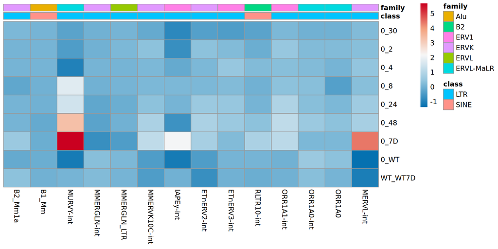

```r
as_matrix <- function(df) {
  rn <- df$gene_name
  mat <- as.matrix(df[,-1])
  rownames(mat) <- rn
  return(mat)
}

mat <- lfc_table %>%
  dplyr::filter(gene_name %in% selected) %>%
  pivot_wider(names_from = time_point,
              values_from = log2FoldChange,
              id_cols = gene_name) %>%
  as_matrix()

available_te <- intersect(selected, rownames(mat))

mat <- mat[available_te, c("0_30", "0_2", "0_4",
                           "0_8", "0_24", "0_48",
                           "0_7D", "0_WT", "WT_WT7D")]

rowann <- data.frame(
  row.names = available_te,
  class = mapping_table %>%
    dplyr::filter(repName %in% available_te) %>%
    dplyr::pull("repClass"),
  family = mapping_table %>%
    dplyr::filter(repName %in% available_te) %>%
    dplyr::pull("repFamily")
)

pheatmap(t(mat),
         color = colorRampPalette(
           rev(brewer.pal(n = 5, name = "RdBu")))(100),
         cluster_rows = FALSE,
         cluster_cols = FALSE,
         annotation_col = rowann)
```

We will also produce a line plot showing the same data.

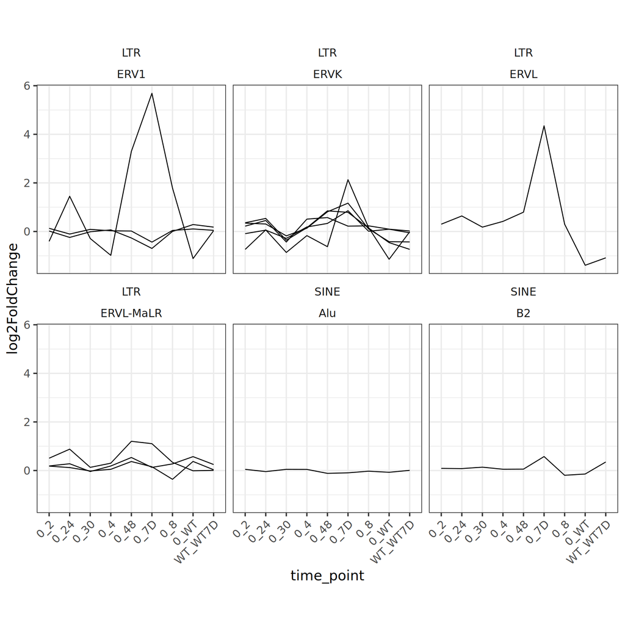

```r
p <- lfc_table %>%
  dplyr::filter(gene_name %in% selected) %>%
  ggplot2::ggplot(aes(time_point, log2FoldChange, group = gene_name)) +
  geom_line() +
  facet_wrap( ~ repClass + repFamily) +
  theme_bw(base_size = 16) +
  theme(aspect.ratio = 1,
        strip.background = element_blank(),
        axis.text.x = element_text(angle = 45, hjust = 1))

ggsave(filename = "figures/te_lines_dura2022.pdf",
       plot = p,
       width = 10,
       height = 10)

p
```

## All differentially expressed TE

We will produce similar visualizations using differentially expressed TE from DESeq2 analysis as performed by the 3t-seq pipeline.

Fist we will call DE TE using thresholds defined above.

```r
te_de <- lfc_table %>%
  dplyr::mutate(deg = log2FoldChange > lfc_thr
               & ifelse(is.na(padj), pvalue < pval_thr, padj < pval_thr))
```

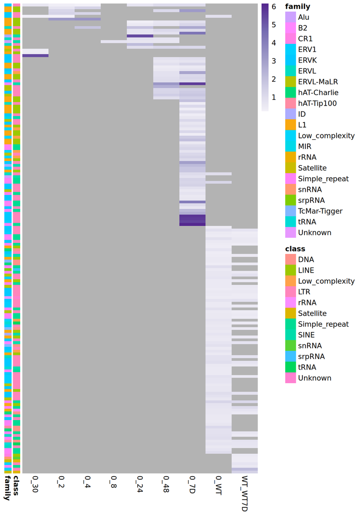

```r
mat <- te_de  %>%
  dplyr::filter(deg & gene_name != "Eulor5A") %>%
  tidyr::pivot_wider(
    id_cols = gene_name,
    values_from = log2FoldChange,
    names_from = time_point,
    values_fill = NA) %>%
  as_matrix

rowann <- data.frame(
  row.names = rownames(mat),
  class = mapping_table %>%
    dplyr::filter(repName %in% rownames(mat)) %>%
    dplyr::pull("repClass"),
  family = mapping_table %>%
    dplyr::filter(repName %in% rownames(mat)) %>%
    dplyr::pull("repFamily")
)

mat <- mat[, c("0_30", "0_2", "0_4",
               "0_8", "0_24", "0_48",
               "0_7D", "0_WT", "WT_WT7D")]

pheatmap(mat,
         color = colorRampPalette(
           brewer.pal(n = 5, name = "Purples"))(100),
         na_col = "grey70",
         cluster_rows = FALSE,
         cluster_cols = FALSE,
         annotation_row = rowann,
         show_rownames = FALSE)
```

It looks like pairwise calls for differentially expressed TE result in sparse data. Temporal clustering will do better?

# References

Dura, Mathilde, Aurélie Teissandier, Mélanie Armand, Joan Barau, Clémentine Lapoujade, Pierre Fouchet, Lorraine Bonneville, et al. 2022. “DNMT3A-Dependent DNA Methylation Is Required for Spermatogonial Stem Cells to Commit to Spermatogenesis.” *Nature Genetics* 54 (4): 469–80. https://doi.org/10.1038/s41588-022-01040-z.

Teissandier, Aurélie, Nicolas Servant, Emmanuel Barillot, and Deborah Bourc’his. 2019. “Tools and Best Practices for Retrotransposon Analysis Using High-Throughput Sequencing Data.” *Mobile DNA* 10 (1): 52. https://doi.org/10.1186/s13100-019-0192-1.